# Coral population density analysis

R. Cunning

2026-11-06

This document contains the main coral analysis using the joint `brms` model. It rebuilds the same original adult/juvenile observations and the added 2024 Broward–Miami DRM observations directly from raw inputs. Only surveyed responses enter the likelihood. PEV remains the 1,200 m north/south channel-edge band.

The count family, searched-area offset, taxon × class × habitat structure and shared survey effects follow the original PEV framework. Regional count coefficients are specific to each taxon/class/habitat cell. Zero inflation and shape retain their taxon × class × habitat predictors. The `regional_distributional_effects` parameter controls whether they additionally allow regional departures; this run uses **shared zero inflation and shape across regions**. Direction variation has a separate SD in each region. Ordinary `brms` centering uses the combined dataset. This is a new fit, not a claim of exact equivalence to the cached Stan pilot. This run uses **revised priors**. The revised candidate keeps the count priors and uses zero-centered zi/shape coefficients with an explicit Normal(−1, 1.5) prior for the centered log-shape intercept.

**Every manuscript density prediction explicitly selects PEV.** Broward–Miami predictions are used for regional comparisons and model checks. Prediction averaging and 2024 targets are separate from fitting-time centering. The primary regional comparison gives NRC, IR, MR and OR equal weight (1/4) in both regions. Overall PEV density summaries and temporal trends use the same equal habitat weights. These are habitat-standardized estimates rather than mean densities across each region’s actual habitat areas. Own-area weighting is retained as a separately labeled sensitivity comparison. Habitat-specific PEV figures and abundance extrapolations retain their existing definitions. Survey/source averaging remains a separate step.

This run uses 4 chains with 1000 warmup and 1000 sampling iterations each, with 5 threads per chain. Sampling diagnostics below determine whether it is ready for manuscript inference. The report, coral-only outputs and cached fit stay in outputs/coral_analysis. The manuscript coral figures and appendix tables are also published to `outputs/`. Run `analysis/integrated_figures_tables.Rmd` afterward to produce the combined coral–conch Fig 1, Table 1 and Table 2 in that directory. The original PEV analysis is preserved as `coral_analysis_original.Rmd` under `old_working_files/coral_analysis_original_2026-11-03/analysis/`. Shared source inputs and the archived original remain protected. Earlier model experiments are archived separately and are not runtime dependencies.

The first sections import all original surveys and the broader DRM observations, then apply a pooled taxon cutoff (>5 colonies), coverage-aware zero completion and shared habitat filtering. Original sites retain the local habitat layer; additional DRM sites use the regional layer, with PTCH excluded. Table 1 and the compilation totals describe the full dataset. Local survey-location panels retain the original cohort, and manuscript source-averaging grids retain their original availability conventions. The raw-versus-modeled density check uses only observations classified as PEV.

# 1 Setup

```r
# Load packages
library(MASS)   # for fitdistr
library(stats)  # for qlogis
library(sf)
library(xml2)
library(vegan)
library(kableExtra)
library(treemapify)
library(ggrepel)
library(igraph)
library(cowplot)
library(tidyverse)
library(tidybayes)
library(ggtext)
library(patchwork)
library(moments)
library(colorspace)
library(posterior)
library(digest)
library(jsonlite)
library(brms)
```

```r
# Define genus level taxon groups (plus one family FAVI)
taxon_groups <- list(
  PORI = c("PPOR", "PFUR", "PDIV", "PAST", "PORI"),
  ORBI = c("OFAV", "OANN", "OFRA", "ORBI"),
  AGAR = c("AFRA", "AAGA", "AHUM", "ALAM", "AGAR"),
  MADR = c("MAUR", "MSEN", "MDEC", "MPHA", "MADR"),
  SOLE = c("SHYA", "SBOU", "SOLE"),
  SCOL = c("SLAC", "SCUB", "SCOL"),
  SIDE = c("SSID", "SRAD", "SIDE"),
  MYCE = c("MFER", "MLAM", "MALI", "MYCE"),
  OCUL = c("OROB", "ODIF", "OCUL")
)
# Convert to lookup tibble
taxon_lookup <- enframe(taxon_groups, name = "taxon_group", value = "taxon") %>%
  unnest(taxon)


# Define juvenile family level taxon groups (following DRM survey convention)
taxon_groups_juv <- list(
  MUSS = c("ISIN", "ISOP", "MANG", "MYCE", "SCOL", "MUSS", "MALI", "MFER"),
  FAVI = c("FAVI", "FFRA", "MARE", "DLAB", "PSTR", "PCLI", "CNAT"),
  MEAN = c("MMEA", "MEAN", "DCYL", "DSTO", "EFAS")
)
taxon_group_df <- bind_rows(lapply(names(taxon_groups_juv), function(group) {
  tibble(taxon = taxon_groups_juv[[group]], group = group)
}))
taxon_group_df <- taxon_group_df %>% filter(taxon != group)
# Convert to lookup tibble
taxon_lookup_juv <- enframe(taxon_groups_juv, name = "taxon_group", value = "taxon") %>%
  unnest(taxon)


# Create taxon labels
taxon_labels <- c(
  ACER = 'italic("A. cervicornis")',
  AGAR = 'italic("Agaricia")~spp.',
  CNAT = 'italic("C. natans")',
  DLAB = 'italic("D. labyrinthiformis")',
  DSTO = 'italic("D. stokesii")',
  EFAS = 'italic("E. fastigiata")',
  FAVI = '"Faviinae"',
  MADR = 'italic("Madracis")~spp.',
  MCAV = 'italic("M. cavernosa")',
  MEAN = '"Meandrinidae"',
  MMEA = 'italic("M. meandrites")',
  MUSS = '"Mussinae"',
  MYCE = 'italic("Mycetophyllia")~spp.',
  ORBI = 'italic("Orbicella")~spp.',
  PCLI = 'italic("P. clivosa")',
  PORI = 'italic("Porites")~spp.',
  PSTR = 'italic("P. strigosa")',
  SIDE = 'italic("Siderastrea")~spp.',
  SINT = 'italic("S. intersepta")',
  SOLE = 'italic("Solenastrea")~spp.',
   All = '"All taxa"'
)


# Define SCTLD susceptibility groups (following Papke et al. 2024)
group_definitions <- tibble(
  taxon = names(taxon_labels),
  sus_group = case_when(
    taxon %in% c("FAVI", "MUSS", "MEAN", "DSTO", "EFAS", "MMEA", "DLAB", "CNAT", "PSTR", "PCLI") ~ "high_sus",
    taxon %in% c("MCAV", "ORBI", "SIDE", "SINT", "SOLE") ~ "mod_sus",
    taxon %in% c("ACER", "PORI", "AGAR", "MYCE", "MADR") ~ "low_sus",
    TRUE ~ NA_character_
  )
) %>%
  mutate(sus_group = factor(sus_group, levels = c("low_sus", "mod_sus", "high_sus")))


# Order levels of Habitat Types
type_levels <- c("Nearshore Ridge Complex", "Inner Reef", "Middle Reef",
                 "Outer Reef")
type_labels <- c("NRC", "IR", "MR", "OR")
names(type_labels) <- type_levels
type_labels2 <- c("Nearshore\nRidge Complex", "Inner\nReef", "Middle\nReef", "Outer\nReef")


# Order survey datasets
dataset_levels <- c("nsu11_esa", "dca17_esa", "dca17", "tt21", "tt23", "drm24")
dataset_labels <- c("2011 / NSU ESA", "2017 / DCA ESA", "2017 / DCA Recon", "2021 / Tetra Tech", "2023 / Tetra Tech", "2024 / Shedd")
names(dataset_labels) <- dataset_levels
```

# 2 Import data

## 2.1 Coral survey data

### 2.1.1 2011 NSU ESA Survey

```r
# Import data
nsu11_esa0 <- readxl::read_xlsx("data/2011_nsu_esa/Port Everglades_NSU 2011and DCA 2017_ESA surveys.xlsx",
                           sheet = "2011_NSU_ESA survey") %>%
  janitor::clean_names()


# Site metadata
nsu11_esa_sitemd <- nsu11_esa0 %>%
  select(site = ident, latitude = lat, longitude = long) %>%
  mutate(site = as.character(site))



# ESA coral count data
## DO NOT KEEP M.FEROX DATA -- ALL OTHER SURVEYS ALL MYCETOPHYLLIA ARE ALICIAE, so cannot combine at 'MYCE' (genus) level
nsu11_esa_counts <- nsu11_esa0 %>%
  select(site = ident,
         ACER = a_cervic_1, OANN = m_annula_1, OFAV = m_faveol_1, OFRA = m_franks_1, DSTO = d_stokes_1) %>%
  pivot_longer(-site, names_to = "taxon", values_to = "n") %>%
  # Assume all were >4cm since no sizes are reported
  mutate(class = ">4cm") %>%
  mutate(site = as.character(site))

# Aggregate taxa (multiple orbicella observed --> ORBI)
nsu11_esa_counts_ag <- nsu11_esa_counts %>%
  left_join(taxon_lookup, by = "taxon") %>%
  mutate(taxon = coalesce(taxon_group, taxon)) %>%
  select(-taxon_group) %>%
  group_by(across(-n)) %>%
  summarize(n = sum(n), .groups = "drop") %>%
  mutate(tier = "t1")
```

### 2.1.2 2017 DCA ESA Survey

```r
# Site metadata
dca17_esa_sitemd0 <- readxl::read_xlsx("data/2017_dca_esa/Port Everglades_NSU 2011and DCA 2017_ESA surveys.xlsx",
                                       sheet = "2017_DCA_ESA survey") %>% janitor::clean_names()

dca17_esa_sitemd <- dca17_esa_sitemd0 %>%
  select(site = id, longitude, latitude) %>%
  mutate(site = as.character(site))


# Coral data
# Appendix D -- contains individual colony sizes for observed corals
dca17_esa0 <- readxl::read_xlsx("data/2017_dca_esa/Appendix D_ESA_listed_coral_Plotted_Locations.xlsx") %>%
  janitor::clean_names() %>%
  select(site = site_id, taxon = species, length_cm, width_cm, height_cm, m2_of_habi, density) %>%
  mutate(across(ends_with("cm"), as.numeric))

# Assign size classes
dca17_esa <- dca17_esa0 %>%
  mutate(max_dim_cm = pmax(length_cm, width_cm, height_cm, na.rm = TRUE),
         class = if_else(max_dim_cm >= 4, ">4cm", "<4cm"))

# Count taxon and size class per site
dca17_esa_counts <- dca17_esa %>%
  count(site, taxon, class) %>%
  mutate(site = as.character(site))

# Aggregate taxa (OFAV -> ORBI)
dca17_esa_counts_ag <- dca17_esa_counts %>%
  left_join(taxon_lookup, by = "taxon") %>%
  mutate(taxon = coalesce(taxon_group, taxon)) %>%
  select(-taxon_group) %>%
  group_by(across(-n)) %>%
  summarize(n = sum(n), .groups = "drop")


# Merge with site metadata to get zero counts
## Define all taxon-class combos to include
all_taxon_class <- expand_grid(
  taxon = c("ACER", "ORBI"),  # example taxa
  class = c("<4cm", ">4cm")
)
# Get all site IDs from the site metadata
all_sites <- dca17_esa_sitemd %>%
  distinct(site)
# Create full site × taxon × class combinations
full_grid <- expand_grid(
  site = as.character(all_sites$site),
  all_taxon_class
)
# Left join with observed counts and fill missing with 0
dca17_esa_counts_ag_full <- full_grid %>%
  left_join(dca17_esa_counts_ag, by = c("site", "taxon", "class")) %>%
  mutate(n = replace_na(n, 0))
```

### 2.1.3 2017 DCA Recon Survey

```r
# Site metadata
# Read in site coordinates
dca17_sitemd0 <- readxl::read_xlsx("data/2017_dca_recon/Recon_Site_Coordinates_Extracted.xlsx") %>%
  janitor::clean_names()

# All sites have start and end coordinates...
# Tidy and Calculate midpoint per transect
dca17_sitemd <- dca17_sitemd0 %>%
  mutate(
    depth = abs(as.numeric(depth)),
    across(c(latitude, longitude), as.numeric)
  ) %>%
  group_by(site = transect) %>%
  summarize(
    latitude = mean(latitude, na.rm = TRUE),
    longitude = mean(longitude, na.rm = TRUE),
    depth = mean(depth, na.rm = TRUE),
    .groups = "drop"
  )


# Read in survey data
dca170 <- readxl::read_xlsx("data/2017_dca_recon/Compiled_DCA_RECON_Belt_data.xlsx") %>%
  janitor::clean_names()

dca17 <- dca170 %>%
  dplyr::select(1:18) %>%
  rename(site = site_name) %>%
  mutate(site = factor(site)) %>%
  dplyr::select(site, taxon = coral_species, max_width_cm = max_size_cm)

# Adjust/corrects species IDs
sort(unique(dca17$taxon))
```

```
##  [1] "AAGA"               "ACER"               "AFRA"
##  [4] "AGA SP"             "AHUM"               "ALAM"
##  [7] "CNAT"               "CORAL"              "Cup Coral"
## [10] "DLAB"               "DSTO"               "EFAS"
## [13] "LCUC"               "MAD SP"             "MADSP"
## [16] "MALI"               "MARE"               "MCAV"
## [19] "MDEC"               "MLAM"               "MMEA"
## [22] "MPHA"               "Mycetophyllia spp." "MYCSP"
## [25] "OANN"               "ODIF"               "OFAV"
## [28] "OFAV\\"             "PAST"               "PCLI"
## [31] "PFUR"               "PPOR"               "PSTR"
## [34] "SBOU"               "Scolymia Spp"       "SCUB"
## [37] "Sid SP"             "SID SP"             "SID SP."
## [40] "SIDSP"              "SINT"               "SRAD"
## [43] "SSID"
```

```r
dca17 <- dca17 %>%
  mutate(taxon = case_when(
    taxon == "AGA SP" ~ "AGAR",
    taxon == "LCUC" ~ "HCUC",
    taxon %in% c("MYCSP", "Mycetophyllia spp.") ~ "MYCE",
    taxon == "OFAV\\" ~ "OFAV",
    taxon %in% c("MAD SP", "MADSP") ~ "MADR",
    taxon == "Scolymia Spp" ~ "SCOL",
    taxon %in% c("SIDSP", "Sid SP", "SID SP.", "SID SP") ~ "SIDE",
    TRUE ~ taxon
  ))
sort(unique(dca17$taxon))
```

```
##  [1] "AAGA"      "ACER"      "AFRA"      "AGAR"      "AHUM"      "ALAM"
##  [7] "CNAT"      "CORAL"     "Cup Coral" "DLAB"      "DSTO"      "EFAS"
## [13] "HCUC"      "MADR"      "MALI"      "MARE"      "MCAV"      "MDEC"
## [19] "MLAM"      "MMEA"      "MPHA"      "MYCE"      "OANN"      "ODIF"
## [25] "OFAV"      "PAST"      "PCLI"      "PFUR"      "PPOR"      "PSTR"
## [31] "SBOU"      "SCOL"      "SCUB"      "SIDE"      "SINT"      "SRAD"
## [37] "SSID"
```

```r
# Filter out unidentified corals
dca17 <- dca17 %>%
  filter(!taxon %in% c("CORAL", "Cup Coral"))

# Convert to count data
# Add explicit zeros for any taxon/size class missing at any site
dca17_counts <- dca17 %>%
  mutate(class = ifelse(max_width_cm >= 4, ">4cm", "<4cm")) %>%
  count(site, taxon, class) %>%
  complete(site, taxon, class = c(">4cm", "<4cm"), fill = list(n = 0)) %>%
  # # Don't create zeros for MEAN/MUSS/FAVI adults, since these IDs only applied to juv
  filter(!(taxon %in% c("MEAN", "MUSS", "FAVI") & class == ">4cm" & n == 0))

# Aggregate count data based on taxonomic groups defined above
dca17_counts_ag <- dca17_counts %>%
  left_join(taxon_lookup, by = "taxon") %>%
  mutate(taxon = coalesce(taxon_group, taxon)) %>%
  select(-taxon_group) %>%
  group_by(across(-n)) %>%
  summarize(n = sum(n), .groups = "drop")

dca17_counts_ag %>%
  filter(taxon == "DSTO") %>%
  group_by(class) %>%
  summarize(tot = sum(n))
```

[output not shown]

```r
# 100% of observed DSTO were >4cm

# Further aggregate juvenile counts to family (following DRM methods)
dca17_counts_ag <- dca17_counts_ag %>%
  left_join(taxon_lookup_juv, by = "taxon") %>%
  mutate(
    taxon = if_else(class == "<4cm" & !is.na(taxon_group), taxon_group, taxon)
  ) %>%
  select(-taxon_group) %>%
  group_by(across(-n)) %>%
  summarize(n = sum(n), .groups = "drop")
```

### 2.1.4 2021 TT Recon & ESA Survey

```r
# Recon site metadata
tt21_sitemd0 <- read_csv("data/2021_tt_recon_esa/midpoints_latlon.csv") %>%
  janitor::clean_names()

tt21_sitemd <- tt21_sitemd0 %>%
  mutate(name = str_remove(name, "A$")) %>%
  select(site = name, longitude = lon, latitude = lat)

# There was a lot of sand in these transects that was quantified in final RECON report (though these were the same transects for the ESA and RECON datasets). Extracted this data from RECON report, Table 2:
tt21_sand <- read_csv("data/2021_tt_recon_esa/Table_2_Port_Everglades_RECON.csv") %>%
  janitor::clean_names()

tt21_m_nosand <- tt21_sand %>%
  mutate(area_m2 = 30 - meters_of_sc_sp) %>%
  mutate(site = as.character(site))

# Exclude sites that were 100% sand
allsand <- tt21_m_nosand %>% filter(percent_cover_sc_sp == "100%")

tt21_sitemd <- tt21_sitemd %>% filter(!site %in% allsand$site)

# TT21 ESA Survey Site MD
tt21_esa_sitemd0 <- readxl::read_xlsx("data/2021_tt_recon_esa/ESA Transect Sed Line-Intercept_RAW-Revised.xlsx",
                                      skip = 1) %>%
  select(18:ncol(.)) %>%
  janitor::clean_names() %>%
  rename(site = row_labels)

tt21_esa_sitemd <- tt21_esa_sitemd0 %>%
  # total sum transect length * length of recorded sediment * 4m width - 16m2 overlap (crossed design)
  mutate(area = ((200 - sum_of_no_rb_sed_segment_cover) * 4) - 16) %>%
  select(site, area)


# Coral data - recon belt transects
tt21recon0 <- readxl::read_xlsx("data/2021_tt_recon_esa/Recon 30x1m Coral Belt Transect.xlsx") %>%
  janitor::clean_names()

tt21recon <- tt21recon0 %>%
  select(site, taxon = id_abbrev, coral_length_cm, coral_width_cm) %>%
  mutate(taxon = toupper(taxon), site = factor(site)) %>%
  mutate(across(c(coral_length_cm, coral_width_cm), as.numeric)) %>%
  mutate(max_width_cm = pmax(coral_length_cm, coral_width_cm)) %>%
  select(site, taxon, max_width_cm)

# ESA survey data
tt21esa0 <- readxl::read_xlsx("data/2021_tt_recon_esa/ESA Coral Belt Transect.xlsx") %>%
  janitor::clean_names()

sort(unique(tt21esa0$esa_id))
```

```
## [1] "0.0"                  "Acropora cervicornis" "ML QC Not ESA"
## [4] "Orbicella faveolata"  "Orbicella franksi"    "Outside Belt"
```

```r
tt21esa <- tt21esa0 %>%
  mutate(site = factor(site),
         taxon = case_when(
           esa_id == "Orbicella franksi" ~ "OFRA",
           esa_id == "Orbicella faveolata" ~ "OFAV",
           esa_id == "Acropora cervicornis" ~ "ACER")) %>%
  filter(!is.na(taxon)) %>%
  mutate(max_width_cm = pmax(coral_length_cm, coral_width_cm)) %>%
  select(site, taxon, max_width_cm)

# Combine Recon and ESA survey data
tt21 <- bind_rows(tt21recon, tt21esa)


# Check taxa names
sort(unique(tt21recon$taxon))
```

```
##  [1] "0"                       "AAGA"
##  [3] "AFRAG"                   "ALAM"
##  [5] "CNAT"                    "DLAB"
##  [7] "DSTO"                    "EFAS"
##  [9] "FFRAG"                   "JUVENILE-UNIDENTIFIABLE"
## [11] "MALC"                    "MANG"
## [13] "MCAV"                    "MDEC"
## [15] "MMEA"                    "MPHA"
## [17] "MYALI"                   "MYLAM"
## [19] "ODIF/OROB"               "PAST"
## [21] "PDCLIV"                  "PDSTR"
## [23] "PHYLLANGIA AMERICANA"    "PPOR"
## [25] "SBOU"                    "SCOLYMIA CUBENSIS"
## [27] "SCOLYMIA LACERA"         "SINT"
## [29] "SRAD"                    "SSID"
## [31] "XESTO"
```

```r
# Filter out unidentified OR NON-CORAL taxa
tt21 <- tt21 %>%
  filter(!taxon %in% c("0", "JUVENILE-UNIDENTIFIABLE", "XESTO", "MALC"))

# Adjust/corrects species IDs
tt21 <- tt21 %>%
  mutate(taxon = case_when(
    taxon == "AFRAG" ~ "AFRA",
    taxon == "FFRAG" ~ "FFRA",
    taxon == "MYALI" ~ "MALI",
    taxon == "MYFER" ~ "MFER",
    taxon == "MYLAM" ~ "MLAM",
    taxon == "ODIF/OROB" ~ "OCUL",
    taxon == "PDCLIV" ~ "PCLI",
    taxon == "PDSTR" ~ "PSTR",
    taxon == "PHYLLANGIA AMERICANA" ~ "PAME",
    taxon == "SCOLYMIA CUBENSIS" ~ "SCUB",
    taxon == "SCOLYMIA LACERA" ~ "SLAC",
    TRUE ~ taxon
  ))
sort(unique(tt21$taxon))
```

```
##  [1] "AAGA" "ACER" "AFRA" "ALAM" "CNAT" "DLAB" "DSTO" "EFAS" "FFRA" "MALI"
## [11] "MANG" "MCAV" "MDEC" "MLAM" "MMEA" "MPHA" "OCUL" "OFAV" "OFRA" "PAME"
## [21] "PAST" "PCLI" "PPOR" "PSTR" "SBOU" "SCUB" "SINT" "SLAC" "SRAD" "SSID"
```

```r
# Count
# Add explicit zeros for any taxon/size class missing at any site
tt21_counts <- tt21 %>%
  mutate(class = ifelse(max_width_cm >= 4, ">4cm", "<4cm")) %>%
  count(site, taxon, class) %>%
  complete(site, taxon, class = c(">4cm", "<4cm"), fill = list(n = 0)) %>%
  # Don't create zeros for MEAN/MUSS/FAVI adults, since these IDs only applied to juv
  filter(!(taxon %in% c("MEAN", "MUSS", "FAVI") & class == ">4cm" & n == 0))


# Aggregate count data based on taxonomic groups defined above
tt21_counts_ag <- tt21_counts %>%
  left_join(taxon_lookup, by = "taxon") %>%
  mutate(taxon = coalesce(taxon_group, taxon)) %>%
  dplyr::select(-taxon_group) %>%
  group_by(across(-n)) %>%
  summarize(n = sum(n), .groups = "drop")

tt21_counts_ag %>%
  filter(taxon == "DSTO") %>%
  group_by(class) %>%
  summarize(tot = sum(n))
```

```
## # A tibble: 2 × 2
##   class   tot
##   <chr> <int>
## 1 <4cm      4
## 2 >4cm     18
```

```r
## 18/22 DSTO are >4cm

# Further aggregate juvenile counts to family (following DRM methods)
tt21_counts_ag <- tt21_counts_ag %>%
  left_join(taxon_lookup_juv, by = "taxon") %>%
  mutate(
    taxon = if_else(class == "<4cm" & !is.na(taxon_group), taxon_group, taxon)
  ) %>%
  select(-taxon_group) %>%
  group_by(across(-n)) %>%
  summarize(n = sum(n), .groups = "drop")

# Exclude data from sites that were recorded as 100% sand
tt21_counts_ag <- tt21_counts_ag %>% filter(site %in% tt21_sitemd$site)
```

### 2.1.5 2023 TT Impact Survey

```r
# Site metadata
tt23_sitemd <- readxl::read_xlsx("data/2023_tt_impact/Impact site tracking.xlsx", skip = 1) %>%
  janitor::clean_names()

tt23_sitemd <- tt23_sitemd %>%
  mutate(site = tolower(transect_name),
         latitude = as.numeric(actual_start_y),
         longitude = as.numeric(actual_start_x)) %>%
  select(site, latitude, longitude)

tt23_sitemd <- drop_na(tt23_sitemd, longitude)


# vertical wall transects
tt23v_sitemd <- readxl::read_xlsx("data/2023_tt_impact/Impact site tracking.xlsx", sheet = "Vertical Wall") %>%
  janitor::clean_names()

tt23v_sitemd <- tt23v_sitemd %>%
  mutate(
    longitude = (actual_start_x + actual_end_x) / 2,
    latitude = (actual_start_y + actual_end_y) / 2
  ) %>%
  mutate(site = tolower(str_remove_all(name, "[[:space:][:punct:]]"))) %>%
  select(site, latitude, longitude) %>%
  drop_na(site)

# change "cpss" transect names to "cpsse" because this is how they are coded in the coral data (etc.)
tt23v_sitemd <- tt23v_sitemd %>%
  mutate(site = gsub("cpss", "cpsse", site),
         site = gsub("lrnw", "lrmnw", site),
         site = gsub("lrsw", "lrmsw", site))

tt23_sitemd <- bind_rows(
  tt23_sitemd,
  tt23v_sitemd
)



# Coral data
tt230 <- readxl::read_xlsx("data/2023_tt_impact/Impact Raw Data 05 31 2024.xlsx") %>%
  janitor::clean_names()

tt23 <- tt230 %>%
  mutate(transect_name = tolower(str_remove_all(transect_name, "[[:space:][:punct:]]"))) %>%
  select(site = transect_name, depth_ft_start,
         taxon = id_abbrev, coral_length_cm, coral_width_cm) %>%
  filter(taxon != "Xesto") %>%
  mutate(taxon = toupper(taxon)) %>%
  mutate(across(c(coral_length_cm, coral_width_cm), as.numeric)) %>%
  mutate(site = factor(site, levels = sort(unique(site))))

tt23 <- tt23 %>%
  mutate(max_width_cm = pmax(coral_length_cm, coral_width_cm)) %>%
  select(site, taxon, max_width_cm)

tt23 %>%
  filter(taxon == "SLAC") %>%
  print(n = nrow(.))
```

```
## # A tibble: 32 × 3
##    site  taxon max_width_cm
##    <fct> <chr>        <dbl>
##  1 d17a  SLAC             2
##  2 d17c  SLAC             3
##  3 d42a  SLAC             3
##  4 d42b  SLAC             2
##  5 d42c  SLAC             1
##  6 d42c  SLAC             2
##  7 c53a  SLAC             1
##  8 d23b  SLAC             1
##  9 d41a  SLAC             3
## 10 d41b  SLAC             1
## 11 t37   SLAC             1
## 12 t37   SLAC             2
```

[output cut: 20 more lines]

```r
# Filter to only impact survey and vertical sites (exclude tire reef surveys etc)
sort(unique(tt23$site))
```

```
##   [1] an1    an2    c10a   c10b   c10c   c11a   c11b   c11c   c12a   c12b
##  [11] c12c   c13a   c13b   c13c   c15a   c15b   c15c   c16a   c16b   c16c
##  [21] c18a   c18b   c18c   c19a   c19b   c19c   c21a   c21b   c21c   c25a
##  [31] c25b   c25c   c26a   c26b   c26c   c27a   c27b   c27c   c28a   c28b
##  [41] c28c   c29a   c29b   c29c   c2a    c2b    c2c    c30a   c30b   c30c
##  [51] c31a   c32a   c32b   c32c   c33a   c33b   c33c   c34a   c34b   c34c
##  [61] c3a    c3b    c3c    c40a   c40b   c40c   c41a   c41b   c41c   c43a
##  [71] c43b   c43c   c44a   c44b   c44c   c45a   c45b   c45c   c46a   c46b
##  [81] c46c   c47a   c47b   c47c   c50a   c50b   c50c   c51a   c51b   c51c
##  [91] c52a   c52b   c52c   c53a   c53b   c53c   c6a    c6b    c6c    c9a
## [101] c9b    c9c    cpsn1  cpsn2  cpsn3  cpsn4  cpsse1 cpsse2 cpsse3 cpsse4
## [111] cpsse5 cpsse6 cpsse7 cpsse8 d10a   d10b   d10c   d17a   d17b   d17c
## [121] d18a   d18b   d18c   d1a    d1b    d1c    d23a   d23b   d23c   d24a
## [131] d24b   d24c   d25a   d25b   d25c   d26a   d26b   d26c   d27a   d27b
## [141] d27c   d29a   d29b   d29c   d2a    d2c    d30a   d30b   d30c   d31a
```

[output cut: 28 more lines]

```r
sort(unique(tt23_sitemd$site))
```

```
##   [1] "an1"    "an2"    "cpsn1"  "cpsn2"  "cpsn3"  "cpsn4"  "cpsse1" "cpsse2"
##   [9] "cpsse3" "cpsse4" "cpsse5" "cpsse6" "cpsse7" "cpsse8" "lrin1"  "lrin2"
##  [17] "lris1"  "lris2"  "lrmnw1" "lrmnw2" "lrmsw1" "lrmsw2" "na1"    "na2"
##  [25] "na3"    "na4"    "na5"    "na6"    "na7"    "na8"    "nb1"    "nb10"
##  [33] "nb11"   "nb12"   "nb13"   "nb14"   "nb15"   "nb16"   "nb17"   "nb18"
##  [41] "nb19"   "nb2"    "nb20"   "nb21"   "nb22"   "nb23"   "nb24"   "nb3"
##  [49] "nb4"    "nb5"    "nb6"    "nb7"    "nb8"    "nb9"    "nc1"    "nc2"
##  [57] "nc3"    "nd1"    "nd2"    "nd3"    "nd4"    "nd5"    "nd6"    "nd7"
##  [65] "nd8"    "ne1"    "ne10"   "ne11"   "ne2"    "ne3"    "ne4"    "ne5"
##  [73] "ne6"    "ne7"    "ne8"    "ne9"    "nf1"    "nf2"    "nf3"    "nf4"
##  [81] "nf7"    "nf8"    "ng1"    "ng2"    "ng3"    "ng7"    "ng8"    "ng9"
##  [89] "nh1"    "nh2"    "nh3"    "nh4"    "nh5"    "nh6"    "nh7"    "ni1"
##  [97] "ni2"    "ni3"    "ni4"    "ni5"    "ni6"    "rss1"   "rss2"   "rss3"
## [105] "rss4"   "sa1"    "sa2"    "sb1"    "sb2"    "sb3"    "sb4"    "sb5"
## [113] "sb6"    "sb7"    "sb8"    "sb9"    "sc1"    "sc10"   "sc11"   "sc12"
## [121] "sc13"   "sc14"   "sc15"   "sc16"   "sc17"   "sc2"    "sc3"    "sc5"
## [129] "sc6"    "sc7"    "sc8"    "sc9"    "sd1"    "se1"    "se2"    "se3"
## [137] "se4"    "se5"    "se6"    "se7"    "sf1"    "sf2"    "sf3"    "sf4"
## [145] "sg1"    "sg2"    "sg3"    "sg4"    "sg5"    "sg6"    "sg7"    "sg8"
## [153] "sg9"    "sh10"   "sh3"    "sh4"    "sh5"    "sh6"    "sh7"    "sh8"
## [161] "sh9"    "si3"    "si4"    "si5"    "si6"    "si7"    "sj1"    "sj2"
## [169] "sj3"    "sj4"    "sj5"    "sj6"
```

```r
tt23 <- tt23 %>% filter(site %in% tt23_sitemd$site) %>%
  mutate(site = factor(site, levels = unique(tt23_sitemd$site)))

# Check taxa names
sort(unique(tt23$taxon))
```

```
##  [1] "?"      "AAGA"   "AFRA"   "AFRAG"  "ALAM"   "ASP."   "CNAT"   "DLAB"
##  [9] "DSTO"   "EFAS"   "MCAV"   "MCAV?"  "MDEC"   "MHEARD" "MMEA"   "MSP."
## [17] "MYALI"  "MYFER"  "NONE"   "OFAV"   "OFRA"   "OROB"   "PAME"   "PAST"
## [25] "PCLI"   "PPOR"   "PSP"    "PSP."   "PSTR"   "SBOU"   "SINT"   "SLAC"
## [33] "SRAD"   "SSID"   "SSP."   "STOK"
```

```r
# Filter out unidentified taxa
tt23 <- tt23 %>%
  filter(!taxon %in% c("?", "ID-ABBREV", "NONE", "MHEARD"))

# Adjust/corrects species IDs
tt23 <- tt23 %>%
  mutate(taxon = case_when(
    taxon == "AFRAG" ~ "AFRA",
    taxon %in% c("ASP", "ASP.") ~ "AGAR",
    taxon == "MCAV?" ~ "MCAV",
    taxon == "MSP." ~ "MADR",
    taxon == "MUSSID" ~ "MUSS",
    taxon == "MYALI" ~ "MALI",
    taxon == "MYFER" ~ "MFER",
    taxon == "MYLAM" ~ "MLAM",
    taxon == "OFR" ~ "OFRA",
    taxon == "PCLI?" ~ "PCLI",
    taxon %in% c("PSP", "PSP.") ~ "PORI",
    taxon == "SSP." ~ "SIDE",
    taxon == "STOK" ~ "DSTO",
    TRUE ~ taxon
  ))
sort(unique(tt23$taxon))
```

```
##  [1] "AAGA" "AFRA" "AGAR" "ALAM" "CNAT" "DLAB" "DSTO" "EFAS" "MADR" "MALI"
## [11] "MCAV" "MDEC" "MFER" "MMEA" "OFAV" "OFRA" "OROB" "PAME" "PAST" "PCLI"
## [21] "PORI" "PPOR" "PSTR" "SBOU" "SIDE" "SINT" "SLAC" "SRAD" "SSID"
```

```r
tt23 %>% filter(taxon == "MFER")
```

```
## # A tibble: 1 × 3
##   site  taxon max_width_cm
##   <fct> <chr>        <dbl>
## 1 sg7   MFER            25
```

```r
# Filter out one coral with unmeasured size
tt23 %>% filter(is.na(max_width_cm))
```

```
## # A tibble: 3 × 3
##   site  taxon max_width_cm
##   <fct> <chr>        <dbl>
## 1 si7   SRAD            NA
## 2 an2   PAME            NA
## 3 an2   PAME            NA
```

```r
tt23 <- tt23 %>% filter(!is.na(max_width_cm))


# Count
# Add explicit zeros for any taxon/size class missing at any site
tt23_counts <- tt23 %>%
  mutate(class = ifelse(max_width_cm >= 4, ">4cm", "<4cm")) %>%
  count(site, taxon, class) %>%
  complete(site, taxon, class = c(">4cm", "<4cm"), fill = list(n = 0)) %>%
  # Don't create zeros for MEAN/MUSS/FAVI adults, since these IDs only applied to juv
  filter(!(taxon %in% c("MEAN", "MUSS", "FAVI") & class == ">4cm" & n == 0))



# Aggregate count data based on taxonomic groups defined above
tt23_counts_ag <- tt23_counts %>%
  left_join(taxon_lookup, by = "taxon") %>%
  mutate(taxon = coalesce(taxon_group, taxon)) %>%
  dplyr::select(-taxon_group) %>%
  group_by(across(-n)) %>%
  summarize(n = sum(n), .groups = "drop")

tt23_counts_ag %>%
  filter(taxon == "DSTO") %>%
  group_by(taxon, class) %>%
  summarize(tot = sum(n))
```

```
## # A tibble: 2 × 3
## # Groups:   taxon [1]
##   taxon class   tot
##   <chr> <chr> <int>
## 1 DSTO  <4cm     27
## 2 DSTO  >4cm     59
```

```r
# Further aggregate juvenile counts to family (following DRM methods)
tt23_counts_ag2 <- tt23_counts_ag %>%
  left_join(taxon_lookup_juv, by = "taxon") %>%
  mutate(
    taxon = if_else(class == "<4cm" & !is.na(taxon_group), taxon_group, taxon)
  ) %>%
  select(-taxon_group) %>%
  group_by(site, taxon, class) %>%
  summarize(n = sum(n), .groups = "drop")
```

### 2.1.6 2024 DRM/Shedd Survey

```r
# Site metadata
drm24_sitemd <- readxl::read_xlsx("data/2024_shedd_drm/site_metadata.xlsx") %>%
  janitor::clean_names() %>%
  mutate(site = as.character(drm_site_id)) %>%
  select(site, latitude = lat, longitude = lon) %>%
  mutate(depth = NA)



# Adult coral data from main DRM surveys
alldrm2024 <- readxl::read_xlsx("data/2024_shedd_drm/2024ANU_RawCoralDataTransect1and2_Shedd.xlsx") %>%
  janitor::clean_names() %>%
  distinct(site, team, date, subregion)

shedddrm2024 <- alldrm2024 %>% filter(team == "Shedd Aquarium")


# Most sites were included in main DRM database for 2024 -- Import these
adultst1t2 <- readxl::read_xlsx("data/2024_shedd_drm/2024ANU_RawCoralDataTransect1and2_Shedd.xlsx") %>%
  janitor::clean_names() %>%
  filter(subregion == "Broward-Miami", team == "Shedd Aquarium") %>%
  select(site, transect_num, species, width, height)

adultst3t4 <- readxl::read_xlsx("data/2024_shedd_drm/2024ANU_RawCoralDataTransect3and4_Shedd.xlsx") %>%
  janitor::clean_names() %>%
  filter(subregion == "Broward-Miami", team == "Shedd Aquarium") %>%
  select(site, transect_num, species, width, height)

# 9 of our PEV sites were removed from DRM database to avoid oversaturating the ares -- Import these separately
removedt1t2 <- readxl::read_xlsx(
  "data/2024_shedd_drm/2024_DRM_Broward_RemovedSites_T1-T4_Shedd.xlsx", sheet = "Removed Sites T1-T2") %>%
  janitor::clean_names() %>%
  select(site, transect_num, species, width, height)
removedt3t4 <- readxl::read_xlsx(
  "data/2024_shedd_drm/2024_DRM_Broward_RemovedSites_T1-T4_Shedd.xlsx", sheet = "Removed Sites T3-T4") %>%
  janitor::clean_names() %>%
  select(site, transect_num, species, width, height)

# Combine all adult coral data for Shedd DRM surveys at PEV
adults0 <- bind_rows(adultst1t2, adultst3t4, removedt1t2, removedt3t4)
# Convert adult data to long format
adults_long <- adults0 %>%
  mutate(max_width_cm = pmax(width, height, na.rm = TRUE)) %>%
  mutate(max_width_cm = as.character(max_width_cm)) %>%
  mutate(site = str_remove(site, "^AA")) %>%
  select(site, transect_num, taxon = species, max_width_cm) %>%
  drop_na(taxon)     # DROPS when taxon is blank, this is when no corals >4cm were observed

# Import juvenile counts from main DRM dataset
juv <- readxl::read_xlsx("data/2024_shedd_drm/2024ANU_JuvenileCoralData_Shedd.xlsx") %>%
  janitor::clean_names() %>%
  filter(subregion == "Broward-Miami", team == "Shedd Aquarium")

# Import juvenile counts from sites that were removed from main DRM dataset
removed_juv <- readxl::read_xlsx("data/2024_shedd_drm/Shedd_removed_sites_Juveniles_2024.xlsx") %>%
  janitor::clean_names() %>%
  # Missing values in count data should be zero counts (unique to this datasheet from FWC)
  mutate(across(ends_with("_ct"), ~replace_na(., 0)))

# Combine juvenile data
juv0 <- bind_rows(juv, removed_juv) %>%
  mutate(site = str_remove(site, "^AA")) %>%
  select(site, transect_num, ends_with("ct")) %>%
  rename(MCAV = montastraea_ct, MUSS = mussinae_ct, FAVI = faviinae_ct, MEAN = meandrinidae_ct)

# Convert juvenile data to long format
juv_long <- juv0 %>%
  pivot_longer(c(MUSS, FAVI, MEAN, MCAV), names_to = "taxon", values_to = "n") %>%
  mutate(max_width_cm = "<4") %>%
  uncount(n)



# Other juvenile taxa counts from Transects 1 and 2 (DRM 'bonus data')
t1t2bonus <- read_csv("data/2024_shedd_drm/T1_T2_bonus_data.csv") %>%
  janitor::clean_names() %>%
  mutate(site = replace_na(site, "NA")) %>%    # Because one site is called "NA"
  mutate(transect_num = parse_number(transect))
t1t2juv <- t1t2bonus %>%
  select(site, transect_num, starts_with("small")) %>%
  rename_with(~ toupper(gsub("^small_", "", .x)), starts_with("small_"))
t1t2juv_long <- t1t2juv %>%
  pivot_longer(3:10, names_to = "taxon", values_to = "n") %>%
  mutate(max_width_cm = "<4") %>%
  uncount(n)
# Replace site names in t1t2 bonus data with the correct DRM site ID
penipsites <- readxl::read_xlsx("data/2024_shedd_drm/site_metadata.xlsx") %>%
  janitor::clean_names()
t1t2juv_long_updated <- t1t2juv_long %>%
  left_join(penipsites %>% select(site, drm_site_id), by = "site") %>%
  mutate(site = as.character(drm_site_id)) %>%
  select(-drm_site_id)


# Combine all data
drm24_long <- bind_rows(adults_long, juv_long, t1t2juv_long_updated) %>%
  mutate(team = "Shedd Aquarium")

# Check species names
sort(unique(drm24_long$taxon))
```

```
##  [1] "AAGA" "ACER" "AFRA" "CNAT" "DLAB" "DSTO" "EFAS" "FAVI" "FFRA" "MALI"
## [11] "MAUR" "MCAV" "MDEC" "MEAN" "MMEA" "MUSS" "OANN" "OFAV" "OFRA" "PAST"
## [21] "PCLI" "PFUR" "PPOR" "PSTR" "SBOU" "SCUB" "SINT" "SRAD" "SSID"
```

```r
# COUNT based on rules
#
# Juvenile taxa (searched for in <4cm size class only):  "MEAN", "MUSS", "FAVI"
#    → these should only ever appear in <4cm, never >4cm, and should not be zero-filled for adults.
# Other adult and juvenile taxa: "MCAV", "SSID", "SRAD", "PAST", "PPOR", "SINT", "SBOU", "AAGA", "MAUR"
#    → these can be counted in both >4cm and <4cm, but only in <4cm if juveniles were searched on that transect.
# Transect-based search rules:
# Transects 1 & 2: all adult taxa always searched, and all juvenile taxa searched
# Transects 3 & 4:
#    only subset of adult taxa searched (adult_taxa_t3t4)
#    only subset of juveniles: MEAN, MUSS, FAVI, MCAV

# Step 1: Define size classes
drm24_classed <- drm24_long %>%
  mutate(class = case_when(as.numeric(max_width_cm) >= 4 ~ ">4cm",
                           max_width_cm == "<4" ~ "<4cm"))

# Step 2: Define species sets
all_taxa <- unique(drm24_classed$taxon)
adult_taxa_t3t4 <- c("CNAT", "DSTO", "DLAB", "MMEA", "MANG", "MALI",
                     "MFER", "MLAM", "PCLI", "PSTR")
juv_only_taxa <- c("MEAN", "MUSS", "FAVI")
juv_both_taxa <- c("MCAV", "SSID", "SRAD", "PAST", "PPOR", "SINT", "SBOU", "AAGA", "MAUR")
all_juv_taxa <- c(juv_only_taxa, juv_both_taxa)

# Step 3: Build search grid per site × transect × team
search_grid <- drm24_classed %>%
  distinct(site, team) %>%    # if multiple teams in data, remove value for team
  expand_grid(transect_num = 1:4) %>%  # creates search grid for all transects even if no corals observed (bc absent from drm24_classed)
  mutate(
    searched_taxa_class = pmap(list(transect_num, team), function(transect, team) {
      # Helper: define juv taxa allowed for this transect/team
      juv_taxa <- if (transect %in% c(1, 2)) {
        if (team == "Shedd Aquarium") {
          all_juv_taxa
        } else {
          c(juv_only_taxa, "MCAV")
        }
      } else {
        c(juv_only_taxa, "MCAV")
      }

      # Adults always searched in 1 & 2, subset in 3 & 4
      adult_taxa <- if (transect %in% c(1, 2)) {
        setdiff(all_taxa, juv_only_taxa)  # exclude juv-only taxa
      } else {
        adult_taxa_t3t4
      }

      # Build grid
      bind_rows(
        expand_grid(taxon = adult_taxa, class = ">4cm"),
        expand_grid(taxon = juv_taxa, class = "<4cm")
      )
    })
  ) %>%
  unnest(searched_taxa_class)

# Step 4: Count observations
counts <- drm24_classed %>%
  group_by(site, transect_num, team, taxon, class) %>%
  summarize(n = n(), .groups = "drop")


# Step 5: Join with grid and fill in zeros where appropriate
final_counts <- search_grid %>%
  left_join(counts, by = c("site", "transect_num", "team", "taxon", "class")) %>%
  mutate(n = replace_na(n, 0))


# AGGREGATE COUNT DATA
# Aggregate taxa
drm24_counts_ag <- final_counts %>%
  left_join(taxon_lookup, by = "taxon") %>%
  mutate(taxon = coalesce(taxon_group, taxon)) %>%
  select(-taxon_group) %>%
  group_by(across(-n)) %>%
  summarize(n = sum(n), .groups = "drop")


# Modify DRM2024 dataset to code as one pseudo-transect per site, since all other datasets have only one transect per site. We need the structure to be uniform across datasets for count modeling -- cannot include random effect for site to account for multiple transects per site while all other datasets only have one transect per site, because then there's no variability associated with site and its essentially treated as a fixed effect, which we don't want. Thus, we need to aggregate across transects in the DRM 2024 dataset. But since different taxa were searched for on different numbers of transects (i.e., different total area searched) we need to do this carefully and have the appropriate total area searched for each taxon for the pseudo-transect.

# Assign uniform transect area
drm24_counts_ag <- drm24_counts_ag %>%
  mutate(transect_area_m2 = 10)

# Aggregate to pseudo-transect per site × taxon × class
drm24_counts_agg <- drm24_counts_ag %>%
  group_by(site, taxon, class) %>%
  summarise(
    n = sum(n, na.rm = TRUE),
    transect_area_m2 = sum(transect_area_m2),
    .groups = "drop"
  )


# add counts of ACER and OFAV from t3t4 bonus data
t3t4bonus <- read_csv("data/2024_shedd_drm/T3_T4_bonus_data.csv") %>%
  janitor::clean_names() %>%
  mutate(
    site = as.character(site),
    site = replace_na(site, "NA")
  )

t3t4bonus <- t3t4bonus %>%
  left_join(penipsites %>% select(site, drm_site_id), by = "site") %>%
  mutate(site = as.character(drm_site_id)) %>%
  select(site, transect, acer, orbi = ofav) %>%
  mutate(acer = as.numeric(acer)) %>%
  pivot_longer(c(acer, orbi), names_to = "taxon", values_to = "n") %>%
  mutate(taxon = toupper(taxon), class = ">4cm") %>%
  group_by(site, taxon, class) %>%
  summarize(n = sum(n),
            transect_area_m2 = 10 * n()) %>%
  ungroup()


# add t3t4 bonus acer/ofav counts to the rest of the data
drm24_counts_combined <- bind_rows(
  drm24_counts_agg,
  t3t4bonus
) %>%
  group_by(site, taxon, class) %>%
  summarise(
    n = sum(n, na.rm = TRUE),
    transect_area_m2 = sum(transect_area_m2, na.rm = TRUE),
    .groups = "drop"
  )

## Exclude two sites that were selected specifically because of known ACER populations
drm24_counts_combined <- drm24_counts_combined %>%
  filter(!site %in% c("3096", "3094"))

# Update metadata
drm24_sitemd <- drm24_sitemd %>% filter(site %in% unique(drm24_counts_combined$site))
```

### 2.1.7 2024 broader Broward–Miami DRM survey

The additional adult observations come from the cleaned annual DRM2024 export. The four comprehensively surveyed juvenile groups come from the annual juvenile worksheet. Only Broward–Miami is imported. All Shedd metadata sites are removed from the additional import, including the targeted ACER sites and sites absent from the annual export, so observations cannot enter twice. The DRM PTCH exclusion is retained. Habitat selection happens below, after all imports.

```r
annual_environment <- new.env(parent = emptyenv())
load("data/full_drm_2024/2024.RData", envir = annual_environment)
stopifnot("df24" %in% ls(annual_environment))
drm_regional <- annual_environment$df24 %>%
  transmute(site = as.character(Site), transect_num = as.integer(Transect),
            latitude = Latitude, longitude = Longitude,
            subregion = as.character(Subregion), drm_habitat = as.character(Habitat),
            species = as.character(Species), width = Width, height = Height) %>%
  filter(subregion == "Broward-Miami")
regional_site_coordinates <- drm_regional %>%
  filter(transect_num %in% 1:2) %>%
  distinct(site, latitude, longitude, subregion, drm_habitat)
stopifnot(!anyDuplicated(regional_site_coordinates$site))
all_pev_metadata_ids <- penipsites %>% pull(drm_site_id) %>% as.character()
regional_import_audit <- regional_site_coordinates %>%
  mutate(in_original_metadata = sub("^AA", "", site) %in% all_pev_metadata_ids,
         import_exclusion = case_when(
           in_original_metadata ~ "Original metadata site: do not add twice",
           drm_habitat == "PTCH" ~ "DRM PTCH excluded",
           TRUE ~ "Imported for habitat assignment"))
regional_import_sites <- regional_import_audit %>%
  filter(import_exclusion == "Imported for habitat assignment") %>%
  arrange(site)
write_csv(regional_import_audit, output_file("regional_import_audit.csv"))

# Use the same adult genus lookup as the six original survey imports.
target_species <- c("CNAT", "DSTO", "DLAB", "MMEA", "MANG", "MALI", "MFER", "MLAM", "PCLI", "PSTR")
adult_records_imported <- drm_regional %>%
  semi_join(regional_import_sites, by = "site") %>%
  filter(!is.na(species), species != "", pmax(width, height, na.rm = TRUE) >= 4,
         transect_num %in% 1:2 | (transect_num %in% 3:4 & species %in% target_species)) %>%
  left_join(taxon_lookup, by = c("species" = "taxon")) %>%
  mutate(taxon = coalesce(taxon_group, species))
regional_adult_counts_imported <- adult_records_imported %>%
  count(site, taxon, name = "n") %>%
  mutate(class = ">4cm", transect_area_m2 = if_else(taxon %in% c(target_species, "MYCE"), 40, 20))

# These responses were searched on every transect. Other regional juvenile
# responses are absent from the import and are never filled with zeros.
juvenile_fields <- c(MCAV = "montastraea_ct", MEAN = "meandrinidae_ct",
                     MUSS = "mussinae_ct", FAVI = "faviinae_ct")
juvenile_records_imported <- readxl::read_xlsx("data/2024_shedd_drm/2024ANU_JuvenileCoralData_Shedd.xlsx") %>%
  janitor::clean_names() %>% filter(subregion == "Broward-Miami") %>%
  mutate(site = as.character(site)) %>% semi_join(regional_import_sites, by = "site")
missing_juvenile_transects <- anti_join(
  crossing(site = regional_import_sites$site, transect_num = 1:4), juvenile_records_imported,
  by = c("site", "transect_num")
)
stopifnot(nrow(missing_juvenile_transects) == 0,
          !anyDuplicated(juvenile_records_imported[c("site", "transect_num")]),
          all(vapply(juvenile_records_imported[unname(juvenile_fields)],
                     function(x) all(is.finite(x) & x >= 0 & x == round(x)), logical(1))))
juvenile_transect_counts_imported <- juvenile_records_imported %>%
  select(site, transect_num, all_of(unname(juvenile_fields))) %>%
  pivot_longer(all_of(unname(juvenile_fields)), names_to = "field", values_to = "n") %>%
  mutate(taxon = names(juvenile_fields)[match(field, juvenile_fields)],
         class = "<4cm", transect_area_m2 = 10)
regional_juvenile_counts_imported <- juvenile_transect_counts_imported %>%
  group_by(site, taxon, class) %>%
  summarize(n = sum(n), transect_area_m2 = sum(transect_area_m2), .groups = "drop")
regional_counts_imported <- bind_rows(regional_adult_counts_imported,
                                     regional_juvenile_counts_imported) %>%
  mutate(dataset = "drm24", source_cohort = "Broader DRM")
```

### 2.1.8 Combine standardized survey observations

All surveys now enter one compilation before habitat assignment or the pooled rare-taxon filter. Source-specific search rules and areas are retained. The original and additional DRM observations share the `drm24` model dataset; the cohort label records their origin for coverage checks and survey summaries.

```r
original_counts_imported <- bind_rows(.id = "dataset",
  nsu11_esa = nsu11_esa_counts_ag,
  dca17_esa = dca17_esa_counts_ag_full,
  dca17 = dca17_counts_ag,
  tt21 = tt21_counts_ag,
  tt23 = tt23_counts_ag2,
  drm24 = drm24_counts_combined
)
survey_counts_imported <- bind_rows(
  mutate(original_counts_imported, source_cohort = "Original surveys"),
  regional_counts_imported
)
```

## 2.2 Spatial data

### 2.2.1 Habitat types

```r
# Load KML Polygons
polygons <- st_read("data/spatial/Habitat classifications.kml")
```

```r
# Extract Attributes from HTML Description
extract_attrs <- function(desc) {
  if (is.na(desc) || desc == "") {
    return(tibble(Habitat = NA, Type = NA, Modifier = NA, Region = NA, Type2 = NA))
  }
  html <- read_html(desc)
  rows <- xml_find_all(html, "//table//table//tr")
  keys <- rows %>% xml_find_all(".//td[1]") %>% xml_text(trim = TRUE)
  vals <- rows %>% xml_find_all(".//td[2]") %>% xml_text(trim = TRUE)
  n <- min(length(keys), length(vals))
  named_vals <- set_names(vals[1:n], keys[1:n])
  tibble(
    Habitat  = named_vals[["Habitat"]],
    Type     = named_vals[["Type"]],
    Modifier = named_vals[["Modifier"]],
    Region   = named_vals[["Region"]],
    Type2    = named_vals[["Type2"]]
  )
}

# Apply function and combine with spatial geometries
attrs <- map_dfr(polygons$Description, extract_attrs)
polygons_clean <- bind_cols(polygons %>% select(-Description), attrs)


###### GET RID OF OVERLAPPING SAND POLYGONS
# Set clean CRS and define area of interest
crs_clean <- st_crs(32617)

aoi_bbox <- st_as_sfc(st_bbox(c(xmin = -80.113, xmax = -80.078, ymin = 26.058, ymax = 26.112), crs = 4326))
aoi_bbox_utm <- st_transform(aoi_bbox, crs = crs_clean)

# Reproject and filter
polygons_proj <- st_transform(polygons_clean, crs = crs_clean)

sand_polygons <- polygons_proj %>%
  filter(Type == "Sand") %>%
  st_intersection(aoi_bbox_utm)

non_sand_polygons <- polygons_proj %>%
  filter(Type != "Sand") %>%
  st_intersection(aoi_bbox_utm)

# Clean geometries using WKT rebuild
sand_geom_clean <- st_sfc(
  lapply(st_as_text(st_geometry(sand_polygons)), function(wkt) st_as_sfc(wkt)[[1]]),
  crs = crs_clean
)

nonsand_union_clean <- st_as_sfc(st_as_text(st_union(st_geometry(non_sand_polygons))), crs = crs_clean)[[1]]

# Subtract all non-sand from sand polygons
cut_geoms <- lapply(seq_along(sand_geom_clean), function(i) {
  g <- sand_geom_clean[[i]]
  g_fixed <- st_buffer(g, 0)
  tryCatch(
    st_difference(g_fixed, nonsand_union_clean),
    error = function(e) {
      message("Skipping geometry ", i, " due to error: ", e$message)
      st_geometrycollection()
    }
  )
})

# Rebuild sand_cut sf object and drop empty geometries
sand_cut <- sand_polygons
st_geometry(sand_cut) <- st_sfc(cut_geoms, crs = crs_clean)
sand_cut <- sand_cut[!st_is_empty(sand_cut), ]

# Combine everything
combined <- bind_rows(sand_cut, non_sand_polygons)

# Reproject to WGS84 for plotting
polygons_final <- st_transform(combined, crs = 4326)

# Remove tiny polygons of Acropora cervicornis -- not really a habitat
polygons_final <- polygons_final %>%
  filter(Type != "Acropora cervicornis")

saveRDS(
  polygons_final,
  file = processed_file("polygons_final.rds")
)

# Save a finer-scale habitat version using the KML Modifier field
polygons_fine_final <- polygons_final %>%
  mutate(FineType = if_else(is.na(Modifier) | Modifier == "", Type, Modifier))

saveRDS(
  polygons_fine_final,
  file = processed_file("polygons_fine_final.rds")
)
```

#### 2.2.1.1 Assign survey sites to habitats

```r
# Combine site metadata, and assign north and south
allsitemd <- bind_rows(.id = "dataset",
  nsu11_esa = nsu11_esa_sitemd,
  dca17_esa = dca17_esa_sitemd,
  dca17 = dca17_sitemd,
  tt21 = tt21_sitemd,
  tt23 = tt23_sitemd,
  drm24 = drm24_sitemd
) %>%
  mutate(dir = if_else(latitude > 26.093570, "N", "S"))

# Get lat/lon of all sites
points <- st_as_sf(allsitemd, coords = c("longitude", "latitude"), crs = 4326)

# Validate Geometry and Match CRS
polygons_final <- polygons_final %>%
  st_zm(drop = TRUE, what = "ZM") %>%
  st_make_valid() %>%
  st_transform(st_crs(points))

sf_use_s2(FALSE)  # prevent s2 geometry issues

# Spatial Join survey sites with habitat polygons
joined <- st_join(points, polygons_final, join = st_within)

joined_df <- joined %>%
  mutate(longitude = st_coordinates(.)[,1],
         latitude = st_coordinates(.)[,2]) %>%
  st_drop_geometry()

allsitemd_original <- joined_df

# Add factor if survey was ESA coral species only
allsitemd_original <- allsitemd_original %>%
  mutate(ESAonly = if_else(dataset %in% c("nsu11_esa", "dca17_esa"), "ESA only", "All corals"))

# Original surveys retain their local KML assignments. Map the additional
# regional sites with the broader layer, using the same four reef classes.
# Where polygons overlap, an accepted reef class takes precedence over Sand;
# conflicting accepted reef classes are reported rather than silently chosen.
regional_habitats <- st_read("data/spatial/drm_regional_habitat/habitat_polygons.geojson", quiet = TRUE) %>%
  st_zm() %>% st_transform(32617) %>% st_make_valid()
regional_points <- st_as_sf(regional_site_coordinates,
                            coords = c("longitude", "latitude"), crs = 4326, remove = FALSE) %>%
  st_transform(32617)
regional_hits <- st_join(regional_points, select(regional_habitats, Type, Modifier),
                         join = st_within) %>%
  st_drop_geometry() %>%
  mutate(mapped_type = case_when(Type == "Artificial" ~ "Nearshore Ridge Complex",
                                Type == "Aggregated Patch Reef" ~ "Outer Reef",
                                TRUE ~ as.character(Type)))
regional_site_audit <- regional_hits %>%
  group_by(site, latitude, longitude, subregion, drm_habitat) %>%
  summarize(source_types = paste(sort(unique(na.omit(Type))), collapse = "; "),
            reef_types = list(sort(unique(mapped_type[mapped_type %in% type_levels]))),
            .groups = "drop") %>%
  mutate(n_reef_types = lengths(reef_types),
         Type = map_chr(reef_types, ~if (length(.x) == 1) .x else NA_character_),
         in_original_metadata = sub("^AA", "", site) %in% all_pev_metadata_ids,
         exclusion = case_when(
           in_original_metadata ~ "Original metadata site: do not add twice",
           drm_habitat == "PTCH" ~ "DRM PTCH excluded",
           n_reef_types > 1 ~ "Conflicting reef classes",
           n_reef_types == 0 ~ "Outside the four mapped reef strata",
           TRUE ~ "Retained")) %>%
  select(-reef_types)
stopifnot(!any(regional_site_audit$n_reef_types > 1 & !regional_site_audit$in_original_metadata))
write_csv(regional_site_audit, output_file("regional_site_classification_audit.csv"))
regional_site_metadata <- regional_site_audit %>%
  semi_join(regional_import_sites, by = "site") %>%
  mutate(dataset = "drm24", dir = if_else(latitude > 26.093570, "N", "S"),
         Type = coalesce(Type, na_if(source_types, "")),
         source_cohort = "Broader DRM") %>%
  select(dataset, site, latitude, longitude, Type, dir, source_cohort)
allsitemd <- bind_rows(
  mutate(allsitemd_original, source_cohort = "Original surveys"),
  regional_site_metadata
)

# Get manual habitat Type fill colors
typecols <- RColorBrewer::brewer.pal(nlevels(factor(polygons_final$Type)) + 1, "Set3")[-1]
names(typecols) <- levels(factor(polygons_final$Type))

# # Visualize habitat classifications
polyplot <- polygons_final %>%
  ggplot() +
  geom_sf(aes(fill = Type), color = NA, size = 0.1, alpha = 0.5) +
  scale_fill_manual(values = typecols, na.value = "gray80") +
  theme_minimal(base_size = 8) +
  labs(fill = NULL, shape = NULL, x = NULL, y = NULL) +
  theme(legend.position = "right") +
  coord_sf(
    xlim = c(-80.113, -80.078),
    ylim = c(26.058, 26.112),
    expand = FALSE
  ) +
  scale_y_continuous(labels = scales::number_format(accuracy = 0.01)) +
  scale_x_continuous(breaks = seq(-80.11, -80.08, by = 0.01),
                     labels = scales::number_format(accuracy = 0.01))
```

### 2.2.2 Impact zones

```r
# Impact zone Scenario 2 and NMFS consideration areas
# Define the extraction function once
extract_placemark_info <- function(kml_file, source_label) {
  ns <- c(kml = "http://www.opengis.net/kml/2.2")
  kml <- read_xml(kml_file)
  placemarks <- xml_find_all(kml, ".//kml:Placemark", ns)

  map(placemarks, function(pm) {
    name <- xml_text(xml_find_first(pm, ".//kml:name", ns))

    folder_node <- xml_parent(xml_parent(pm))
    folder_name <- xml_text(xml_find_first(folder_node, ".//kml:name", ns))
    if (is.na(folder_name) || folder_name == "") folder_name <- "Top Level"

    coord_nodes <- xml_find_all(pm, ".//kml:coordinates", ns)

    # Extract all coordinate rings
    rings <- lapply(coord_nodes, function(cn) {
      coords_text <- xml_text(cn)
      coords <- strsplit(trimws(coords_text), "\\s+")[[1]]
      coords_mat <- do.call(rbind, lapply(coords, function(x) {
        as.numeric(strsplit(x, ",")[[1]][1:2])
      }))
      if (nrow(coords_mat) >= 3) coords_mat else NULL
    })

    rings <- compact(rings)
    if (length(rings) == 0) return(NULL)

    # Group into separate polygon parts based on breaks (every outer ring followed by 0+ inner rings)
    # For now, assume all are outer rings (no holes), so wrap each as its own polygon
    multipoly <- st_multipolygon(lapply(rings, function(r) list(r)))

    tibble(
      folder = folder_name,
      name = name,
      geometry = st_sfc(multipoly, crs = 4326),
      source = source_label
    )
  }) %>%
    compact() %>%
    bind_rows() %>%
    st_as_sf()
}

# File paths
impact_kml <- "data/spatial/Impact_zones_Scenario 2.kml"
nmfs_kml <- "data/spatial/Scenario2_NMFSConsiderationAreas.kml"

# Extract and label
impact_zones_sf <- extract_placemark_info(impact_kml, "Impact Zone")
nmfs_sf <- extract_placemark_info(nmfs_kml, "NMFS Consideration Area")

# Combine
all_zones_sf <- bind_rows(impact_zones_sf, nmfs_sf)

# Rename polygons based on zone folder
all_zones_sf <- all_zones_sf %>%
  mutate(
    name = if_else(
      is.na(name) | name == "",
      str_remove(str_remove(folder, "^Scenario_2_"), "\\.shp$"),
      name
    ),
    scenario = if_else(name %in% c("North", "South", "East", "Nearshore"), "NMFS Consideration", "Scenario 2")
  )



### Create new polygon covering Rest of Monitoring Area, from 1.2 km N to 1.2 km S of the channel

# Extract the 'Channel' polygon
channel_poly <- all_zones_sf %>%
  filter(str_detect(tolower(name), "channel"))

# Transform all relevant layers to UTM (meters) for buffering
utm_crs <- 32617  # UTM Zone 17N — suitable for SE Florida

if (st_is_longlat(channel_poly)) {
  channel_poly <- st_transform(channel_poly, utm_crs)
  polygons_clean_m <- st_transform(polygons_clean, utm_crs)
  all_zones_sf_m <- st_transform(all_zones_sf, utm_crs)
} else {
  polygons_clean_m <- polygons_clean
  all_zones_sf_m <- all_zones_sf
}

# Get bounds of channel (north-south)
bbox_channel <- st_bbox(channel_poly)

# Define rectangular box: full E-W extent of reef habitat, ±1.2 km N/S of channel
ew_range <- st_bbox(polygons_clean_m)[c("xmin", "xmax")]
ns_range <- c(bbox_channel["ymin"] - 1200, bbox_channel["ymax"] + 1200)
names(ns_range) <- c("ymin", "ymax")

new_box <- st_as_sfc(st_bbox(c(
  xmin = ew_range[[1]],
  xmax = ew_range[[2]],
  ymin = ns_range[[1]],
  ymax = ns_range[[2]]
), crs = st_crs(polygons_clean_m)))

# Clip the box to reef habitat
intersected_box <- st_union(st_intersection(new_box, st_union(polygons_clean_m)))

# Subtract all existing zones (Impact + NMFS) by taking concave hull
# Create a tight, shrink-wrapped outer boundary around all existing zones
existing_zone_hull <- all_zones_sf_m %>%
  st_make_valid() %>%
  st_union() %>%
  st_buffer(20) %>%     # Buffer OUTWARD 40 meters to close gaps
  st_union() %>%
  st_buffer(-20)        # Buffer INWARD to return to approximate original size

# Subtract existing zones from monitoring area
new_zone_geom <- st_difference(intersected_box, existing_zone_hull)

# Build the new polygon row
new_zone <- st_sf(
  folder = "Generated",
  name = "Rest of Monitoring Area",
  scenario = "Rest of Monitoring Area",
  geometry = st_sfc(new_zone_geom),
  source = "Impact Zone",
  crs = st_crs(polygons_clean_m)
)

# Transform back to match original CRS
if (st_crs(new_zone) != st_crs(all_zones_sf)) {
  new_zone <- st_transform(new_zone, st_crs(all_zones_sf))
}

# Add the new zone to the combined zones object
all_zones_sf <- bind_rows(all_zones_sf, new_zone)
zone_levels <- c("Channel", "Side Slopes", "Depth_10cm", "Depth_5cm", "Depth_1cm", "Depth_0_5cm", "Depth_0_1cm",
                 "Nearshore", "North", "East", "South", "Rest of Monitoring Area")
all_zones_sf$name <- factor(all_zones_sf$name, levels = zone_levels)



#### MERGE CONTIGUOUS POLYGONS OF SAME ZONE TYPE/NAME

# Ensure individual polygons (not MULTIPOLYGONs)
zones_split <- all_zones_sf %>%
  st_cast("POLYGON") %>%
  mutate(row_id = row_number())  # unique ID to track rows

# Group and merge contiguous polygons with the same name
zones_merged <- zones_split %>%
  group_by(name) %>%
  group_split() %>%
  map_dfr(function(df) {
    # Build adjacency graph for touching polygons
    touch_mat <- st_touches(df)
    g <- graph_from_adj_list(touch_mat)

    # Find connected components
    comps <- components(g)$membership

    # Merge by component
    df %>%
      mutate(component = comps) %>%
      group_by(name, component) %>%
      summarise(
        geometry = st_union(geometry),
        scenario = first(scenario),
        source = first(source),
        .groups = "drop"
      )
  }) %>%
  select(name, scenario, source, geometry) %>%
  st_as_sf()


#### PLOT
# Transform to UTM Zone 17N for proper distance in meters
utm_crs <- 32617
zones_utm <- st_transform(zones_merged, utm_crs)
channel_utm <- st_transform(channel_poly, utm_crs)

# Get Y coordinate of channel centroid
channel_centroid_y <- st_coordinates(st_centroid(channel_utm))[,"Y"]

# Compute distance from channel (north/south) in meters
zones_with_dist <- zones_utm %>%
  mutate(
    is_channel = name == "Channel",
    centroid = st_centroid(geometry),
    centroid_y = st_coordinates(centroid)[,"Y"],
    dist_from_channel = if_else(
      is_channel,
      0,
      abs(centroid_y - channel_centroid_y)
    )
  )
```

```r
# Define a gradient color palette
distance_palette <- c(
  "#B2182B",  # deep red
  "#EF8A62",  # reddish-orange
  "#FDB863",  # orange
  "#FFFFBF"  # yellow
)

distance_palette <- c(
  "#67001F",  # very deep red/burgundy
  "#B2182B",  # strong red
  "#EF8A62",  # reddish-orange
  "#FDB863",  # orange
  "#FFFFBF"   # pale yellow
)

# Plot
p <- ggplot() +
  # Habitat polygons
  geom_sf(data = polygons_clean, aes(fill = Type),
          color = NA, size = 0.1, alpha = 0.25, show.legend = FALSE) +
  #scale_fill_brewer(palette = "Set3", na.value = "gray80") +
  scale_fill_manual(values = typecols, na.value = "white") +
  ggnewscale::new_scale_fill() +
  # Zones
  geom_sf(data = zones_with_dist %>% filter(!is_channel),
          aes(fill = dist_from_channel), color = "black", alpha = 0.5, linewidth = 0.075) +
  geom_sf(data = zones_with_dist %>% filter(is_channel),
          fill = "#67001F", color = "black", linewidth = 0.075, alpha = 0.5) +  # Red for Channel
  scale_fill_gradientn(
    colors = distance_palette,
    name = "Distance from Channel (m)"
  ) +
  theme_minimal() +
  theme(legend.position = "none") +
  coord_sf(
    xlim = c(-80.113, -80.078),
    ylim = c(26.075, 26.11),
    expand = FALSE, clip = "off"
  ) +
  scale_y_continuous(labels = scales::number_format(accuracy = 0.001)) +
  scale_x_continuous(breaks = seq(-80.11, -80.08, by = 0.01),
                     labels = scales::number_format(accuracy = 0.01))

# Zone labels
zone_labels <- tribble(
  ~name,                   ~label_x, ~label_y,
  "Channel",               -80.085,  26.0938,
  "Side Slopes",           -80.104,  26.08,
  ">10 cm",            -80.103,  26.078,
  "5–10 cm",             -80.102,  26.076,
  "1–5 cm",             -80.101,  26.074,
  "0.5–1 cm",           -80.100,  26.072,
  "0.1–0.5 cm",           -80.099,  26.070,
  "Nearshore",             -80.106,  26.094,
  "North",                 -80.0794,  26.097,
  "East",                  -80.080, 26.0938,
  "South",                 -80.0792,  26.091,
  "Impact Monitoring Area",       -80.0815, 26.083
)

zone_segments <- tribble(
  ~name,                   ~segment_x, ~segment_y,
  "Channel",               -80.085,  26.0938,
  "Side Slopes",           -80.102,    26.0945,
  "Side Slopes",           -80.1027,    26.093,
  ">10 cm",            -80.1007,   26.0947,
  ">10 cm",            -80.1014,   26.09285,
  "5–10 cm",             -80.0995,    26.0949,
  "5–10 cm",             -80.1003,    26.0926,
  "1–5 cm",             -80.0983,   26.0957,
  "1–5 cm",             -80.0992,   26.092,
  "0.5–1 cm",           -80.097,   26.0968,
  "0.5–1 cm",           -80.0981,   26.091,
  "0.1–0.5 cm",           -80.0954,   26.098,
  "0.1–0.5 cm",           -80.097,   26.0897,
  "Nearshore",             -80.106,    26.09,
  "North",                 -80.0794,  26.097,
  "East",                  -80.080, 26.0938,
  "South",                 -80.0792,  26.091,
  "Impact Monitoring Area",       -80.0815, 26.083
)

label_segments <- zone_segments %>%
  left_join(zone_labels, by = "name")

# iz_plot <- p +
#   geom_segment(data = label_segments,
#                aes(x = segment_x, y = segment_y,
#                    xend = label_x, yend = label_y),
#                color = "black", linewidth = 0.2) +
#   geom_text(data = zone_labels,
#             aes(x = label_x, y = label_y, label = name),
#             size = 2, hjust = 1) +
#   coord_sf(
#     xlim = c(-80.113, -80.077),
#     ylim = c(26.058, 26.112),
#     expand = FALSE
#   ) +
#   labs(x = "", y = "") +
#   scale_y_continuous(labels = scales::number_format(accuracy = 0.01)) +
#   scale_x_continuous(breaks = seq(-80.11, -80.08, by = 0.01),
#                      labels = scales::number_format(accuracy = 0.01))


###### SCALE BAR
# Distances (m) for ticks
tick_offsets <- c(300, 600, 1200)

# X position for the scale bar (longitude)
x_lon <- -80.077

# Convert X-position to UTM (using midpoint latitude just for reference)
x_pos_utm <- st_transform(
  st_sfc(st_point(c(x_lon, (bbox_channel["ymin"] + bbox_channel["ymax"]) / 2 / 111320)), crs = 4326),
  32617
) %>%
  st_coordinates() %>%
  .[,"X"]

# Create tick positions in UTM
ticks_utm <- data.frame(
  x = rep(x_pos_utm, 2 * length(tick_offsets) + 2),
  y = c(
    bbox_channel["ymin"] - rev(tick_offsets),  # ticks below ymin
    bbox_channel["ymin"],                      # ymin tick
    bbox_channel["ymax"],                      # ymax tick
    bbox_channel["ymax"] + tick_offsets        # ticks above ymax
  ),
  dist_m = c(
    -rev(tick_offsets),
    0,
    0,
    tick_offsets
  )
)

# Convert tick positions to WGS84 (lat/lon)
ticks_latlon <- st_as_sf(ticks_utm, coords = c("x", "y"), crs = 32617) %>%
  st_transform(4326) %>%
  st_coordinates() %>%
  as.data.frame() %>%
  mutate(dist_m = ticks_utm$dist_m)

# Convert ymin and ymax to lat/lon for the two scale bar segments
bbox_channel_latlon <- st_as_sf(
  data.frame(
    x = rep(x_pos_utm, 2),
    y = c(bbox_channel["ymin"], bbox_channel["ymax"])
  ),
  coords = c("x", "y"),
  crs = 32617
) %>%
  st_transform(4326) %>%
  st_coordinates()

ymin_lat <- bbox_channel_latlon[1, "Y"]
ymax_lat <- bbox_channel_latlon[2, "Y"]

# Two scale bar segments: from ymin down and ymax up
scale_lines <- data.frame(
  x = c(x_lon, x_lon),
  xend = c(x_lon, x_lon),
  y = c(ymax_lat, ymin_lat),
  yend = c(max(ticks_latlon$Y), min(ticks_latlon$Y))
)

# Tick marks (short horizontal segments)
tick_length <- 0.0005
ticks_segments <- data.frame(
  x = x_lon - tick_length,
  xend = x_lon + tick_length,
  y = ticks_latlon$Y,
  yend = ticks_latlon$Y
)

# Tick labels
tick_labels <- data.frame(
  x = x_lon - 0.0004,
  y = ticks_latlon$Y,
  label = ifelse(
    ticks_latlon$dist_m == 0,
    "",
    paste0(abs(ticks_latlon$dist_m), "m")
  )
)
#
# # Add to plot
# iz_plot +
#   geom_segment(
#     data = scale_lines,
#     aes(x = x, y = y, xend = xend, yend = yend),
#     inherit.aes = FALSE,
#     color = "black",
#     linewidth = 0.4
#   ) +
#   geom_segment(
#     data = ticks_segments,
#     aes(x = x, y = y, xend = xend, yend = yend),
#     color = "black",
#     linewidth = 0.3
#   ) +
#   geom_text(
#     data = tick_labels,
#     aes(x = x, y = y, label = label),
#     hjust = 1,
#     vjust = c(rep(1.5, 4), rep(-0.5, 4)),
#     size = 1.5
#   )
```

#### 2.2.2.1 Area of habitats in impact zones

```r
polygons_final %>%
  st_make_valid() %>%
  st_intersection(all_zones_sf) %>%
  st_transform(32617) %>%
  mutate(area_m2 = st_area(geometry)) %>%
  group_by(name, Type) %>%
  summarize(total_area_m2 = sum(area_m2)) %>%
  filter(Type == "Artificial") %>%
  as_tibble() %>%
  dplyr::select(zone = name, Type, total_area_m2) %>%
  mutate(total_area_acres = total_area_m2 / 4047) %>%
  ungroup() %>%
  mutate(
    total_area_m2    = units::drop_units(total_area_m2),
    total_area_acres = units::drop_units(total_area_acres)
  ) %>%
  janitor::adorn_totals()
```

```
##                     zone       Type total_area_m2 total_area_acres
##              Side Slopes Artificial      3847.007        0.9505825
##               Depth_10cm Artificial      3403.733        0.8410510
##                Depth_5cm Artificial     11861.773        2.9310040
##                Depth_1cm Artificial    125090.316       30.9093936
##              Depth_0_5cm Artificial    102533.123       25.3355876
##              Depth_0_1cm Artificial    121246.802       29.9596744
##  Rest of Monitoring Area Artificial      2310.019        0.5707978
##                    Total          -    370292.774       91.4980910
```

```r
# Make sure 'Artificial' is changed to 'Nearshore Ridge Complex' in habitat polygons, and that Aggregated Patch Reef is changed to Outer Reef
polygons_filtered <- polygons_final %>%
  mutate(Type = if_else(Type == "Artificial", "Nearshore Ridge Complex", Type)) %>%
  mutate(Type = if_else(Type == "Aggregated Patch Reef", "Outer Reef", Type)) %>%
  filter(Type %in% type_levels)

# Clean any invalid geometry
polygons_filtered <- st_make_valid(polygons_filtered)
all_zones_sf <- st_make_valid(all_zones_sf)
# Intersect with habitat polygons
habitat_in_zones <- st_intersection(polygons_filtered, all_zones_sf)

# Project for accurate area
habitat_in_zones_proj <- habitat_in_zones %>%
  st_transform(32617) %>%
  mutate(area_m2 = st_area(geometry))

# Summarize area by habitat type and zone name
area_summary <- habitat_in_zones_proj %>%
  st_drop_geometry() %>%
  mutate(name = factor(name, levels = zone_levels),
         Type = factor(Type, levels = type_levels)) %>%
  group_by(Type, name) %>%
  summarize(total_area_m2 = sum(as.numeric(area_m2)), .groups = "drop") %>%
  arrange(name)

# Print total area of each habitat in each impact zone
area_summary %>%
  pivot_wider(names_from = name, values_from = total_area_m2, names_sort = FALSE)
```

```
## # A tibble: 4 × 13
##   Type          Channel `Side Slopes` Depth_10cm Depth_5cm Depth_1cm Depth_0_5cm
##   <fct>           <dbl>         <dbl>      <dbl>     <dbl>     <dbl>       <dbl>
## 1 Nearshore Ri…    451.        18835.     44168.    45276.   219447.     149738.
## 2 Inner Reef       517.          881.     12133.    11048.    49698.      28911.
## 3 Middle Reef    29875.         4696.      9981.     9151.    40886.      27270.
## 4 Outer Reef     54911.          801.     10672.    11274.    44370.      29690.
## # ℹ 6 more variables: Depth_0_1cm <dbl>, Nearshore <dbl>, North <dbl>,
## #   East <dbl>, South <dbl>, `Rest of Monitoring Area` <dbl>
```

```r
# Combine for full Scenario2+NMFS, and Rest of Monitoring Area
area_summary2 <- habitat_in_zones_proj %>%
  st_drop_geometry() %>%
  mutate(Type = factor(Type, levels = type_levels)) %>%
  group_by(Type, scenario) %>%
  summarize(total_area_m2 = sum(as.numeric(area_m2)), .groups = "drop")

area_summary2 %>%
  pivot_wider(names_from = scenario, values_from = total_area_m2)
```

```
## # A tibble: 4 × 4
##   Type                  `NMFS Consideration` Rest of Monitoring A…¹ `Scenario 2`
##   <fct>                                <dbl>                  <dbl>        <dbl>
## 1 Nearshore Ridge Comp…               62731.               1233823.      861926.
## 2 Inner Reef                             NA                 408458.      213293.
## 3 Middle Reef                            NA                 264250.      172828.
## 4 Outer Reef                         123517.                441476.      222453.
## # ℹ abbreviated name: ¹`Rest of Monitoring Area`
```

```r
area_summary_acres <- area_summary %>%
  pivot_wider(
    names_from = Type,
    values_from = total_area_m2,
    names_glue = "{Type}_m2",
    values_fill = 0
  ) %>%
  # Create acres columns from m² columns
  mutate(across(
    ends_with("_m2"),
    ~ .x / 4046.86,
    .names = "{sub('_m2$', '_acres', .col)}"
  )) %>%
  # Round m² columns to the nearest m²
  mutate(across(ends_with("_m2"), ~ round(.x, 0))) %>%
  # Round acres columns to 3 decimal places
  mutate(across(ends_with("_acres"), ~ round(.x, 3)))

write_csv(area_summary_acres, file = output_file("TableA1.csv"))

area_summary_acres
```

```
## # A tibble: 12 × 9
##    name  Nearshore Ridge Comp…¹ `Inner Reef_m2` `Middle Reef_m2` `Outer Reef_m2`
##    <fct>                  <dbl>           <dbl>            <dbl>           <dbl>
##  1 Chan…                    451             517            29875           54911
##  2 Side…                  18835             881             4696             801
##  3 Dept…                  44168           12133             9981           10672
##  4 Dept…                  45276           11048             9151           11274
##  5 Dept…                 219447           49698            40886           44370
##  6 Dept…                 149738           28911            27270           29690
##  7 Dept…                 384010          110104            50968           70733
##  8 Near…                  62731               0                0               0
##  9 North                      0               0                0           59774
## 10 East                       0               0                0           37251
## 11 South                      0               0                0           26491
## 12 Rest…                1233823          408458           264250          441476
## # ℹ abbreviated name: ¹`Nearshore Ridge Complex_m2`
## # ℹ 4 more variables: `Nearshore Ridge Complex_acres` <dbl>,
## #   `Inner Reef_acres` <dbl>, `Middle Reef_acres` <dbl>,
## #   `Outer Reef_acres` <dbl>
```

# 3 Combine and filter data

## 3.1 Combine surveys datasets

```r
# Imported observations have already been combined before mapping habitats.
# Review original-survey size evidence separately because those surveys
# supplied the NSU size-class convention.
df <- original_counts_imported

# Justify decision to class all NSU observations (ACER/DSTO/ORBI) as >4cm
df %>%
  filter(taxon %in% c("ORBI", "ACER", "DSTO"), dataset != "nsu11_esa") %>%
  group_by(taxon, class) %>%
  summarize(tot = sum(n))
```

```
## # A tibble: 5 × 3
## # Groups:   taxon [3]
##   taxon class   tot
##   <chr> <chr> <dbl>
## 1 ACER  <4cm     12
## 2 ACER  >4cm   3634
## 3 DSTO  >4cm    171
## 4 ORBI  <4cm      4
## 5 ORBI  >4cm     72
```

```r
### In all other datasets, percent of all observed colonies that were >4cm:
### ACER: 3629 / (3629 + 12) = 99.7%
### DSTO: 169 (100%) but these were already switched to MEAN
### ORBI: 70/(70+4) = 94.6%
```

## 3.2 Filter out rare taxa

```r
# Apply the same rarity rule to all imported, taxonomically harmonized
# observations before habitat filtering: retain totals strictly greater than 5.
sppcounts <- survey_counts_imported %>%
  group_by(taxon) %>%
  summarize(original_total = sum(n[source_cohort == "Original surveys"]),
            regional_total = sum(n[source_cohort == "Broader DRM"]),
            total = sum(n), .groups = "drop") %>%
  mutate(retained = total > 5) %>%
  arrange(total)
show_table(sppcounts, digits = 0)
```

| taxon | original_total | regional_total | total | retained |
| --- | --- | --- | --- | --- |
| MANG | 0 | 0 | 0 | FALSE |
| MARE | 0 | 0 | 0 | FALSE |
| FFRA | 1 | 0 | 1 | FALSE |
| HCUC | 1 | 2 | 3 | FALSE |
| PAME | 3 | 0 | 3 | FALSE |
| SCOL | 2 | 2 | 4 | FALSE |
| OCUL | 4 | 1 | 5 | FALSE |
| CNAT | 5 | 12 | 17 | TRUE |
| DLAB | 18 | 4 | 22 | TRUE |
| MYCE | 31 | 9 | 40 | TRUE |
| EFAS | 41 | 14 | 55 | TRUE |
| PCLI | 28 | 37 | 65 | TRUE |
| MUSS | 41 | 28 | 69 | TRUE |
| FAVI | 72 | 15 | 87 | TRUE |
| PSTR | 86 | 28 | 114 | TRUE |
| MMEA | 99 | 43 | 142 | TRUE |
| AGAR | 196 | 50 | 246 | TRUE |
| MEAN | 216 | 31 | 247 | TRUE |
| SOLE | 222 | 47 | 269 | TRUE |
| MADR | 382 | 3 | 385 | TRUE |
| MCAV | 2201 | 412 | 2613 | TRUE |
| SINT | 2706 | 312 | 3018 | TRUE |
| PORI | 3071 | 905 | 3976 | TRUE |
| ORBI | 4666 | 21 | 4687 | TRUE |
| ACER | 5453 | 136 | 5589 | TRUE |
| DSTO | 5685 | 98 | 5783 | TRUE |
| SIDE | 10329 | 630 | 10959 | TRUE |

```r
write_csv(sppcounts, output_file("taxon_filter_audit.csv"))
retained_taxa <- sppcounts %>% filter(retained) %>% pull(taxon)
survey_counts_kept <- survey_counts_imported %>% filter(taxon %in% retained_taxa)

# Complete zeros only within each survey's actual response coverage. The
# original surveys retain their established ESA/all-taxon search grids.
df <- survey_counts_kept %>%
  filter(source_cohort == "Original surveys") %>% select(-source_cohort)

# Ensure explicit zeros are included for all taxa searched for but not observed (e.g., ACER never recorded in TT23 dataset)
# Step 1: Get taxon:class combos from the full df (i.e., all combos ever observed anywhere)
taxon_class_combos <- df %>%
  distinct(taxon, class)

# Step 2: Split df into those to complete vs those to leave untouched
df_base <- df %>% filter(dataset %in% c("nsu11_esa", "dca17_esa"))
df_to_complete <- df %>% filter(!dataset %in% c("nsu11_esa", "dca17_esa"))

# Step 3: Get all site × dataset combinations to complete
site_info <- df_to_complete %>%
  distinct(dataset, site)

# Step 4: Create full grid for these datasets only
full_grid <- site_info %>%
  tidyr::crossing(taxon_class_combos)

# Step 5: Join and fill in zeros
df_completed_part <- full_grid %>%
  left_join(df_to_complete, by = c("dataset", "site", "taxon", "class")) %>%
  mutate(n = coalesce(n, 0)) %>%
  select(dataset, site, taxon, class, n)

# Step 6: Combine with the untouched ESA datasets
df_completed <- bind_rows(df_base, df_completed_part)


# Add transect area information
## Bring back in DRM24 dataset taxon:class-specific transect areas searched
df_completed <- df_completed %>%
  left_join(distinct(drm24_counts_combined, taxon, class, transect_area_m2) %>%
              mutate(dataset = "drm24"),
            by = c("dataset", "taxon", "class")) %>%
  select(-transect_area_m2.x, transect_area_m2 = transect_area_m2.y)

## ACER and ORBI <4cm didn't get assigned areas because were never observed -- these would have been searched in 20 m2 (T1 and T2)
df_completed %>% filter(is.na(transect_area_m2), dataset == "drm24") %>%
  distinct(taxon, class)
```

```
## # A tibble: 2 × 2
##   taxon class
##   <chr> <chr>
## 1 ACER  <4cm
## 2 ORBI  <4cm
```

```r
df_completed <- df_completed %>%
  mutate(transect_area_m2 = case_when(
    dataset == "drm24" & is.na(transect_area_m2) ~ 20,
    TRUE ~ transect_area_m2
  ))



## Add transect area information for other datasets
## TT21: Site-specific areas for tt21 (since there was sand in transects)
# (Adjust if needed) define which taxa are ESA in your dataset
esa_taxa <- c("ACER", "ORBI")  # update to your ESA list
df_completed <- df_completed %>%
  mutate(is_esa = taxon %in% esa_taxa)

# Prepare tt21 area lookups
tt21_areas <- tt21_m_nosand %>%
  mutate(dataset = "tt21") %>%
  distinct(dataset, site, transect_area_m2 = area_m2) %>%
  rename(transect_area_m2_non_esa = transect_area_m2)

tt21_esa_areas <- tt21_esa_sitemd %>%
  mutate(dataset = "tt21") %>%
  rename(transect_area_m2_esa = area)

# Join both area lookups (tt21 only) and set area conditionally
df_completed <- df_completed %>%
  left_join(tt21_areas,    by = c("dataset", "site")) %>%
  left_join(tt21_esa_areas, by = c("dataset", "site")) %>%
  mutate(
    transect_area_m2 = dplyr::case_when(
      dataset == "tt21" & is_esa  ~ dplyr::coalesce(transect_area_m2_esa, transect_area_m2),
      dataset == "tt21" & !is_esa ~ dplyr::coalesce(transect_area_m2_non_esa, transect_area_m2),
      TRUE                        ~ transect_area_m2
    )
  ) %>%
  select(-transect_area_m2_non_esa, -transect_area_m2_esa, -is_esa)

# # check if worked
# df_completed %>%
#   filter(dataset == "tt21", taxon %in% c("ACER", "ORBI", "SIDE")) %>% arrange(site, taxon)


## Other datasets had fixed transect areas
df_completed <- df_completed %>%
  mutate(transect_area_m2 = case_when(
    dataset == "nsu11_esa" ~ 3600,
    dataset == "dca17_esa" ~ 784,
    dataset == "dca17" ~ 30,     # DCA belt transects were 30m
    dataset == "tt23" & site %in% tt23v_sitemd$site ~ 10,  # vertical wall sites
    dataset == "tt23" ~ 20,                                # all other tt23 sites
    TRUE ~ transect_area_m2))

# The added DRM adult search grid contains the retained adult taxa. Juvenile
# rows are restricted to MCAV/MEAN/MUSS/FAVI, each searched across all 40 m².
# Keeping these grids separate prevents zero-filling unsurveyed juveniles.
df_completed_original <- df_completed
adult_taxa <- sort(unique(df$taxon[df$class == ">4cm"]))
regional_adults_completed <- expand_grid(site = regional_import_sites$site, taxon = adult_taxa) %>%
  left_join(select(regional_adult_counts_imported, site, taxon, n), by = c("site", "taxon")) %>%
  mutate(n = replace_na(n, 0L), class = ">4cm", dataset = "drm24",
         transect_area_m2 = if_else(taxon %in% c(target_species, "MYCE"), 40, 20))
regional_juveniles_completed <- regional_juvenile_counts_imported %>%
  filter(taxon %in% retained_taxa) %>% mutate(dataset = "drm24")
df_completed <- bind_rows(
  mutate(df_completed_original, source_cohort = "Original surveys"),
  mutate(regional_adults_completed, source_cohort = "Broader DRM"),
  mutate(regional_juveniles_completed, source_cohort = "Broader DRM")
)
```

## 3.3 Filter by habitat

```r
allsitemd %>% count(Type)
```

```
## # A tibble: 11 × 2
##    Type                                          n
##    <chr>                                     <int>
##  1 Acropora cervicornis                          1
##  2 Aggregated Patch Reef                        45
##  3 Artificial                                   64
##  4 Inlet Channel                                 1
##  5 Inner Reef                                  188
##  6 Middle Reef                                 185
##  7 Nearshore Ridge Complex                     351
##  8 Outer Reef                                  236
##  9 Ridge                                         2
## 10 Sand                                         13
## 11 Scattered Rock in Unconsolidated Sediment     2
```

```r
# Select sites in Nearshore Ridge Complex, Inner Reef, and Middle Reef, Outer Reef and Aggregated Patch Reef
selected <- allsitemd %>%
  filter(Type %in% c("Nearshore Ridge Complex", "Inner Reef", "Middle Reef",
                     "Artificial", "Outer Reef", "Aggregated Patch Reef"))

# Which sites were excluded?
excluded <- anti_join(allsitemd, selected)

excluded %>%
  count(dataset, Type)
```

```
## # A tibble: 8 × 3
##   dataset   Type                                          n
##   <chr>     <chr>                                     <int>
## 1 dca17_esa Ridge                                         2
## 2 dca17_esa Sand                                          6
## 3 drm24     Acropora cervicornis                          1
## 4 drm24     Sand                                          5
## 5 nsu11_esa Sand                                          2
## 6 nsu11_esa Scattered Rock in Unconsolidated Sediment     1
## 7 tt21      Inlet Channel                                 1
## 8 tt21      Scattered Rock in Unconsolidated Sediment     1
```

```r
# Apply the common habitat selection to the complete combined compilation.
# Duplicate original metadata sites and regional PTCH sites were excluded
# during import; they cannot re-enter through habitat pooling.
# Filter dataset to just selected sites
dff0 <- df_completed %>% inner_join(selected)
dff <- df_completed %>% inner_join(selected)
write_csv(allsitemd %>% distinct(source_cohort, dataset, site, Type) %>%
            mutate(retained_habitat = Type %in% c(type_levels, "Artificial", "Aggregated Patch Reef")),
          output_file("all_survey_habitat_filter_audit.csv"))
```

Shedd dataset has some sites in the NRC south that are further from the channel relative to other datasets. Are these similar enough to the NRC south sites that are closer to the channel that they can be reasonably included?

First, look at total coral density between the nearer vs. farther sites

```r
drm24_NRCS <- drm24_counts_ag %>%
  left_join(allsitemd) %>%
  filter(Type == "Nearshore Ridge Complex", dir == "S")

drm24_NRCS <- drm24_NRCS %>%
  mutate(grp = if_else(latitude > 26.08, "near", "far"))

# Fit a Negative Binomial GLM
mod_nb <- MASS::glm.nb(n ~ grp, data = drm24_NRCS)

# Generate prediction grid for far/near sites
newdata_1 <- drm24_NRCS %>%
  distinct(grp)

# Get predicted values & standard errors (log scale)
preds_nb <- predict(mod_nb, newdata_1, type = "link", se.fit = TRUE)

# Compute total coral density
results_nb <- newdata_1 %>%
  mutate(
    fit = exp(preds_nb$fit),                    # Convert fitted values to response scale
    fit_se = exp(preds_nb$fit) * preds_nb$se.fit,   # Convert SE using the Delta Method
    fit_var = (fit * preds_nb$se.fit)^2,         # Variance propagation
    fit_lower = exp(preds_nb$fit - 1.96 * preds_nb$se.fit),  # Lower CI
    fit_upper = exp(preds_nb$fit + 1.96 * preds_nb$se.fit)   # Upper CI
  )

# Compute total coral density + confidence intervals
total_ci_nb <- results_nb %>%
  group_by(grp) %>%
  summarize(
    total_density = sum(fit),
    total_se = sqrt(sum(fit_var)),
    lower_95CI = exp(log(total_density) - 1.96 * (total_se / total_density)),
    upper_95CI = exp(log(total_density) + 1.96 * (total_se / total_density))
  )

knitr::kable(total_ci_nb)
```

| grp | total_density | total_se | lower_95CI | upper_95CI |
| --- | --- | --- | --- | --- |
| far | 0.7357724 | 0.1482593 | 0.4957033 | 1.0921069 |
| near | 0.5073171 | 0.0803872 | 0.3718771 | 0.6920851 |

Next, look at community composition between the nearer vs. farther sites

```r
# Create a wide community matrix: rows = site x grp, columns = taxa
comm_matrix <- drm24_NRCS %>%
  group_by(site, grp, taxon) %>%
  summarize(total_n = sum(n), .groups = "drop") %>%
  pivot_wider(names_from = taxon, values_from = total_n, values_fill = 0)

# Extract community matrix and metadata
comm_data <- comm_matrix %>% select(-site, -grp)
site_info <- comm_matrix %>% select(site, grp)

# Run NMDS
set.seed(123)
nmds <- metaMDS(comm_data, distance = "bray", k = 2, trymax = 100)
```

```
## Square root transformation
## Wisconsin double standardization
## *** Best solution repeated 11 times
```

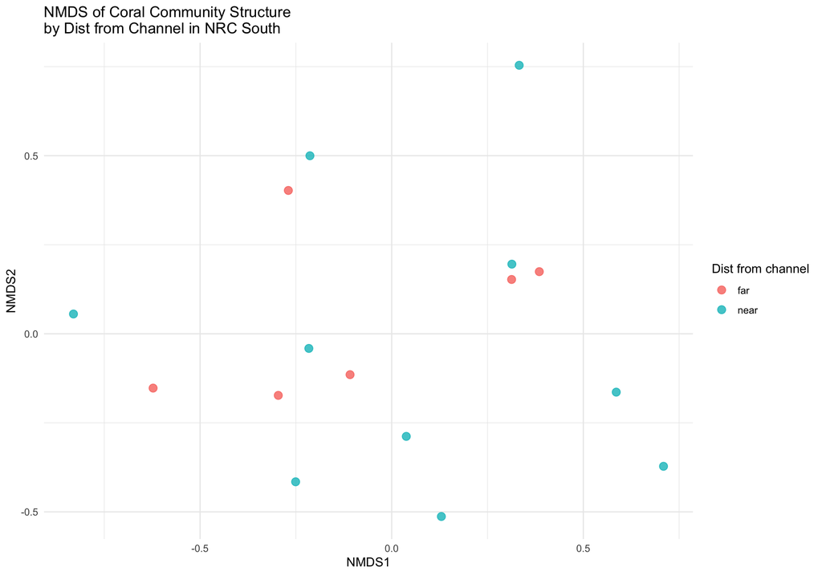

```r
# Prepare data for plotting
scores_df <- scores(nmds)$sites %>%
  bind_cols(site_info)

# Plot NMDS
ggplot(scores_df, aes(x = NMDS1, y = NMDS2, color = grp)) +
  geom_point(size = 3, alpha = 0.8) +
  theme_minimal() +
  labs(title = "NMDS of Coral Community Structure\nby Dist from Channel in NRC South",
       color = "Dist from channel")
```

Density and community composition are not different in the NRC S sites that are nearer vs. farther from the channel. So, no need to exclude the farther sites.

DCA dataset has the most sites in the “Artificial” habitat classification. (Some in other datasets too, but DCA has most). Can ‘Artificial’ be aggregated with ‘Nearshore Ridge Complex’?

‘Artificial’ is only present in DCA and minorly in TT – but absent from Shedd.  
It is in close spatial proximity to Nearshore Ridge Complex – can these be combined?

Test for differences in coral density in DCA survey between habitat types

```r
# Subset DCA data
dcadf <- dca17_counts_ag %>%
  left_join(allsitemd)

# Fit a Negative Binomial GLM
mod_nb <- MASS::glm.nb(n ~ Type, data = dcadf)

# Generate new data only for existing habitats
newdata_1 <- dcadf %>%
  distinct(Type)

# Get predicted values & standard errors (log scale)
preds_nb <- predict(mod_nb, newdata_1, type = "link", se.fit = TRUE)

# Compute total coral density per habitat
results_nb <- newdata_1 %>%
  mutate(
    fit = exp(preds_nb$fit),                    # Convert fitted values to response scale
    fit_se = exp(preds_nb$fit) * preds_nb$se.fit,   # Convert SE using the Delta Method
    fit_var = (fit * preds_nb$se.fit)^2,         # Variance propagation
    fit_lower = exp(preds_nb$fit - 1.96 * preds_nb$se.fit),  # Lower CI
    fit_upper = exp(preds_nb$fit + 1.96 * preds_nb$se.fit)   # Upper CI
  )

# Compute total coral density + confidence intervals
total_ci_nb <- results_nb %>%
  group_by(Type) %>%
  summarize(
    total_density = sum(fit),
    total_se = sqrt(sum(fit_var)),
    lower_95CI = exp(log(total_density) - 1.96 * (total_se / total_density)),
    upper_95CI = exp(log(total_density) + 1.96 * (total_se / total_density))
  )

knitr::kable(total_ci_nb)
```

| Type | total_density | total_se | lower_95CI | upper_95CI |
| --- | --- | --- | --- | --- |
| Aggregated Patch Reef | 1.3971429 | 0.1634482 | 1.1108594 | 1.757205 |
| Artificial | 1.5571429 | 0.1814656 | 1.2391666 | 1.956713 |
| Inner Reef | 1.2116883 | 0.1359261 | 0.9725281 | 1.509662 |
| Middle Reef | 0.7593407 | 0.0803194 | 0.6171618 | 0.934274 |
| Nearshore Ridge Complex | 1.7598639 | 0.1409740 | 1.5041540 | 2.059045 |
| Outer Reef | 1.4123077 | 0.0916120 | 1.2436939 | 1.603781 |

Highly overlapping confidence intervals for Artifical and Nearshore Ridge Complex, so no difference in coral density.

Test for differences in community composition in DCA survey

```r
# Create a wide community matrix: rows = site x Type, columns = taxa
comm_matrix <- dcadf %>%
  group_by(site, Type, taxon) %>%
  summarize(total_n = sum(n), .groups = "drop") %>%
  pivot_wider(names_from = taxon, values_from = total_n, values_fill = 0)

# Extract community matrix and metadata
comm_data <- comm_matrix %>% select(-site, -Type)
site_info <- comm_matrix %>% select(site, Type)

# Run NMDS
set.seed(123)
nmds <- metaMDS(comm_data, distance = "bray", k = 2, trymax = 100)
```

```
## Square root transformation
## Wisconsin double standardization
## *** Best solution repeated 1 times
```

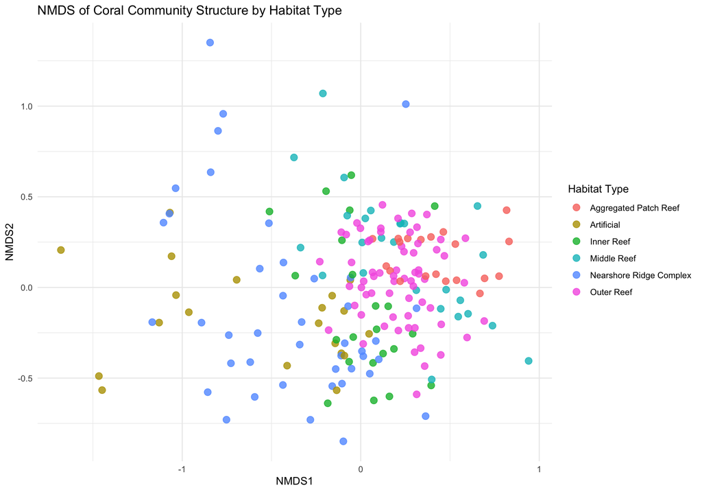

```r
# Prepare data for plotting
scores_df <- scores(nmds)$sites %>%
  bind_cols(site_info)

# Plot NMDS
ggplot(scores_df, aes(x = NMDS1, y = NMDS2, color = Type)) +
  geom_point(size = 3, alpha = 0.8) +
  theme_minimal() +
  labs(title = "NMDS of Coral Community Structure by Habitat Type",
       color = "Habitat Type")
```

High degree of similarity between Artificial and Nearshore Ridge Complex coral communities.

Combine ‘Artificial’ with ‘Nearshore Ridge Complex’

```r
# Based on these results, combine "Artificial" with "Nearshore Ridge Complex"
dff[dff$Type == "Artificial", "Type"] <- "Nearshore Ridge Complex"
```

Combine ‘Aggregated Patch Reef’ with ‘Outer Reef’, following previous studies (DCA)

```r
dff[dff$Type == "Aggregated Patch Reef", "Type"] <- "Outer Reef"

dff <- dff %>% mutate(Type = factor(Type, levels = type_levels))
```

Remove ACER (zeros) from tt23 dataset

```r
dstax <- dff %>%
  filter(!dataset %in% c("nsu11_esa", "dca17_esa")) %>%
  filter(n > 0) %>%
  distinct(dataset, taxon)

dstax %>%
  count(dataset) %>%
  print(n = nrow(.))
```

```
## # A tibble: 4 × 2
##   dataset     n
##   <chr>   <int>
## 1 dca17      20
## 2 drm24      20
## 3 tt21       19
## 4 tt23       19
```

```r
dstax %>%
  count(taxon)
```

```
## # A tibble: 20 × 2
##    taxon     n
##    <chr> <int>
##  1 ACER      3
##  2 AGAR      4
##  3 CNAT      3
##  4 DLAB      4
##  5 DSTO      4
##  6 EFAS      4
##  7 FAVI      4
##  8 MADR      4
##  9 MCAV      4
## 10 MEAN      4
## 11 MMEA      4
## 12 MUSS      4
## 13 MYCE      4
## 14 ORBI      4
## 15 PCLI      4
## 16 PORI      4
## 17 PSTR      4
## 18 SIDE      4
## 19 SINT      4
## 20 SOLE      4
```

```r
# CNAT not observed in TT21 (super rare)
# ACER not observed in TT23 (known habitat distribution was NOT SURVEYED)

## remove ACER from tt23 dff
dff <- dff %>%
  filter(!(taxon == "ACER" & dataset == "tt23"))

survey_counts <- dff
dff <- survey_counts %>% filter(source_cohort == "Original surveys") %>% select(-source_cohort)
selected_original <- selected %>% filter(source_cohort == "Original surveys") %>% select(-source_cohort)
```

# 4 Summarize combined dataset

```r
# Report original survey efforts and the added regional DRM effort as separate
# rows without creating another model dataset level.
summary_counts <- survey_counts %>%
  mutate(dataset = if_else(source_cohort == "Broader DRM", "drm24_regional", as.character(dataset)))
summary_levels <- c(dataset_levels, "drm24_regional")
summary_labels <- c(unname(dataset_labels), "2024 / Broward–Miami DRM")

# Count number of sites per habitat
nsites <- summary_counts %>%
  group_by(dataset, Type) %>%
  summarize(n = n_distinct(site)) %>%
  mutate(Type = factor(Type, levels = type_levels)) %>%
  arrange(Type) %>%
  pivot_wider(names_from = Type, values_from = n, values_fill = 0) %>%
  janitor::adorn_totals(where = "col", name = "Total Sites")

# Get area surveyed per transect and total area surveyed
area_per_site <- summary_counts %>%
  group_by(dataset) %>%
  summarise(
    area_per_site = {
      r <- range(transect_area_m2)
      if (r[1] == r[2]) as.character(r[1]) else paste(r, collapse = " - ")})

total_area <- summary_counts %>%
  group_by(dataset, site) %>%
  summarize(max_area = max(transect_area_m2)) %>%
  summarize(total_area = round(sum(max_area), 0))

# Get total number of corals counted
total_corals <- summary_counts %>%
  group_by(dataset) %>%
  summarize(total_n = sum(n))

survey_summary <- reduce(
  list(nsites, area_per_site, total_area, total_corals),
  full_join,
  by = "dataset"
) %>%
  mutate(dataset = factor(dataset, levels = summary_levels)) %>%
  arrange(dataset) %>%
  janitor::adorn_totals(where = "row") %>%
  mutate(dataset2 = c(summary_labels, "Total"))

dir.create(output_file("intermediate"), recursive = TRUE, showWarnings = FALSE)
write_csv(survey_summary, file = output_file("intermediate/coral_Table1.csv"))

survey_summary %>% knitr::kable()
```

| dataset | Nearshore Ridge Complex | Inner Reef | Middle Reef | Outer Reef | Total Sites | area_per_site | total_area | total_n | dataset2 |
| --- | --- | --- | --- | --- | --- | --- | --- | --- | --- |
| nsu11_esa | 85 | 94 | 83 | 111 | 373 | 3600 | 1342800 | 11871 | 2011 / NSU ESA |
| dca17_esa | 92 | 17 | 21 | 25 | 155 | 784 | 121520 | 3620 | 2017 / DCA ESA |
| dca17 | 62 | 22 | 26 | 85 | 195 | 30 | 5850 | 9489 | 2017 / DCA Recon |
| tt21 | 7 | 6 | 5 | 17 | 35 | 3.9 - 784 | 24314 | 2172 | 2021 / Tetra Tech |
| tt23 | 81 | 19 | 34 | 38 | 172 | 10 - 20 | 3180 | 5691 | 2023 / Tetra Tech |
| drm24 | 25 | 15 | 6 | 0 | 46 | 20 - 40 | 1840 | 2566 | 2024 / Shedd |
| drm24_regional | 63 | 15 | 10 | 5 | 93 | 20 - 40 | 3720 | 2721 | 2024 / Broward–Miami DRM |
| Total | 415 | 188 | 185 | 281 | 1069 | - | 1503224 | 38130 | Total |

```r
# Summarize count data
# Just get columns we need for modeling
dfftaxon <- dff %>% select(dataset, Type, dir, site, transect_area_m2, taxon, class, n)
all_coral_counts <- survey_counts %>%
  select(dataset, Type, dir, site, transect_area_m2, taxon, class, n, source_cohort)
write_csv(all_coral_counts, file = processed_file("all_coral_counts_processed.csv"))
write_csv(dfftaxon, file = processed_file("original_coral_counts_processed.csv"))
compilation_summary <- tibble(
  observations = nrow(all_coral_counts), colonies = sum(all_coral_counts$n),
  taxa = n_distinct(all_coral_counts$taxon),
  survey_sites = n_distinct(interaction(all_coral_counts$dataset, all_coral_counts$site)),
  added_regional_sites = n_distinct(all_coral_counts$site[all_coral_counts$source_cohort == "Broader DRM"])
)
write_csv(compilation_summary, output_file("compilation_summary.csv"))
show_table(compilation_summary, digits = 0)
```

| observations | colonies | taxa | survey_sites | added_regional_sites |
| --- | --- | --- | --- | --- |
| 16340 | 38130 | 20 | 1069 | 93 |

```r
# Number of observations/counts
nrow(all_coral_counts)
```

```
## [1] 16340
```

```r
# Number of colonies counted
sum(all_coral_counts$n)
```

```
## [1] 38130
```

```r
# Number of taxa observed
n_distinct(all_coral_counts$taxon)
```

```
## [1] 20
```

```r
# Number of sites surveyed
n_distinct(interaction(all_coral_counts$dataset, all_coral_counts$site))
```

```
## [1] 1069
```

```r
# Zero-inflation / Number of zeros
table(all_coral_counts$n == 0)
```

```
##
## FALSE  TRUE
##  5078 11262
```

```r
# Overdispersion
mean_count <- mean(all_coral_counts$n)
var_count <- var(all_coral_counts$n)
var_count / mean_count
```

```
## [1] 66.22142
```

```r
# Data are highly zero-inflated and overdispersed -- use zero-inflated negative binomial models.
```

# 5 Map surveys & impact zones

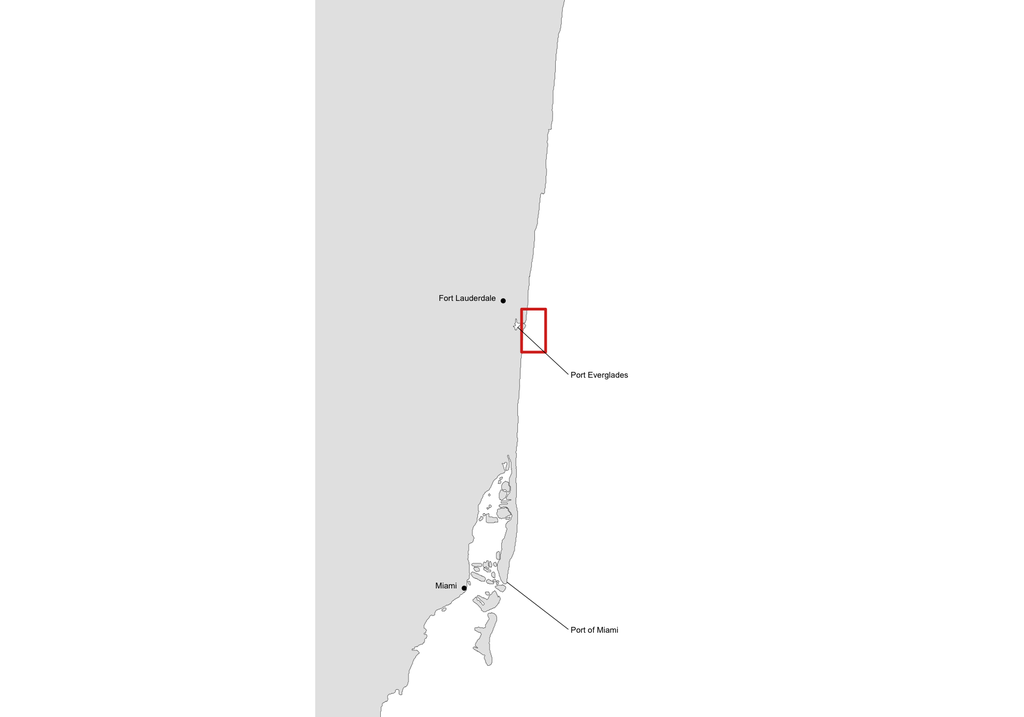

```r
# High-resolution SE Florida coastline with GSHHG (no counties), plus ports & study box
# ------------------------------------------------------------------------------------
# Install if needed:
# install.packages(c("sf","dplyr","ggplot2"))
# (No special geofabrik/overpass/hires packages required)

library(sf)
library(dplyr)
library(ggplot2)

# 1) Define your exact view bbox (SE Florida)
bbox_view <- st_bbox(c(
  xmin = -80.4, ymin = 25.60,
  xmax = -79.85, ymax = 26.50
), crs = st_crs(4326))

# Slight pad for safety when cropping
pad <- 0.05
bbox_pad <- bbox_view
bbox_pad["xmin"] <- bbox_view["xmin"] - pad
bbox_pad["ymin"] <- bbox_view["ymin"] - pad
bbox_pad["xmax"] <- bbox_view["xmax"] + pad
bbox_pad["ymax"] <- bbox_view["ymax"] + pad

# 2) Read the bundled full-resolution regional coastline (GSHHG 2.3.7).
# Source and crop bounds are documented in data/spatial/README.md.
gshhg_coast <- st_read("data/spatial/SE_Florida_coast.gpkg", quiet = TRUE) |>
  st_transform(4326)

# 3) Crop to your SE Florida view and convert to outlines (boundaries)
# 3) Validate, crop with s2 off, then take boundaries
bbox_pad_sfc <- st_as_sfc(bbox_pad)

# save current s2 setting and turn it off just for the clip
old_s2 <- sf::sf_use_s2()
sf::sf_use_s2(FALSE)
on.exit(sf::sf_use_s2(old_s2), add = TRUE)

# fix invalid rings, then clip to bbox
gshhg_valid <- sf::st_make_valid(gshhg_coast)
coast_crop  <- suppressWarnings(st_intersection(gshhg_valid, bbox_pad_sfc))

# optional: keep only polygons (in case multiparts/lines slipped in)
coast_crop  <- st_collection_extract(coast_crop, "POLYGON")

coast_line <- st_boundary(coast_crop)  # draw only the outline (crisp line map)

# 4) Annotations: ports + your detailed study box
ports <- tibble::tibble(
  name = c("Port Everglades", "Port of Miami"),
  lon  = c(-80.118, -80.133),
  lat  = c(26.090, 25.770)
)
cities <- tibble::tibble(
  name = c("Miami", "Fort Lauderdale"),
  lon = c(-80.1918, -80.1373),
  lat = c(25.7617, 26.1224)
)

study_box <- st_as_sfc(st_bbox(
  c(xmin = -80.1116, xmax = -80.078, ymin = 26.058, ymax = 26.112),
  crs = 4326
))

# 5) Plot: ultra-clean coastline outline + study box + ports
p_sef_gshhg <- ggplot() +
  geom_sf(data = coast_crop, fill = "gray90", color = "black", linewidth = 0.1) +
  geom_sf(data = study_box, fill = NA, color = "#D7301F", linewidth = 0.9) +
  geom_text_repel(data = ports, aes(lon, lat, label = name), hjust = 0, size = 2, nudge_y = -0.06,
                  xlim = c(-80.05, NA), segment.size = 0.2) +
  geom_point(data = cities, aes(lon, lat), size = 1) +
  geom_text(data = cities, aes(lon, lat, label = name), hjust = 1, vjust = 0, size = 2, nudge_x = -0.01) +
  coord_sf(xlim = c(bbox_view["xmin"], bbox_view["xmax"]),
           ylim = c(bbox_view["ymin"], bbox_view["ymax"]),
           expand = FALSE) +
  theme_void()

p_sef_gshhg
```

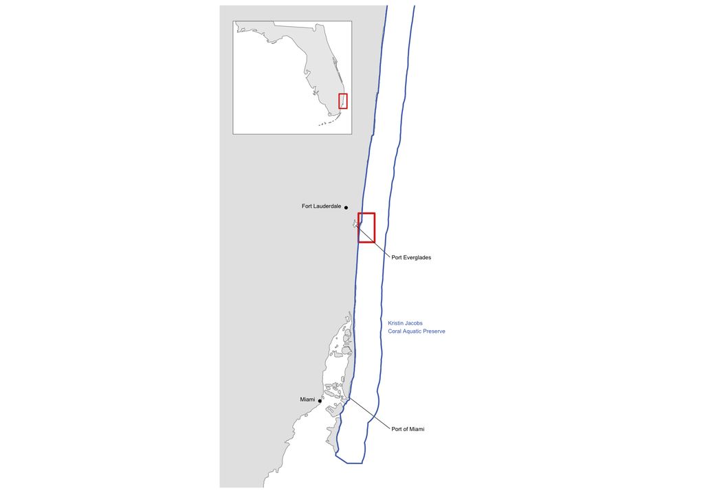

```r
# KJ Coral Reef ECA
kj_eca <- st_read("data/spatial/KJ_Coral_Aquatic_Preserve.gpkg", quiet = TRUE)

# Add to your existing map (choose fill/line to taste)
p_sef_map <- p_sef_gshhg +   # or p_sef_gshhg / p_sef_hi, etc.
  geom_sf(data = kj_eca, fill = NA, color = "#4B6CB7", linewidth = 0.6) +
  # or with a subtle transparent fill:
  # geom_sf(data = kj_eca, fill = scales::alpha("#4B6CB7", 0.08), color = "#4B6CB7", linewidth = 0.4)
    coord_sf(xlim = c(bbox_view["xmin"], bbox_view["xmax"]),
           ylim = c(bbox_view["ymin"], bbox_view["ymax"]),
           expand = FALSE) +
  annotate("text", x = -80.05, y = 25.9, label = "Kristin Jacobs\nCoral Aquatic Preserve",
           color = "#4B6CB7", hjust = 0, size = 2)

#p_sef_map



#####
library(rnaturalearth)
library(rnaturalearthdata)

# 1) Get a simple USA states outline
# Use the bundled Natural Earth state layer: no network download.
usa_states <- st_as_sf(rnaturalearthdata::states50)
fl_outline <- usa_states %>% filter(name == "Florida")

# 2) Define a Florida-wide bbox for inset
fl_bbox <- st_bbox(c(
  xmin = -87.8, ymin = 24.0,
  xmax = -79.5, ymax = 31.0
), crs = st_crs(4326))
fl_bbox_sfc <- st_as_sfc(fl_bbox)

# 3) Build inset plot with simple Florida outline + red box for SE FL extent
p_inset_simple <- ggplot() +
  geom_sf(data = fl_outline, fill = "grey92", color = "black", linewidth = 0.1) +
  geom_sf(data = st_as_sfc(bbox_view), fill = NA, color = "#D7301F", linewidth = 0.6) +
  coord_sf(xlim = c(fl_bbox["xmin"], fl_bbox["xmax"]),
           ylim = c(fl_bbox["ymin"], fl_bbox["ymax"]),
           expand = FALSE) +
  theme_void() +
  theme(
    panel.border = element_rect(color = "black", fill = NA, linewidth = 0.25), # <-- border
    panel.background = element_rect(color = "black", fill = "white", linewidth = 0) # <-- border
  )

# 4) Add inset to your detailed SE Florida map
p_final_with_inset <- p_sef_map +
  theme(plot.margin = margin(0,-10,0,0)) +
  # theme(
  #   plot.background = element_rect(
  #     color = "black",   # border color
  #     fill  = "white",   # background fill
  #     linewidth = 1      # thickness of the border
  #   )
  # ) +
  inset_element(p_inset_simple,
                left = 0.05, bottom = 0.6, right = 0.5, top = 1.1,
                align_to = "panel")

p_final_with_inset
```

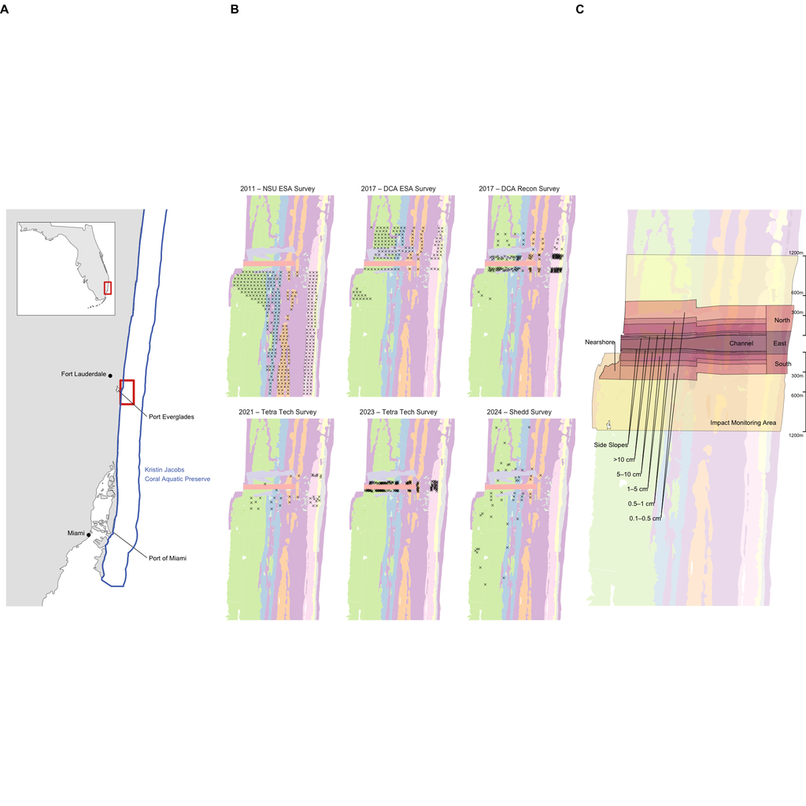

```r
# Define shared coordinate limits
coord_limits <- coord_sf(
  xlim = c(-80.1116, -80.078),
  ylim = c(26.058, 26.112),
  expand = FALSE#, clip = "off"#,
  #datum = NA  # avoid graticule
)

# Simplified base theme for clean layout
base_theme <- theme_minimal(base_size = 8) +
  theme(
    axis.title = element_blank(),
    axis.text = element_blank(),
    #axis.ticks = element_blank(),
    panel.grid = element_blank(),
    plot.margin = margin(t = 12, r = 5, b = 5, l = 5),
  )

# Reorder survey datasets
selected_original <- selected_original %>% mutate(dataset = factor(dataset, levels = c("nsu11_esa", "dca17_esa", "dca17", "tt21", "tt23", "drm24")))


# Left panel: faceted survey locations
pp2 <- ggplot(polygons_final) +
  # LAND background (from NOAA GSHHG)
  #geom_sf(data = land_zoom, fill = "grey90", color = "grey65", linewidth = 0.15) +

  geom_sf(aes(fill = Type), color = NA, size = 0.1, alpha = 0.5) +
  geom_point(
    data = selected_original,
    aes(x = longitude, y = latitude),
    pch = 4, alpha = 0.6, size = 0.65, stroke = 0.3, inherit.aes = FALSE
  ) +
  #scale_fill_brewer(palette = "Set3", na.value = "gray80") +
  scale_fill_manual(values = typecols, na.value = "gray80") +
  facet_wrap(~ dataset, ncol = 3,
               labeller = as_labeller(c(
    "nsu11_esa" = "2011 – NSU ESA Survey",
    "dca17_esa" = "2017 – DCA ESA Survey",
    "dca17"     = "2017 – DCA Recon Survey",
    "tt21"      = "2021 – Tetra Tech Survey",
    "tt23"      = "2023 – Tetra Tech Survey",
    "drm24"     = "2024 – Shedd Survey"
  ))) +
  coord_limits +
  scale_x_continuous(breaks = c(-80.11, -80.10, -80.09, -80.08)) +
  labs(title = NULL, fill = NULL) +
  base_theme +
  theme(
    legend.position = "none",
    strip.text = element_text(size = 6),
    panel.spacing = unit(0.5, "lines"),
    plot.margin = margin(2,0,0,-10)
  )

# Right panel: impact zones
iz_plot_clean <- p +
  geom_segment(data = label_segments,
               aes(x = segment_x, y = segment_y,
                   xend = label_x, yend = label_y),
               color = "black", linewidth = 0.2) +
  geom_text(data = zone_labels,
            aes(x = label_x, y = label_y, label = name),
            size = 2, hjust = 1) +
  coord_sf(xlim = c(-80.1116, -80.077), ylim = c(26.058, 26.112), expand = FALSE) +
  base_theme +
  theme(legend.position = "none") +
  geom_segment(
    data = scale_lines,
    aes(x = x, y = y, xend = xend, yend = yend),
    inherit.aes = FALSE,
    color = "black",
    linewidth = 0.4
  ) +
  geom_segment(
    data = ticks_segments,
    aes(x = x, y = y, xend = xend, yend = yend),
    color = "black",
    linewidth = 0.3
  ) +
  geom_text(
    data = tick_labels,
    aes(x = x, y = y, label = label),
    hjust = 1,
    vjust = c(rep(1.5, 4), rep(-0.5, 4)),
    size = 1.5
  ) +
  theme(plot.margin = margin(0,0,0,0))

dir.create(output_file("intermediate"), recursive = TRUE, showWarnings = FALSE)
saveRDS(p_final_with_inset, output_file("intermediate/coral_fig1_panel_a_ggplot.rds"))
saveRDS(iz_plot_clean, output_file("intermediate/coral_fig1_panel_c_ggplot.rds"))
save_figure(
  output_file("intermediate/coral_fig1_panel_c.png"),
  iz_plot_clean,
  width = 85,
  height = 120,
  units = "mm",
  dpi = 300,
  bg = "white"
)

# # Set y tick positions and labels manually
# y_breaks <- c(26.06, 26.07, 26.08, 26.11)  # adjust to match your plot extent
# x_right_label <- -80.08  # just outside your xlim max
#
# right_axis_labels <- tibble(
#   x = x_right_label,
#   y = y_breaks,
#   label = scales::number(y_breaks, accuracy = 0.01)
# )
#
# x_breaks <- c(-80.09, -80.10, -80.11)
# y_bottom_label <- 26.06
# bottom_axis_labels <- tibble(x = x_breaks, y = y_bottom_label,
#                              label = scales::number(x_breaks, accuracy = 0.01))

# iz_plot_clean <- iz_plot_clean +
#   geom_text(data = right_axis_labels,
#             aes(x = x, y = y, label = label),
#             size = 2, hjust = 1, vjust = 0, fontface = "italic", color = "gray") +
#   geom_text(data = bottom_axis_labels,
#             aes(x = x, y = y, label = label),
#             size = 2, hjust = 0, vjust = 1, fontface = "italic", color = "gray")



# Combine with cowplot
final_fig <- plot_grid(
  p_final_with_inset,
  pp2,
  iz_plot_clean,
  nrow = 1,
  align = "hv",
  axis = "tb",
  labels = c("A", "B", "C"), hjust = 0, label_size = 11,
  rel_widths = c(0.24, 0.36, 0.24)  # adjust until panel areas are visually aligned
)
final_fig
```

```r
# Extract fill legend from habitat polygon plot
legend_plot <- polyplot +
  scale_fill_manual(values = typecols, na.value = "gray80") +
  guides(shape = "none", color = "none", fill = guide_legend(nrow = 2)) +
  base_theme +
  theme(
    legend.position = "bottom",
    legend.key.size = unit(0.3, "cm"),  # Reduce square size
    legend.text = element_text(size = 6),  # Optional: smaller legend text
    legend.title = element_text(size = 7)  # Optional: smaller legend title
  )
grob <- ggplotGrob(legend_plot)
fill_legend <- gtable::gtable_filter(grob, "guide-box")

bottom_row <- plot_grid(NULL, fill_legend, ncol = 2, rel_widths = c(0.2, 0.6))
final_final_fig <- plot_grid(final_fig, bottom_row, ncol = 1, rel_heights = c(0.92, 0.08))

# Save output
save_figure(
  filename = output_file("intermediate/coral_Fig1.png"),
  plot = final_final_fig,
  width = 220,
  height = 125,
  units = "mm",
  dpi = 300,
  bg = "white"
)
```

# 6 Joint adult and juvenile model

## 6.1 Geographic membership and original observations

All survey observations have been imported and filtered above. The original survey subset is retained as the manuscript’s source-availability reference; regional observations do not change those averaging weights. Region is assigned from coordinates, not survey team or file membership. Distances are in UTM 17N and measured north or south from the nearest channel bounding edge, not radially from the inlet.

```r
original_survey_counts <- dfftaxon %>%
  mutate(across(c(dataset, site, taxon, class, Type, dir), as.character),
         original_pev_row = row_number())
original_coordinates <- allsitemd_original %>%
  select(dataset, site, latitude, longitude) %>%
  distinct() %>%
  semi_join(original_survey_counts, by = c("dataset", "site"))
stopifnot(!anyDuplicated(original_coordinates[c("dataset", "site")]))
channel_utm <- channel_poly %>% st_zm() %>% st_transform(32617) %>% st_make_valid()
channel_bounds <- st_bbox(channel_utm)
classify_region <- function(x) {
  stopifnot(all(is.finite(x$latitude)), all(is.finite(x$longitude)))
  points_utm <- st_as_sf(x, coords = c("longitude", "latitude"), crs = 4326) %>%
    st_transform(32617)
  northing <- st_coordinates(points_utm)[, 2]
  x$ns_distance_from_channel_m <- pmax(channel_bounds[["ymin"]] - northing,
                                      northing - channel_bounds[["ymax"]], 0)
  x$region <- ifelse(x$ns_distance_from_channel_m <= 1200, "PEV", "Broward-Miami")
  x
}
original_joint_counts <- original_survey_counts %>%
  left_join(original_coordinates, by = c("dataset", "site")) %>%
  classify_region() %>%
  mutate(source = "Original surveys")
write_csv(original_joint_counts, output_file("original_survey_geographic_assignments.csv"))
geographic_rule <- data.frame(
  rule = "PEV: <=1,200 m N/S of the nearest channel bounding edge",
  crs_epsg = 32617, cutoff_m = 1200,
  channel_ymin_m = channel_bounds[["ymin"]], channel_ymax_m = channel_bounds[["ymax"]],
  pev_ymin_m = channel_bounds[["ymin"]] - 1200,
  pev_ymax_m = channel_bounds[["ymax"]] + 1200
)
write_csv(geographic_rule, output_file("geographic_definition.csv"))

# Both subsets come from the already combined, habitat-filtered survey_counts.
# These origin labels are retained for audits; they do not define region.
regional_sites <- regional_site_audit %>%
  filter(exclusion == "Retained") %>%
  mutate(dir = if_else(latitude > 26.093570, "N", "S")) %>% classify_region()
write_csv(regional_sites, output_file("regional_site_metadata.csv"))
show_table(count(regional_site_audit, exclusion))
```

| exclusion | n |
| --- | --- |
| DRM PTCH excluded | 1 |
| Original metadata site: do not add twice | 39 |
| Outside the four mapped reef strata | 5 |
| Retained | 93 |

```r
show_table(count(regional_sites, region, Type))
```

| region | Type | n |
| --- | --- | --- |
| Broward-Miami | Inner Reef | 15 |
| Broward-Miami | Middle Reef | 10 |
| Broward-Miami | Nearshore Ridge Complex | 63 |
| Broward-Miami | Outer Reef | 5 |

```r
regional_counts_columns <- c("site", "taxon", "n", "class", "dataset", "transect_area_m2", "Type", "dir")
regional_adults <- survey_counts %>%
  filter(source_cohort == "Broader DRM", class == ">4cm") %>%
  select(all_of(regional_counts_columns)) %>% mutate(across(c(taxon, class, Type, dir), as.character)) %>%
  left_join(select(regional_sites, site, latitude, longitude, region, ns_distance_from_channel_m), by = "site") %>%
  mutate(source = "Added DRM2024 adults")
regional_juveniles <- survey_counts %>%
  filter(source_cohort == "Broader DRM", class == "<4cm") %>%
  select(all_of(regional_counts_columns)) %>% mutate(across(c(taxon, class, Type, dir), as.character)) %>%
  left_join(select(regional_sites, site, latitude, longitude, region, ns_distance_from_channel_m), by = "site") %>%
  mutate(source = "Added DRM2024 juveniles")
```

## 6.2 Survey coverage and raw-data quality control

All surveys have already been imported, assigned habitats and filtered above. These checks report the retained regional transects, searched areas and raw versus cleaned adult records. The annual adult export is authoritative; the two fully recently dead worksheet colonies remain excluded.

```r
regional_records <- drm_regional %>% semi_join(regional_sites, by = "site")
adult_records <- adult_records_imported %>% semi_join(regional_sites, by = "site")
adult_taxa <- sort(unique(original_survey_counts$taxon[original_survey_counts$class == ">4cm"]))
write_csv(filter(adult_records, !taxon %in% adult_taxa),
          output_file("regional_adult_taxa_outside_model.csv"))
missing_sizes <- regional_records %>% filter(!is.na(species), is.na(width) & is.na(height))
unexpected_extra_transects <- regional_records %>%
  filter(transect_num %in% 3:4, !is.na(species), !species %in% target_species)
write_csv(missing_sizes, output_file("adult_colonies_missing_sizes.csv"))
write_csv(unexpected_extra_transects, output_file("adult_nontarget_T3_T4_records.csv"))
stopifnot(nrow(missing_sizes) == 0, nrow(unexpected_extra_transects) == 0,
          all(regional_adults$transect_area_m2[regional_adults$taxon == "MYCE"] == 40))
juvenile_transect_counts <- juvenile_transect_counts_imported %>%
  semi_join(regional_sites, by = "site")
juvenile_audit <- juvenile_transect_counts %>%
  group_by(taxon, transect_num) %>%
  summarize(sites = n_distinct(site), colonies = sum(n), searched_m2 = sum(transect_area_m2),
            .groups = "drop")
write_csv(juvenile_transect_counts, output_file("regional_juvenile_transect_counts.csv"))
write_csv(juvenile_audit, output_file("juvenile_transect_audit.csv"))
show_table(juvenile_audit)
```

| taxon | transect_num | sites | colonies | searched_m2 |
| --- | --- | --- | --- | --- |
| FAVI | 1 | 93 | 0 | 930 |
| FAVI | 2 | 93 | 7 | 930 |
| FAVI | 3 | 93 | 4 | 930 |
| FAVI | 4 | 93 | 4 | 930 |
| MCAV | 1 | 93 | 58 | 930 |
| MCAV | 2 | 93 | 50 | 930 |
| MCAV | 3 | 93 | 54 | 930 |
| MCAV | 4 | 93 | 48 | 930 |
| MEAN | 1 | 93 | 6 | 930 |
| MEAN | 2 | 93 | 9 | 930 |
| MEAN | 3 | 93 | 12 | 930 |
| MEAN | 4 | 93 | 4 | 930 |
| MUSS | 1 | 93 | 9 | 930 |
| MUSS | 2 | 93 | 5 | 930 |
| MUSS | 3 | 93 | 3 | 930 |
| MUSS | 4 | 93 | 3 | 930 |

```r
adult_worksheet_files <- file.path("data/2024_shedd_drm", c(
  "2024ANU_RawCoralDataTransect1and2_Shedd.xlsx",
  "2024ANU_RawCoralDataTransect3and4_Shedd.xlsx"
))
adult_worksheet <- map_dfr(adult_worksheet_files, ~readxl::read_xlsx(.x, guess_max = 50000) %>%
                            janitor::clean_names()) %>%
  filter(subregion == "Broward-Miami") %>% mutate(site = as.character(site)) %>%
  semi_join(regional_sites, by = "site")
missing_adult_transects <- anti_join(crossing(site = regional_sites$site, transect_num = 1:4),
                                    distinct(adult_worksheet, site, transect_num),
                                    by = c("site", "transect_num"))
stopifnot(nrow(missing_adult_transects) == 0)
adult_audit <- adult_worksheet %>% group_by(transect_num) %>%
  summarize(sites = n_distinct(site), raw_rows = n(), recorded_colonies = sum(!is.na(species)),
            .groups = "drop")
comparison_keys <- c("site", "transect_num", "species", "width", "height")
adult_record_comparison <- full_join(
  adult_worksheet %>% filter(!is.na(species)) %>% count(across(all_of(comparison_keys)), name = "worksheet_rows"),
  regional_records %>% filter(!is.na(species)) %>% count(across(all_of(comparison_keys)), name = "annual_rows"),
  by = comparison_keys
) %>% mutate(across(c(worksheet_rows, annual_rows), ~replace_na(.x, 0L)),
             difference = worksheet_rows - annual_rows)
adult_record_differences <- filter(adult_record_comparison, difference != 0)
stopifnot(nrow(adult_record_differences) == 2,
          setequal(paste(adult_record_differences$site, adult_record_differences$transect_num,
                         adult_record_differences$species), c("AA1083 2 SRAD", "AA1159 4 MALI")))
write_csv(adult_audit, output_file("adult_transect_audit.csv"))
write_csv(adult_record_comparison, output_file("adult_raw_multiset_validation.csv"))
write_csv(adult_record_differences, output_file("adult_raw_vs_cleaned_differences.csv"))
show_table(adult_audit)
```

| transect_num | sites | raw_rows | recorded_colonies |
| --- | --- | --- | --- |
| 1 | 93 | 1098 | 1098 |
| 2 | 93 | 1245 | 1245 |
| 3 | 93 | 112 | 59 |
| 4 | 93 | 107 | 50 |

```r
show_table(adult_record_differences)
```

| site | transect_num | species | width | height | worksheet_rows | annual_rows | difference |
| --- | --- | --- | --- | --- | --- | --- | --- |
| AA1083 | 2 | SRAD | 4 | 3 | 2 | 1 | 1 |
| AA1159 | 4 | MALI | 23 | 10 | 1 | 0 | 1 |

## 6.3 Assemble the full likelihood and check the spatial footprint

```r
model_columns <- c("dataset", "site", "taxon", "class", "Type", "dir", "n",
                   "transect_area_m2", "region", "source", "latitude", "longitude",
                   "ns_distance_from_channel_m")
joint_counts <- bind_rows(select(original_joint_counts, all_of(model_columns)),
                          select(regional_adults, all_of(model_columns)),
                          select(regional_juveniles, all_of(model_columns)))
stopifnot(!anyDuplicated(joint_counts[c("dataset", "site", "taxon", "class")]),
          all(joint_counts$n >= 0 & joint_counts$n == round(joint_counts$n)),
          all(joint_counts$transect_area_m2 > 0))
write_csv(joint_counts, output_file("joint_model_inputs.csv"))
joint_survey_summary <- joint_counts %>% group_by(region, dataset, source, class, Type) %>%
  summarize(sites = n_distinct(site), rows = n(), colonies = sum(n), .groups = "drop")
write_csv(joint_survey_summary, output_file("joint_survey_summary.csv"))
show_table(joint_survey_summary)
```

| region | dataset | source | class | Type | sites | rows | colonies |
| --- | --- | --- | --- | --- | --- | --- | --- |
| Broward-Miami | drm24 | Added DRM2024 adults | >4cm | Inner Reef | 15 | 255 | 658 |
| Broward-Miami | drm24 | Added DRM2024 adults | >4cm | Middle Reef | 10 | 170 | 218 |
| Broward-Miami | drm24 | Added DRM2024 adults | >4cm | Nearshore Ridge Complex | 63 | 1071 | 1455 |
| Broward-Miami | drm24 | Added DRM2024 adults | >4cm | Outer Reef | 5 | 85 | 114 |
| Broward-Miami | drm24 | Added DRM2024 juveniles | <4cm | Inner Reef | 15 | 60 | 124 |
| Broward-Miami | drm24 | Added DRM2024 juveniles | <4cm | Middle Reef | 10 | 40 | 38 |
| Broward-Miami | drm24 | Added DRM2024 juveniles | <4cm | Nearshore Ridge Complex | 63 | 252 | 98 |
| Broward-Miami | drm24 | Added DRM2024 juveniles | <4cm | Outer Reef | 5 | 20 | 16 |
| Broward-Miami | drm24 | Original surveys | <4cm | Inner Reef | 3 | 36 | 68 |
| Broward-Miami | drm24 | Original surveys | <4cm | Nearshore Ridge Complex | 7 | 84 | 373 |
| Broward-Miami | drm24 | Original surveys | >4cm | Inner Reef | 3 | 51 | 74 |
| Broward-Miami | drm24 | Original surveys | >4cm | Nearshore Ridge Complex | 7 | 119 | 109 |
| Broward-Miami | nsu11_esa | Original surveys | >4cm | Inner Reef | 54 | 162 | 1544 |
| Broward-Miami | nsu11_esa | Original surveys | >4cm | Middle Reef | 68 | 204 | 2517 |
| Broward-Miami | nsu11_esa | Original surveys | >4cm | Nearshore Ridge Complex | 4 | 12 | 142 |
| Broward-Miami | nsu11_esa | Original surveys | >4cm | Outer Reef | 78 | 234 | 1917 |
| PEV | dca17 | Original surveys | <4cm | Inner Reef | 22 | 264 | 473 |
| PEV | dca17 | Original surveys | <4cm | Middle Reef | 26 | 312 | 238 |
| PEV | dca17 | Original surveys | <4cm | Nearshore Ridge Complex | 62 | 744 | 2823 |
| PEV | dca17 | Original surveys | <4cm | Outer Reef | 85 | 1020 | 1306 |
| PEV | dca17 | Original surveys | >4cm | Inner Reef | 22 | 374 | 460 |
| PEV | dca17 | Original surveys | >4cm | Middle Reef | 26 | 442 | 453 |
| PEV | dca17 | Original surveys | >4cm | Nearshore Ridge Complex | 62 | 1054 | 853 |
| PEV | dca17 | Original surveys | >4cm | Outer Reef | 85 | 1445 | 2883 |
| PEV | dca17_esa | Original surveys | <4cm | Inner Reef | 17 | 34 | 0 |
| PEV | dca17_esa | Original surveys | <4cm | Middle Reef | 21 | 42 | 0 |
| PEV | dca17_esa | Original surveys | <4cm | Nearshore Ridge Complex | 92 | 184 | 11 |
| PEV | dca17_esa | Original surveys | <4cm | Outer Reef | 25 | 50 | 0 |
| PEV | dca17_esa | Original surveys | >4cm | Inner Reef | 17 | 34 | 13 |
| PEV | dca17_esa | Original surveys | >4cm | Middle Reef | 21 | 42 | 1 |
| PEV | dca17_esa | Original surveys | >4cm | Nearshore Ridge Complex | 92 | 184 | 3574 |
| PEV | dca17_esa | Original surveys | >4cm | Outer Reef | 25 | 50 | 21 |
| PEV | drm24 | Original surveys | <4cm | Inner Reef | 12 | 144 | 347 |
| PEV | drm24 | Original surveys | <4cm | Middle Reef | 6 | 72 | 167 |
| PEV | drm24 | Original surveys | <4cm | Nearshore Ridge Complex | 18 | 216 | 822 |
| PEV | drm24 | Original surveys | >4cm | Inner Reef | 12 | 204 | 279 |
| PEV | drm24 | Original surveys | >4cm | Middle Reef | 6 | 102 | 122 |
| PEV | drm24 | Original surveys | >4cm | Nearshore Ridge Complex | 18 | 306 | 205 |
| PEV | nsu11_esa | Original surveys | >4cm | Inner Reef | 40 | 120 | 985 |
| PEV | nsu11_esa | Original surveys | >4cm | Middle Reef | 15 | 45 | 115 |
| PEV | nsu11_esa | Original surveys | >4cm | Nearshore Ridge Complex | 81 | 243 | 4411 |
| PEV | nsu11_esa | Original surveys | >4cm | Outer Reef | 33 | 99 | 240 |
| PEV | tt21 | Original surveys | <4cm | Inner Reef | 6 | 72 | 141 |
| PEV | tt21 | Original surveys | <4cm | Middle Reef | 5 | 60 | 107 |
| PEV | tt21 | Original surveys | <4cm | Nearshore Ridge Complex | 7 | 84 | 297 |
| PEV | tt21 | Original surveys | <4cm | Outer Reef | 17 | 204 | 702 |
| PEV | tt21 | Original surveys | >4cm | Inner Reef | 6 | 102 | 115 |
| PEV | tt21 | Original surveys | >4cm | Middle Reef | 5 | 85 | 92 |
| PEV | tt21 | Original surveys | >4cm | Nearshore Ridge Complex | 7 | 119 | 155 |
| PEV | tt21 | Original surveys | >4cm | Outer Reef | 17 | 289 | 563 |
| PEV | tt23 | Original surveys | <4cm | Inner Reef | 19 | 209 | 333 |
| PEV | tt23 | Original surveys | <4cm | Middle Reef | 34 | 374 | 483 |
| PEV | tt23 | Original surveys | <4cm | Nearshore Ridge Complex | 81 | 891 | 1376 |
| PEV | tt23 | Original surveys | <4cm | Outer Reef | 38 | 418 | 1115 |
| PEV | tt23 | Original surveys | >4cm | Inner Reef | 19 | 304 | 357 |
| PEV | tt23 | Original surveys | >4cm | Middle Reef | 34 | 544 | 643 |
| PEV | tt23 | Original surveys | >4cm | Nearshore Ridge Complex | 81 | 1296 | 616 |
| PEV | tt23 | Original surveys | >4cm | Outer Reef | 38 | 608 | 768 |

```r
# The geometric outlines differ, but all modeled sites must classify identically.
zone_union <- st_union(st_transform(st_make_valid(all_zones_sf), 32617))
geographic_sites <- distinct(joint_counts, dataset, site, region, latitude, longitude)
geographic_points <- st_as_sf(geographic_sites, coords = c("longitude", "latitude"),
                              crs = 4326, remove = FALSE) %>% st_transform(32617)
geographic_sites$inside_original_polygon_union <- lengths(st_covered_by(geographic_points, zone_union)) > 0
geographic_sites$inside_ns_band <- geographic_sites$region == "PEV"
write_csv(geographic_sites, output_file("spatial_classification_crosscheck.csv"))
stopifnot(all(geographic_sites$inside_original_polygon_union == geographic_sites$inside_ns_band))
pev_raw_counts <- joint_counts %>% filter(region == "PEV")

# Freeze the original source-coverage grid for manuscript source averaging.
# These are weights/grids, not reuse of the old fitted posterior.
prediction_reference <- dfftaxon
```

## 6.4 Specify the joint model in brms

This candidate keeps the same observed likelihood rows and scientific targets as the previous joint pilot. The following choices are explicit:

| Component | brms candidate |
| --- | --- |
| Observations | Identical counts, effort, site/source, taxon/class/habitat and regional assignments |
| Family and offset | Zero-inflated negative binomial; log searched area |
| Baseline structure | Original taxon:class * Type for counts, zi and shape |
| Baseline coefficient priors | Selected explicitly by prior_version; count priors retained in both versions |
| Intercept centering | Ordinary combined-data brms centering, including regional count columns |
| Regional count differences | One normal(0, 1.5) coefficient on the log NB mean per taxon/class/habitat cell |
| Regional zi/shape differences | Optional independent cell slopes; disabled in the shared-distribution pilot |
| Shared survey effects | Original survey/habitat and survey/taxon/class grouping and priors |
| Direction | Taxon/class/habitat/direction groups; separate exponential(4) SDs by region |
| Manuscript predictions | Explicit PEV; survey effects retained and direction effects zero |
| Regional comparisons | Explicit paired PEV and Broward–Miami predictions for drm24; equal weights for NRC, IR, MR and OR |

The combined centering changes the intercept’s meaning and the induced prior covariance, particularly its relationship with regional count coefficients. This is an intentional prior parameterization choice, not an assertion that all cell-density priors are identical to the previous fit. The conditional prior predictive checks expose the resulting density scales. The original priors put nonzero means on zi/shape coefficients; the revised version puts these coefficients around zero and explicitly calibrates the log-shape intercept.

`regional` is 0 for PEV and 1 for Broward–Miami. The count term `regional:cell` gives every taxon × class × habitat cell its own regional coefficient on the log NB mean. When `regional_distributional_effects` is true, the zero-inflation and shape terms use a regional random slope for each cell, with separate half-normal(0, 0.75) SD priors. When it is false, both parameters are shared across regions within each taxon/class/habitat cell; the regional count coefficients remain. Shared source effects retain the original structure, and `by = region` permits different direction SDs.

```r
taxon_class_grid <- original_survey_counts %>% distinct(taxon, class) %>%
  arrange(taxon, class) %>% mutate(tc_id = row_number())
cell_grid <- crossing(taxon_class_grid, Type = type_levels) %>%
  arrange(tc_id, match(Type, type_levels)) %>%
  mutate(cell_id = row_number(), habitat_id = match(Type, type_levels))
joint_counts <- joint_counts %>%
  left_join(select(cell_grid, taxon, class, Type, cell_id, tc_id),
            by = c("taxon", "class", "Type"))
for (variable in c("taxon", "class", "Type")) {
  levels_used <- if (is.factor(prediction_reference[[variable]])) {
    levels(prediction_reference[[variable]])
  } else sort(unique(prediction_reference[[variable]]))
  joint_counts[[variable]] <- factor(joint_counts[[variable]], levels = levels_used)
}
joint_counts <- joint_counts %>%
  mutate(region = factor(region, levels = c("PEV", "Broward-Miami")),
         dataset = factor(dataset, levels = dataset_levels),
         regional = as.integer(region == "Broward-Miami"),
         cell = factor(cell_id, levels = cell_grid$cell_id,
                       labels = paste(cell_grid$taxon, cell_grid$class, cell_grid$Type, sep = "__")),
         direction_group = interaction(region, taxon, class, Type, dir, drop = TRUE))
stopifnot(!anyNA(joint_counts[c("n", "regional", "cell", "direction_group", "transect_area_m2")]),
          all(joint_counts$transect_area_m2 > 0))
model_data <- as.data.frame(joint_counts)
prepared <- list(counts = joint_counts, grid = cell_grid, tc = taxon_class_grid,
                 datasets = dataset_levels, original_data = prediction_reference,
                 data = list(K = nrow(cell_grid), target_dataset = match("drm24", dataset_levels)))
saveRDS(prepared, processed_file("prepared_joint_inputs.rds"))
show_table(data.frame(original_rows = nrow(original_survey_counts),
                     added_adult_rows = nrow(regional_adults), added_juvenile_rows = nrow(regional_juveniles),
                     model_rows = nrow(joint_counts), taxon_class_habitat_cells = nrow(cell_grid)))
```

| original_rows | added_adult_rows | added_juvenile_rows | model_rows | taxon_class_habitat_cells |
| --- | --- | --- | --- | --- |
| 14387 | 1581 | 372 | 16340 | 116 |

```r
joint_formula <- bf(
  n ~ taxon:class * Type + regional:cell +
    (1 + Type | dataset) +
    (1 | dataset:taxon:class) +
    (1 | gr(direction_group, by = region)) +
    offset(log(transect_area_m2)),
  zi ~ taxon:class * Type,
  shape ~ taxon:class * Type
)
# Retain the earlier flexible pilot as an explicitly selectable benchmark.
if (params$regional_distributional_effects) {
  joint_formula <- bf(
    n ~ taxon:class * Type + regional:cell +
      (1 + Type | dataset) +
      (1 | dataset:taxon:class) +
      (1 | gr(direction_group, by = region)) +
      offset(log(transect_area_m2)),
    zi ~ taxon:class * Type + (0 + regional | cell),
    shape ~ taxon:class * Type + (0 + regional | cell)
  )
}
joint_family <- zero_inflated_negbinomial()
```

## 6.5 Generate data-informed priors

This section follows the four descriptive calculations in the archived `coral_analysis_original.Rmd`, now using all observations entering the joint likelihood. The original observations are summarized alongside the joint data to show what changed when the regional surveys were added. These calculations inform broad, rounded prior choices; they do not automatically replace the chosen constants each time the document is rendered. The same observations inform calibration and the likelihood, so these are data-informed regularization choices, not independent external prior evidence or estimates of hyperparameter uncertainty.

### 6.5.1 Count intercept and taxon/class/habitat effects

```r
# Repeat the original positive-density summaries on the joint observations.
# Area is the actual search effort for that taxon and size class at each site.
df_pos <- model_data %>%
  filter(n > 0) %>%
  mutate(density = n / transect_area_m2,
         log_density = log(density))
summary(df_pos$log_density)
```

```
##    Min. 1st Qu.  Median    Mean 3rd Qu.    Max.
##  -8.189  -3.401  -2.646  -2.726  -1.609   2.046
```

```r
sd(df_pos$log_density)
```

```
## [1] 1.723638
```

```r
group_effects <- df_pos %>%
  group_by(taxon, class, Type) %>%
  summarize(mean_log_density = mean(log_density), .groups = "drop")
sd(group_effects$mean_log_density)
```

```
## [1] 1.301257
```

```r
# Compare with the reconstructed original PEV survey cohort, before adding DRM.
original_positive <- original_survey_counts %>%
  filter(n > 0) %>%
  mutate(log_density = log(n / transect_area_m2))
original_group_effects <- original_positive %>%
  group_by(taxon, class, Type) %>%
  summarize(mean_log_density = mean(log_density), .groups = "drop")
count_prior_calibration <- data.frame(
  observations = c("Original surveys", "Joint observations"),
  rows = c(nrow(original_survey_counts), nrow(model_data)),
  mean_positive_log_density = c(mean(original_positive$log_density), mean(df_pos$log_density)),
  sd_positive_log_density = c(sd(original_positive$log_density), sd(df_pos$log_density)),
  sd_positive_cell_means = c(sd(original_group_effects$mean_log_density),
                            sd(group_effects$mean_log_density))
)
write_csv(count_prior_calibration, output_file("prior_calibration_counts.csv"))
show_table(count_prior_calibration, digits = 3)
```

| observations | rows | mean_positive_log_density | sd_positive_log_density | sd_positive_cell_means |
| --- | --- | --- | --- | --- |
| Original surveys | 14387 | -2.781 | 1.787 | 1.340 |
| Joint observations | 16340 | -2.726 | 1.724 | 1.301 |

```r
# PRIOR CHOICES (declared explicitly in joint_priors below):
# Count Intercept: normal(-2.8, 1.8), retained from the original analysis.
# Count b effects: normal(0, 2), retained as a broad, symmetric effect prior.
```

The joint positive log-density mean is about −2.73 with SD 1.72, close to the original −2.78 and 1.79. This supports retaining `normal(-2.8, 1.8)` as a rough count-intercept anchor. However, it describes positive observations; the negative-binomial mean also governs NB-generated zeros. The fitted intercept uses the combined-data predictor centering in brms, so this empirical location is a heuristic, not a direct estimate of that intercept or of PEV density.

Positive cell means have SD about 1.30 versus 1.34 originally. Their spread is not the SD of an individual coded coefficient, and all-zero cells are omitted from this positive-only calculation. We therefore retain `normal(0, 2)` for the count coefficients rather than tightening it mechanically to 1.30. Expected density also includes zero inflation; the prior predictive checks below evaluate the priors induced on that actual prediction target.

### 6.5.2 Zero inflation

```r
# Repeat the original observed-zero calculation, including all-zero cells.
# Clipping only makes this descriptive logit finite; it does not alter data.
zi_est <- model_data %>%
  group_by(taxon, class, Type) %>%
  summarize(p_zero = mean(n == 0), .groups = "drop") %>%
  mutate(logit_p_zero = qlogis(pmin(pmax(p_zero, 1e-4), 1 - 1e-4)))
mean(zi_est$logit_p_zero)
```

```
## [1] 1.433551
```

```r
sd(zi_est$logit_p_zero)
```

```
## [1] 2.790614
```

```r
# Relate variation across cells to the scale of the coded coefficients.
# Independent coefficient SD=1 induces this predictor-spread multiplier across
# equally weighted taxon/class/habitat cells. Intercept uncertainty is excluded.
prior_cell_grid <- cell_grid
for (variable in c("taxon", "class", "Type")) {
  prior_cell_grid[[variable]] <- factor(prior_cell_grid[[variable]],
                                       levels = levels(model_data[[variable]]))
}
prior_cell_design <- model.matrix(~ taxon:class * Type, data = prior_cell_grid)
prior_design_multiplier <- sqrt(sum(apply(prior_cell_design[, -1, drop = FALSE], 2, var)))
zero_prior_calibration <- data.frame(
  mean_observed_zero_logit = mean(zi_est$logit_p_zero),
  sd_observed_zero_logit = sd(zi_est$logit_p_zero),
  design_spread_multiplier = prior_design_multiplier,
  descriptive_coefficient_sd = sd(zi_est$logit_p_zero) / prior_design_multiplier
)
write_csv(zero_prior_calibration, output_file("prior_calibration_zero_inflation.csv"))
show_table(zero_prior_calibration, digits = 3)
```

| mean_observed_zero_logit | sd_observed_zero_logit | design_spread_multiplier | descriptive_coefficient_sd |
| --- | --- | --- | --- |
| 1.434 | 2.791 | 1.514 | 1.844 |

```r
# PRIOR CHOICES:
# zi Intercept: logistic(0, 1), retaining the original brms default explicitly.
# zi b effects: normal(0, 2), symmetric contributions to the logit predictor.
```

The observed zero-logit SD is about 2.79. With this design, coefficient SD 1 produces cell-to-cell predictor spread about 1.51; 2.79 / 1.51 is about 1.84. This provides a rough scale check for the rounded `normal(0, 2)` coefficient prior. It is not a fit of the zero-inflation model. In a ZINB distribution,

$$\Pr(Y=0)=zi+(1-zi)\left(\frac{\phi}{\phi+\mu}\right)^\phi,$$

so the observed fraction of zeros is not the structural zero-inflation probability `zi`. We do not center every coefficient on the observed zero-logit mean. Centering coefficients at zero avoids imposing a preferred direction on the coded effects. The separate `logistic(0, 1)` intercept prior is broad: its inverse-logit transformation is uniform on (0, 1), before adding effects.

### 6.5.3 Negative-binomial shape

```r
# Repeat the original pseudo-count variance-to-mean recipe for comparability.
# More than five positive rows are required for this descriptive calculation.
vmr_summary <- model_data %>%
  mutate(dens = n / transect_area_m2) %>%
  group_by(taxon, class, Type) %>%
  filter(sum(dens > 0) > 5) %>%
  mutate(dens_min = min(dens[dens > 0]),
         pseudo_n = round(dens / dens_min)) %>%
  summarize(mean_n = mean(pseudo_n), var_n = var(pseudo_n), .groups = "drop") %>%
  mutate(vmr = var_n / mean_n,
         phi_est = ifelse(vmr > 1, mean_n / (vmr - 1), NA_real_),
         log_phi = log(phi_est))
summary(vmr_summary$log_phi)
```

```
##     Min.  1st Qu.   Median     Mean  3rd Qu.     Max.     NA's
## -4.49674 -1.85472 -0.98400 -0.93954 -0.05006  1.97283        2
```

```r
sd(vmr_summary$log_phi, na.rm = TRUE)
```

```
## [1] 1.290545
```

```r
shape_prior_calibration <- data.frame(
  mean_pseudo_log_shape = mean(vmr_summary$log_phi, na.rm = TRUE),
  sd_pseudo_log_shape = sd(vmr_summary$log_phi, na.rm = TRUE),
  design_spread_multiplier = prior_design_multiplier,
  descriptive_coefficient_sd = sd(vmr_summary$log_phi, na.rm = TRUE) / prior_design_multiplier
)
write_csv(vmr_summary, output_file("prior_calibration_pseudo_dispersion_cells.csv"))
write_csv(shape_prior_calibration, output_file("prior_calibration_shape.csv"))
show_table(shape_prior_calibration, digits = 3)
```

| mean_pseudo_log_shape | sd_pseudo_log_shape | design_spread_multiplier | descriptive_coefficient_sd |
| --- | --- | --- | --- |
| -0.94 | 1.291 | 1.514 | 0.853 |

```r
# PRIOR CHOICES (shape has a log link):
# Centered log-shape Intercept: normal(-1, 1.5).
# Log-shape b effects: normal(0, 1).
```

The joint pseudo-log-shape mean is about −0.94, close to the original −0.89. We use its rounded location −1 as a rough anchor for the centered log-shape intercept, with broad SD 1.5. The pseudo-log-shape SD is about 1.29; dividing by the design multiplier gives about 0.85, supporting coefficient SD 1 as a rounded, broad choice. Coefficients are centered at zero because their contributions are distinct from the overall log-shape location.

These proxies mix search effort, sources, years, directions and zero inflation. They are not direct estimates of conditional ZINB shape, and the pseudo-count conversion itself changes the count scale. The pseudo-counts are used only here to repeat the original calibration recipe; the fitted likelihood always uses the actual integer colony counts and their searched-area offsets.

### 6.5.4 Regional effects and random-effect regularization

```r
# Check that the regional count prior is broad relative to well-observed raw
# adult comparisons. These are descriptive rates, not fitted regional effects.
regional_prior_rates <- model_data %>%
  filter(dataset == "drm24", class == ">4cm") %>%
  group_by(region, taxon, Type) %>%
  summarize(sites = n_distinct(site), positives = sum(n > 0),
            colonies = sum(n), area = sum(transect_area_m2), .groups = "drop") %>%
  mutate(density = colonies / area)
regional_prior_pairs <- inner_join(
  filter(regional_prior_rates, region == "PEV"),
  filter(regional_prior_rates, region == "Broward-Miami"),
  by = c("taxon", "Type"), suffix = c("_PEV", "_BM")) %>%
  filter(sites_PEV >= 5, sites_BM >= 5, positives_PEV >= 3, positives_BM >= 3) %>%
  mutate(raw_ratio_BM_to_PEV = density_BM / density_PEV)
regional_prior_calibration <- regional_prior_pairs %>%
  summarize(cells = n(), smallest_raw_ratio = min(raw_ratio_BM_to_PEV),
            largest_raw_ratio = max(raw_ratio_BM_to_PEV)) %>%
  mutate(prior_ratio_lower_95 = exp(qnorm(.025, 0, 1.5)),
         prior_ratio_upper_95 = exp(qnorm(.975, 0, 1.5)))
write_csv(regional_prior_pairs, output_file("prior_calibration_regional_pairs.csv"))
write_csv(regional_prior_calibration, output_file("prior_calibration_regional.csv"))
show_table(regional_prior_calibration, digits = 3)
```

| cells | smallest_raw_ratio | largest_raw_ratio | prior_ratio_lower_95 | prior_ratio_upper_95 |
| --- | --- | --- | --- | --- |
| 22 | 0.37 | 3.454 | 0.053 | 18.915 |

```r
# PRIOR CHOICES:
# Regional count b effects: normal(0, 1.5), symmetric on the log NB-mean scale.
# Random-effect SDs: exponential(4), retaining original regularization.
# Dataset-effect correlations: lkj(1), explicitly retaining the brms default.
```

The well-observed adult cells have raw regional ratios about 0.37–3.45. The regional coefficient prior `normal(0, 1.5)` permits NB-mean ratios about 1/19–19 in its central 95% interval. This is a broad symmetric regularization choice, not an estimate centered on the observed difference. The raw check omits sparse cells and does not adjust direction or standardize habitats.

The original `exponential(4)` SD prior has mean 0.25 and 95th percentile about 0.75 on the random-effect coefficient scale. It regularizes source and direction variation, including the separate regional direction SDs. It was a regularization choice rather than an output of the four empirical summaries. `lkj(1)` is uniform over the dataset-effect correlation matrices. In the selected model, zi and shape are shared across regions within a taxon/class/habitat cell, so there are no regional zi/shape departure SD priors.

### 6.5.5 Declare the selected priors

Count priors stay the same in both versions: `normal(-2.8, 1.8)` for the centered intercept, `normal(0, 2)` for baseline coefficients and `normal(0, 1.5)` for regional count coefficients. The revised version follows the prior review: zi coefficients `normal(0, 2)`, log-shape coefficients `normal(0, 1)` and log-shape intercept `normal(-1, 1.5)`. The zi intercept retains `logistic(0, 1)`. Original priors remain selectable for cached benchmarks. No fitted posterior is used as a prior and no density draws are discarded.

```r
joint_priors <- c(
  prior(normal(-2.8, 1.8), class = "Intercept"),
  prior(normal(0, 2), class = "b"),
  prior(normal(0, 2), class = "b", dpar = "zi"),
  prior(logistic(0, 1), class = "Intercept", dpar = "zi"),
  prior(normal(0, 1), class = "b", dpar = "shape"),
  prior(normal(-1, 1.5), class = "Intercept", dpar = "shape"),
  prior(exponential(4), class = "sd"),
  prior(lkj(1), class = "cor")
)
if (params$prior_version == "original") {
  joint_priors <- c(
    prior(normal(-2.8, 1.8), class = "Intercept"),
    prior(normal(0, 2), class = "b"),
    prior(normal(1.5, 2.5), class = "b", dpar = "zi"),
    prior(logistic(0, 1), class = "Intercept", dpar = "zi"),
    prior(normal(-0.9, 1), class = "b", dpar = "shape"),
    prior(student_t(3, 0, 2.5), class = "Intercept", dpar = "shape"),
    prior(exponential(4), class = "sd"),
    prior(lkj(1), class = "cor")
  )
}
if (params$regional_distributional_effects) {
  joint_priors <- c(joint_priors,
    prior(normal(0, 0.75), class = "sd", group = "cell", dpar = "zi"),
    prior(normal(0, 0.75), class = "sd", group = "cell", dpar = "shape"))
}
available_priors <- get_prior(joint_formula, data = model_data, family = joint_family)
regional_coefficients <- available_priors$coef[
  available_priors$class == "b" & available_priors$dpar == "" &
    grepl("^regional:cell", available_priors$coef)
]
stopifnot(length(regional_coefficients) == nrow(cell_grid))
for (coefficient in regional_coefficients) {
  joint_priors <- c(joint_priors,
                    set_prior("normal(0, 1.5)", class = "b", coef = coefficient))
}
write_csv(as.data.frame(joint_priors), output_file("model_priors.csv"))
writeLines(capture.output(joint_formula), output_file("model_formula.txt"))
```

## 6.6 Prior predictive checks

These checks sample directly from the specified priors before using the counts in the likelihood. They describe densities and replicated counts conditional on zero source and direction effects. Regional zero-inflation/shape slopes are included only when the fitted model contains them. These are targeted checks of the density priors, rather than full simulations of survey-to-survey variation. Intercept centering is calculated from the combined design matrix exactly as in brms. No draws are removed by density.

```r
set.seed(20261028)
prior_draw_count <- 4000L
prior_grid <- bind_rows(mutate(cell_grid, region = "PEV"),
                         mutate(cell_grid, region = "Broward-Miami")) %>%
  mutate(regional = as.integer(region == "Broward-Miami"),
         cell = factor(cell_id, levels = cell_grid$cell_id, labels = levels(model_data$cell)))
for (v in c("taxon", "class", "Type")) {
  prior_grid[[v]] <- factor(prior_grid[[v]], levels = levels(model_data[[v]]))
}
count_fixed <- ~ taxon:class * Type + regional:cell
baseline_fixed <- ~ taxon:class * Type
# brms reorders interaction columns internally. Match terms by their factors,
# then verify the entire training matrix before simulating from the priors.
canonical_term <- function(x) vapply(strsplit(gsub("[ ()]", "", x), ":", fixed = TRUE),
                                     function(z) paste(sort(z), collapse = ":"), character(1))
prior_standata <- make_standata(joint_formula, data = model_data,
                                family = joint_family, prior = joint_priors)
align_design <- function(formula, target) {
  train <- model.matrix(formula, model_data)
  fresh <- model.matrix(formula, prior_grid)
  j <- match(canonical_term(colnames(target)), canonical_term(colnames(train)))
  stopifnot(!anyNA(j), identical(dim(train[, j]), dim(target)),
            isTRUE(all.equal(unname(train[, j]), unname(target), check.attributes = FALSE)))
  sweep(fresh[, j[-1], drop = FALSE], 2, colMeans(target[, -1, drop = FALSE]), "-")
}
X_count_new <- align_design(count_fixed, prior_standata$X)
X_base_new <- align_design(baseline_fixed, prior_standata$X_zi)
stopifnot(isTRUE(all.equal(unname(prior_standata$X_zi),
                            unname(prior_standata$X_shape), check.attributes = FALSE)))
S <- prior_draw_count
beta_count <- matrix(rnorm(S * ncol(X_count_new), 0, 2), S)
regional_columns <- grepl("^regional:cell", colnames(X_count_new))
beta_count[, regional_columns] <- rnorm(S * sum(regional_columns), 0, 1.5)
beta_zi <- if (params$prior_version == "revised") {
  matrix(rnorm(S * ncol(X_base_new), 0, 2), S)
} else matrix(rnorm(S * ncol(X_base_new), 1.5, 2.5), S)
beta_shape <- if (params$prior_version == "revised") {
  matrix(rnorm(S * ncol(X_base_new), 0, 1), S)
} else matrix(rnorm(S * ncol(X_base_new), -0.9, 1), S)
prior_log_mu <- sweep(beta_count %*% t(X_count_new), 1, rnorm(S, -2.8, 1.8), "+")
prior_zi_logit <- sweep(beta_zi %*% t(X_base_new), 1, qlogis(runif(S)), "+")
shape_intercept_draws <- if (params$prior_version == "revised") {
  rnorm(S, -1, 1.5)
} else 2.5 * rt(S, df = 3)
prior_log_shape <- sweep(beta_shape %*% t(X_base_new), 1, shape_intercept_draws, "+")
K <- nrow(cell_grid)
if (params$regional_distributional_effects) {
  prior_zi_logit[, K + seq_len(K)] <- prior_zi_logit[, K + seq_len(K)] +
    sweep(matrix(rnorm(S * K), S), 1, abs(rnorm(S, 0, 0.75)), "*")
  prior_log_shape[, K + seq_len(K)] <- prior_log_shape[, K + seq_len(K)] +
    sweep(matrix(rnorm(S * K), S), 1, abs(rnorm(S, 0, 0.75)), "*")
} else {
  stopifnot(identical(unname(prior_zi_logit[, seq_len(K)]),
                      unname(prior_zi_logit[, K + seq_len(K)])),
            identical(unname(prior_log_shape[, seq_len(K)]),
                      unname(prior_log_shape[, K + seq_len(K)])))
}
prior_log_density <- prior_log_mu + plogis(-prior_zi_logit, log.p = TRUE)
prior_area <- joint_counts %>% filter(dataset == "drm24") %>%
  group_by(taxon, class) %>% summarize(area = median(transect_area_m2), .groups = "drop")
prior_grid <- left_join(prior_grid, prior_area, by = c("taxon", "class"))
prior_mu_counts <- exp(sweep(prior_log_mu, 2, log(prior_grid$area), "+"))
prior_counts <- matrix(rnbinom(length(prior_mu_counts), mu = prior_mu_counts,
                               size = exp(prior_log_shape)), S)
prior_counts[matrix(runif(length(prior_counts)), S) < plogis(prior_zi_logit)] <- 0
prior_summary <- bind_rows(lapply(seq_len(nrow(prior_grid)), function(i) {
  z <- prior_log_density[, i]
  y <- prior_counts[, i]
  q <- exp(quantile(z, c(0.025, 0.5, 0.975)))
  cbind(prior_grid[i, ], data.frame(lower = q[1], median = q[2], upper = q[3],
    probability_density_gt_1 = mean(z > 0),
    probability_density_gt_10 = mean(z > log(10)),
    probability_density_gt_100 = mean(z > log(100)),
    replicated_zero_fraction = mean(y == 0, na.rm = TRUE),
    replicated_count_975 = unname(quantile(y, 0.975, na.rm = TRUE)),
    numerical_failure_fraction = mean(!is.finite(y))))
})) %>% mutate(regional_full_survey_support = region == "PEV" | class == ">4cm" |
                 taxon %in% c("MCAV", "MEAN", "MUSS", "FAVI"))
write_csv(prior_summary, output_file("prior_predictive_conditional_summary.csv"))
saveRDS(list(grid = prior_grid, log_density = prior_log_density, counts = prior_counts),
        processed_file("prior_predictive_conditional_draws.rds"))
prior_plot <- prior_summary %>% filter(class == ">4cm", taxon %in% c("ACER", "AGAR", "MCAV", "ORBI", "SIDE")) %>%
  ggplot(aes(taxon, median, color = region)) +
  geom_pointrange(aes(ymin = lower, ymax = upper), position = position_dodge(width = 0.4)) +
  scale_y_log10() + facet_wrap(~Type, nrow = 1) + theme_minimal() +
  labs(x = NULL, y = "Prior density: median and 95% interval (colonies/m²)",
       title = "Conditional prior predictive densities",
       subtitle = if (params$regional_distributional_effects) {
         "Source and direction effects zero; regional distributional departures retained"
       } else "Source and direction effects zero; zi and shape shared across regions")
ggsave(output_file("prior_predictive_densities.png"), prior_plot, width = 13, height = 5, dpi = 220, bg = "white")
show_table(prior_summary %>% filter(taxon == "ACER", class == ">4cm"), digits = 4)
```

| taxon | class | tc_id | Type | cell_id | habitat_id | region | regional | cell | area | lower | median | upper | probability_density_gt_1 | probability_density_gt_10 | probability_density_gt_100 | replicated_zero_fraction | replicated_count_975 | numerical_failure_fraction | regional_full_survey_support |
| --- | --- | --- | --- | --- | --- | --- | --- | --- | --- | --- | --- | --- | --- | --- | --- | --- | --- | --- | --- |
| ACER | >4cm | 2 | Nearshore Ridge Complex | 5 | 1 | PEV | 0 | ACER__>4cm__Nearshore Ridge Complex | 20 | 0 | 0.0182 | 6.4035 | 0.0932 | 0.0190 | 0.0015 | 0.8070 | 63.075 | 0 | TRUE |
| ACER | >4cm | 2 | Inner Reef | 6 | 2 | PEV | 0 | ACER__>4cm__Inner Reef | 20 | 0 | 0.0136 | 34.4091 | 0.1500 | 0.0495 | 0.0135 | 0.8130 | 266.700 | 0 | TRUE |
| ACER | >4cm | 2 | Middle Reef | 7 | 3 | PEV | 0 | ACER__>4cm__Middle Reef | 20 | 0 | 0.0134 | 46.2729 | 0.1552 | 0.0562 | 0.0158 | 0.8078 | 272.075 | 0 | TRUE |
| ACER | >4cm | 2 | Outer Reef | 8 | 4 | PEV | 0 | ACER__>4cm__Outer Reef | 20 | 0 | 0.0127 | 22.3774 | 0.1335 | 0.0450 | 0.0085 | 0.8170 | 141.025 | 0 | TRUE |
| ACER | >4cm | 2 | Nearshore Ridge Complex | 5 | 1 | Broward-Miami | 1 | ACER__>4cm__Nearshore Ridge Complex | 20 | 0 | 0.0194 | 9.9753 | 0.1182 | 0.0250 | 0.0040 | 0.8010 | 119.075 | 0 | TRUE |
| ACER | >4cm | 2 | Inner Reef | 6 | 2 | Broward-Miami | 1 | ACER__>4cm__Inner Reef | 20 | 0 | 0.0134 | 53.9835 | 0.1652 | 0.0628 | 0.0210 | 0.8105 | 261.300 | 0 | TRUE |
| ACER | >4cm | 2 | Middle Reef | 7 | 3 | Broward-Miami | 1 | ACER__>4cm__Middle Reef | 20 | 0 | 0.0134 | 94.2320 | 0.1645 | 0.0683 | 0.0238 | 0.8142 | 528.250 | 0 | TRUE |
| ACER | >4cm | 2 | Outer Reef | 8 | 4 | Broward-Miami | 1 | ACER__>4cm__Outer Reef | 20 | 0 | 0.0137 | 46.2938 | 0.1568 | 0.0575 | 0.0152 | 0.8252 | 203.225 | 0 | TRUE |

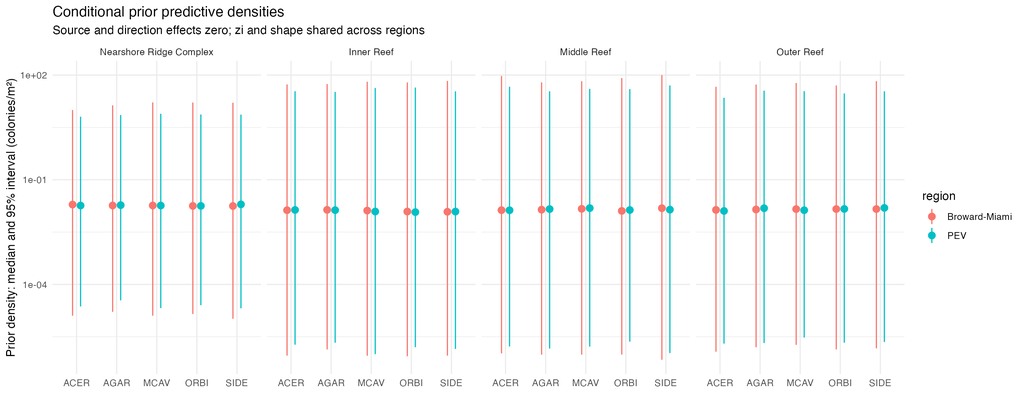

```r
knitr::include_graphics(output_file("prior_predictive_densities.png"))
```

```r
rm(beta_count, beta_zi, beta_shape, prior_log_mu, prior_zi_logit,
   prior_log_shape, prior_log_density, prior_counts, prior_mu_counts, prior_standata)
```

## 6.7 Fit and save the model

`allow_new_fit` defaults to false to protect the saved pilot. Enable it only when intentionally fitting a new model or changing the sampling settings.

Each distinct model, data and sampling specification receives a separate cache folder. The complete `brmsfit` is saved immediately after fitting and reused on subsequent renders. Compilation details below only accommodate the local macOS toolchain; they do not alter the statistical model.

**Saved-fit identification and local compiler compatibility**

```r
fit_settings <- list(
  chains = as.integer(params$chains), warmup = as.integer(params$warmup),
  sampling = as.integer(params$sampling), threads = as.integer(params$threads_per_chain),
  adapt_delta = params$adapt_delta, max_treedepth = as.integer(params$max_treedepth),
  seed = as.integer(params$seed)
)
# Simple R names used in the fitting call below.
chains <- fit_settings$chains
warmup <- fit_settings$warmup
sampling <- fit_settings$sampling
threads_per_chain <- fit_settings$threads
adapt_delta <- fit_settings$adapt_delta
max_treedepth <- fit_settings$max_treedepth
seed <- fit_settings$seed
stan_code <- make_stancode(joint_formula, data = model_data, family = joint_family,
                           prior = joint_priors, threads = threading(fit_settings$threads))
signature_columns <- c("n", "taxon", "class", "Type", "region", "regional", "cell",
                       "dataset", "dir", "direction_group", "transect_area_m2")
fit_signature <- list(data = model_data[signature_columns],
                      priors = as.data.frame(joint_priors), settings = fit_settings,
                      stan = stan_code, brms_version = as.character(packageVersion("brms")))
fit_hash <- digest::digest(fit_signature, algo = "md5")
fit_directory <- output_file("models", fit_hash)
dir.create(fit_directory, recursive = TRUE, showWarnings = FALSE)
fit_file <- file.path(fit_directory, "brms_fit.rds")
cmdstan_directory <- file.path(fit_directory, "cmdstan")
dir.create(cmdstan_directory, showWarnings = FALSE)
saveRDS(fit_signature, file.path(fit_directory, "signature.rds"))
writeLines(stan_code, file.path(fit_directory, "brms_generated_model.stan"))
fit_status <- function(status) {
  jsonlite::write_json(list(status = status, fit = fit_file, hash = fit_hash,
                            chain_output_directory = cmdstan_directory, initialization = 0,
                            settings = fit_settings, prior_version = params$prior_version,
                            regional_distributional_effects = params$regional_distributional_effects,
                            updated = as.character(Sys.time())),
                       output_file("run_status.json"), auto_unbox = TRUE, pretty = TRUE)
}
```

```r
compatible_cpp_options <- function() {
    if (!identical(Sys.info()[["sysname"]], "Darwin"))
        return(list())
    probe_dir <- tempfile("regional-cxx-")
    dir.create(probe_dir)
    on.exit(unlink(probe_dir, recursive = TRUE), add = TRUE)
    source_file <- file.path(probe_dir, "check.cpp")
    executable <- file.path(probe_dir, "check")
    writeLines(c("#include <iostream>", "int main() { std::cout << \"C++ link OK\\n\"; }"), source_file)
    probe <- function(flags = character()) suppressWarnings(system2("clang++", c("-std=c++17", flags,
        shQuote(source_file), "-o", shQuote(executable)), stdout = TRUE, stderr = TRUE))
    default_check <- probe()
    if (is.null(attr(default_check, "status")))
        return(list())
    if (!any(grepl("unknown architecture", default_check, fixed = TRUE)) || !any(grepl("arm64e.x1",
        default_check, fixed = TRUE)))
        stop(paste(default_check, collapse = "\n"), call. = FALSE)
    sdk <- suppressWarnings(system2("xcrun", c("--sdk", "macosx26.5", "--show-sdk-path"), stdout = TRUE,
        stderr = TRUE))
    if (!is.null(attr(sdk, "status")) || length(sdk) != 1L || !dir.exists(sdk))
        stop("The compatible macOS 26.5 SDK is unavailable.", call. = FALSE)
    sdk_flags <- c("-isysroot", shQuote(normalizePath(sdk, mustWork = TRUE)))
    fallback_check <- probe(sdk_flags)
    if (!is.null(attr(fallback_check, "status")))
        stop(paste(fallback_check, collapse = "\n"), call. = FALSE)
    message("Using compatible macOS SDK for this model: ", sdk)
    list(CXX = paste(c("clang++", sdk_flags), collapse = " "))
}

# Keep Stan's iteration messages visible while knitr captures the fit chunk.
# This changes logging only; the expression returns the ordinary brms fit.
with_progress_log <- function(path, expression) {
  progress_connection <- file(path, open = "wt")
  sink(progress_connection, split = TRUE)
  on.exit({ sink(); close(progress_connection) }, add = TRUE)
  force(expression)
}
```

```r
if (file.exists(fit_file)) {
  joint_fit <- readRDS(fit_file)
  fit_status("posterior_reused")
} else {
  if (!isTRUE(params$allow_new_fit)) stop("No matching cache; enable allow_new_fit to run the model.")
  fit_status("compiling_and_sampling")
  compiler_options <- compatible_cpp_options()
  joint_fit <- with_progress_log(file.path(fit_directory, "fit_progress.log"), brm(
    formula = joint_formula,
    data = model_data,
    family = zero_inflated_negbinomial(),
    prior = joint_priors,
    chains = chains, cores = chains,
    iter = warmup + sampling, warmup = warmup,
    threads = threading(threads_per_chain),
    backend = "cmdstanr",
    control = list(adapt_delta = adapt_delta, max_treedepth = max_treedepth),
    seed = seed,
    init = 0,
    output_dir = cmdstan_directory,
    stan_model_args = list(cpp_options = compiler_options),
    refresh = 25,
    file = sub("[.]rds$", "", fit_file), file_refit = "never",
    save_pars = save_pars(all = TRUE)
  ))
  saveRDS(joint_fit, fit_file)
  fit_status("posterior_saved")
}
```

```r
fit_runtime <- tryCatch(as.data.frame(rstan::get_elapsed_time(joint_fit$fit)),
                        error = function(e) NULL)
if (!is.null(fit_runtime)) {
  fit_runtime$chain <- seq_len(nrow(fit_runtime))
  write_csv(fit_runtime, output_file("fit_runtime_by_chain.csv"))
}
```

## 6.8 Expected-density predictions

Expected density includes zero inflation: $E[n/A]=(1-zi)\mu/A$. PEV predictions explicitly select the PEV cells; regional predictions explicitly select Broward–Miami cells. Both use the same joint posterior. Survey/source effects remain included and direction effects are set to zero, matching the original conditional prediction convention. Zero direction is not an arithmetic average of the north and south predicted densities.

```r
# Keep the original manuscript convention: survey effects included, direction
# effects zero. The region indicator is always rebuilt from an explicit argument.
source_effects <- ~ (1 + Type | dataset) + (1 | dataset:taxon:class)
density_effects <- if (params$regional_distributional_effects) {
  ~ (1 + Type | dataset) + (1 | dataset:taxon:class) + (0 + regional | cell)
} else source_effects
prediction_audit <- tibble(purpose = character(), region = character(), rows = integer(),
                           datasets = character(), area_m2 = numeric())

prediction_data <- function(prepared, newdata, region) {
  stopifnot(length(region) == 1L, region %in% c("PEV", "Broward-Miami"))
  d <- as.data.frame(newdata)
  d$region <- factor(rep(region, nrow(d)), levels = levels(model_data$region))
  d$regional <- as.integer(d$region == "Broward-Miami")
  k <- match(paste(d$taxon, d$class, d$Type),
             paste(prepared$grid$taxon, prepared$grid$class, prepared$grid$Type))
  stopifnot(!anyNA(k))
  d$cell <- factor(k, levels = prepared$grid$cell_id, labels = levels(model_data$cell))
  for (v in c("taxon", "class", "Type", "dataset")) {
    d[[v]] <- factor(d[[v]], levels = levels(model_data[[v]]))
  }
  # An observed placeholder is supplied only for brms data validation. Direction
  # effects are excluded from mu below, so its identity cannot affect density.
  reference_group <- as.character(model_data$direction_group[which(model_data$region == region)[1]])
  d$direction_group <- factor(rep(reference_group, nrow(d)), levels = levels(model_data$direction_group))
  d$transect_area_m2 <- 1
  stopifnot(!anyNA(d[c("taxon", "class", "Type", "dataset", "cell", "region")]),
            all(as.character(d$region) == region),
            all(d$regional == as.integer(region == "Broward-Miami")))
  d
}

expected_density_draws <- function(prepared, fit, newdata, region,
                                   purpose = "diagnostics_or_comparisons") {
  d <- prediction_data(prepared, newdata, region)
  # Retain source effects and, when fitted, regional zi/shape slopes.
  # Direction effects are excluded in both model variants.
  result <- posterior_epred(fit, newdata = d, re_formula = density_effects)
  prediction_audit <<- bind_rows(prediction_audit,
    tibble(purpose = purpose, region = region, rows = nrow(d),
           datasets = paste(sort(unique(as.character(d$dataset))), collapse = ";"), area_m2 = 1))
  result
}

summarize_density_draws <- function(draw_matrix, g) cbind(g, as.data.frame(t(apply(draw_matrix,
  2, function(x) c(mean = mean(x), median = median(x), lower = unname(quantile(x, 0.025)),
                  upper = unname(quantile(x, 0.975)), maximum = max(x),
                  largest_draw_share = max(x)/sum(x))))))
```

```r
joint_epred_draws <- function(newdata, region = "PEV", ndraws = NULL) {
  # This interface feeds manuscript figures/tables only; regional comparisons
  # call expected_density_draws() separately with an explicit regional target.
  stopifnot(identical(region, "PEV"))
  prediction_matrix <- expected_density_draws(prepared, joint_fit, newdata, region,
                                             purpose = "manuscript")
  draw_ids <- seq_len(nrow(prediction_matrix))
  if (!is.null(ndraws) && ndraws < length(draw_ids)) {
    set.seed(params$seed)
    draw_ids <- sort(sample(draw_ids, ndraws))
    prediction_matrix <- prediction_matrix[draw_ids, , drop = FALSE]
  }
  draws_per_row <- nrow(prediction_matrix)
  tibble(newdata[rep(seq_len(nrow(newdata)), each = draws_per_row), , drop = FALSE]) %>%
    mutate(.row = rep(seq_len(nrow(newdata)), each = draws_per_row),
           .draw = rep(draw_ids, times = nrow(newdata)),
           .epred = as.vector(prediction_matrix))
}
```

## 6.9 Habitat-area weights for the sensitivity comparison

The primary regional comparison and temporal trends give each modeled reef habitat weight 1/4. The following area calculations are used only for the own-area sensitivity results. That alternative weights each habitat by its area divided by the region’s total NRC + IR + MR + OR area, allowing habitat composition as well as habitat-specific density to contribute to the regional contrast. The primary equal-habitat comparison standardizes habitat composition between regions and years; neither calculation averages survey sites.

PEV areas are the existing unrounded project/monitoring-area habitat totals from Table A1 (Scenario 2, NMFS consideration areas and the rest of the monitoring area). Broader Broward–Miami areas use the complete FDEP habitat map’s `Region = "Broward-Miami"`, outside the 1,200 m north/south PEV band. Biscayne, Deerfield, Palm Beach and Martin map regions are excluded. The PEV project footprint and the model’s classification band are not identical geometries. These area choices reproduce the reviewed own-area sensitivity test; they do not change observation membership or habitat assignments.

Both area calculations pool Artificial with NRC and Aggregated Patch Reef with OR, and exclude other habitat classes. The regional input contains all 1,868 Broward–Miami source polygons, rather than just those intersecting survey sites. Within-class regional overlaps are dissolved; small areas with conflicting reef-class labels are omitted from all regional classes. PEV areas retain the existing Table A1 convention. Map boundaries and areas are treated as fixed; mapping uncertainty is not propagated into the intervals.

```r
area_habitats <- c("Nearshore Ridge Complex", "Inner Reef", "Middle Reef", "Outer Reef")
area_source <- "data/spatial/drm_regional_habitat/broward_miami_full_region.gpkg"
area_provenance <- read_json(
  "data/spatial/drm_regional_habitat/broward_miami_full_region_provenance.json",
  simplifyVector = TRUE)
stopifnot(identical(digest(file = area_source, algo = "sha256"), area_provenance$sha256))
regional_area_source <- st_read(area_source, quiet = TRUE) %>%
  st_zm(drop = TRUE) %>% st_transform(32617) %>% st_make_valid()
regional_area_source <- st_sf(st_drop_geometry(regional_area_source),
                             geometry = st_geometry(regional_area_source))
stopifnot(nrow(regional_area_source) == 1868L,
          all(regional_area_source$Region == "Broward-Miami"))

# Check that the complete map region covers every raw Broward–Miami DRM site.
area_site_audit <- regional_site_coordinates %>%
  st_as_sf(coords = c("longitude", "latitude"), crs = 4326) %>% st_transform(32617) %>%
  st_join(select(regional_area_source, map_region = Region)) %>%
  st_drop_geometry() %>% distinct(site, map_region)
stopifnot(n_distinct(area_site_audit$site) == 138L,
          !anyNA(area_site_audit$map_region), all(area_site_audit$map_region == "Broward-Miami"))
write_csv(area_site_audit, output_file("regional_habitat_area_site_audit.csv"))

regional_dissolved <- regional_area_source %>%
  mutate(Type = case_when(Type == "Artificial" ~ area_habitats[1],
                         Type == "Aggregated Patch Reef" ~ area_habitats[4], TRUE ~ Type)) %>%
  filter(Type %in% area_habitats) %>% group_by(Type) %>% summarize(.groups = "drop")
cross_class_intersections <- lapply(combn(seq_len(nrow(regional_dissolved)), 2,
  simplify = FALSE), function(pair) suppressWarnings(st_intersection(
    st_geometry(regional_dissolved[pair[1], ]), st_geometry(regional_dissolved[pair[2], ]))))
ambiguous_reef_area <- st_union(do.call(c, cross_class_intersections))
ambiguous_m2 <- sum(as.numeric(st_area(ambiguous_reef_area)))
regional_union_m2 <- sum(as.numeric(st_area(st_union(regional_dissolved))))
stopifnot(ambiguous_m2 / regional_union_m2 < 0.001)
regional_clean <- suppressWarnings(st_difference(regional_dissolved, ambiguous_reef_area))
stopifnot(abs(sum(as.numeric(st_area(regional_clean))) -
  sum(as.numeric(st_area(st_union(regional_clean))))) < 0.01)

area_bbox <- st_bbox(regional_clean)
pev_area_band <- st_as_sfc(st_bbox(c(xmin = area_bbox[["xmin"]] - 1,
  xmax = area_bbox[["xmax"]] + 1, ymin = geographic_rule$pev_ymin_m,
  ymax = geographic_rule$pev_ymax_m), crs = st_crs(regional_clean)))
regional_area_polygons <- suppressWarnings(st_difference(regional_clean, pev_area_band))
regional_habitat_weights <- bind_rows(
  area_summary %>% group_by(Type) %>% summarize(area_m2 = sum(total_area_m2), .groups = "drop") %>%
    mutate(region = "PEV"),
  regional_area_polygons %>% mutate(area_m2 = as.numeric(st_area(geometry))) %>%
    st_drop_geometry() %>% mutate(region = "Broward-Miami")
) %>% group_by(region) %>% mutate(weight = area_m2 / sum(area_m2)) %>% ungroup() %>%
  mutate(habitat = c("NRC", "IR", "MR", "OR")[match(Type, area_habitats)],
         area_km2 = area_m2 / 1e6) %>% arrange(region, match(Type, area_habitats))
stopifnot(nrow(regional_habitat_weights) == 8L, all(regional_habitat_weights$weight > 0),
  all(abs(tapply(regional_habitat_weights$weight, regional_habitat_weights$region, sum) - 1) < 1e-12))
write_csv(regional_habitat_weights, output_file("regional_habitat_area_weights.csv"))
write_csv(data.frame(ambiguous_map_area_m2 = ambiguous_m2,
  regional_source_union_m2 = regional_union_m2,
  ambiguous_fraction = ambiguous_m2 / regional_union_m2,
  treatment = "Omitted from every regional reef class; observations unchanged"),
  output_file("regional_habitat_area_overlap_audit.csv"))
st_write(regional_area_polygons, processed_file("regional_habitat_area_polygons.gpkg"),
         delete_dsn = TRUE, quiet = TRUE)

habitat_area_weights <- function(types, target_region) {
  w <- filter(regional_habitat_weights, region == target_region)
  answer <- w$weight[match(as.character(types), w$Type)]
  stopifnot(!anyNA(answer))
  answer
}
show_table(regional_habitat_weights %>% select(region, habitat, area_km2, weight), digits = 4)
```

| region | habitat | area_km2 | weight |
| --- | --- | --- | --- |
| Broward-Miami | NRC | 46.1906 | 0.5785 |
| Broward-Miami | IR | 11.0093 | 0.1379 |
| Broward-Miami | MR | 8.7759 | 0.1099 |
| Broward-Miami | OR | 13.8739 | 0.1738 |
| PEV | NRC | 2.1585 | 0.5390 |
| PEV | IR | 0.6218 | 0.1553 |
| PEV | MR | 0.4371 | 0.1091 |
| PEV | OR | 0.7874 | 0.1966 |

## 6.10 Sampling diagnostics and posterior predictive checks

Checks retain each observation’s searched area, source, region and direction. Expected densities are independently checked against native brms predictions. PPCs check density, zero fraction, positive sites and maximum counts by region/source/taxon/class/habitat. No posterior draws are trimmed by density.

```r
distributional_diagnostics <- function(prepared, fit) {
  nd <- mutate(prepared$grid, dataset = "drm24")
  draw_shape <- dim(posterior::as_draws_array(fit))[1:2]
  rows <- list()
  for (region in c("PEV", "Broward-Miami")) {
    d <- prediction_data(prepared, nd, region)
    components <- list(
      log_mu = posterior_linpred(fit, newdata = d, re_formula = source_effects),
      zi_logit = posterior_linpred(fit, newdata = d, dpar = "zi", re_formula = NULL),
      log_shape = posterior_linpred(fit, newdata = d, dpar = "shape", re_formula = NULL))
    for (component in names(components)) {
      x <- components[[component]]
      colnames(x) <- paste0("cell", seq_len(ncol(x)))
      ar <- array(x, dim = c(draw_shape, ncol(x)), dimnames = list(NULL, NULL, colnames(x)))
      stats <- posterior::summarise_draws(posterior::as_draws_array(ar),
                 "mean", "mcse_mean", "rhat", "ess_bulk", "ess_tail")
      rows[[paste(region, component)]] <- bind_cols(prepared$grid, stats) %>%
        mutate(region = region, component = component)
    }
  }
  bind_rows(rows) %>% mutate(regional_full_survey_support = region == "PEV" | class == ">4cm" |
                               taxon %in% c("MCAV", "MEAN", "MUSS", "FAVI"))
}

summarize_joint_fit <- function(prepared, fit, output_dir) {
  draws <- posterior::as_draws_array(fit)
  parameters <- posterior::summarise_draws(draws)
  sampler <- rstan::get_sampler_params(fit$fit, inc_warmup = FALSE)
  diagnostics <- data.frame(
    max_rhat = max(parameters$rhat, na.rm = TRUE),
    min_bulk_ess = min(parameters$ess_bulk, na.rm = TRUE),
    min_tail_ess = min(parameters$ess_tail, na.rm = TRUE),
    divergences = sum(vapply(sampler, function(x) sum(x[, "divergent__"]), numeric(1))),
    treedepth_hits = sum(vapply(sampler, function(x) sum(x[, "treedepth__"] >= fit_settings$max_treedepth), numeric(1)))
  )
  diagnostics$pass <- with(diagnostics, max_rhat < 1.01 & min_bulk_ess > 400 &
                            min_tail_ess > 400 & divergences == 0 & treedepth_hits == 0)
  write_csv(arrange(parameters, desc(rhat)), file.path(output_dir, "parameter_diagnostics.csv"))
  write_csv(diagnostics, file.path(output_dir, "sampling_diagnostics.csv"))
  K <- nrow(prepared$grid)
  nd <- mutate(prepared$grid, dataset = "drm24")
  den <- cbind(expected_density_draws(prepared, fit, nd, "PEV"),
               expected_density_draws(prepared, fit, nd, "Broward-Miami"))
  grid <- bind_rows(mutate(nd, region = "PEV"), mutate(nd, region = "Broward-Miami"))
  density <- left_join(summarize_density_draws(den, grid),
    prepared$counts %>% filter(dataset == "drm24") %>%
      group_by(region, taxon, class, Type) %>%
      summarise(rows = n(), positive_rows = sum(n > 0), colonies = sum(n),
                searched_m2 = sum(transect_area_m2), .groups = "drop"),
    by = c("region", "taxon", "class", "Type"))
  write_csv(density, file.path(output_dir, "density_2024_all_cells.csv"))
  # Diagnose each habitat cell as well as the habitat-averaged estimates below.
  cell_labels <- with(grid, paste(taxon, class, Type, region, sep = "|"))
  cell_array <- array(den, dim = c(dim(draws)[1:2], ncol(den)),
                      dimnames = list(NULL, NULL, cell_labels))
  cell_diagnostics <- posterior::summarise_draws(posterior::as_draws_array(cell_array),
    "mean", "mcse_mean", "rhat", "ess_bulk", "ess_tail") %>%
    mutate(relative_mcse = mcse_mean / pmax(abs(mean), 1e-12)) %>%
    left_join(mutate(grid, variable = cell_labels), by = "variable") %>%
    mutate(regional_full_survey_support = region == "PEV" | class == ">4cm" |
             taxon %in% c("MCAV", "MEAN", "MUSS", "FAVI"))
  write_csv(cell_diagnostics, file.path(output_dir, "density_cell_diagnostics.csv"))

  # Split each chain into two consecutive blocks to expose unstable tail means.
  iterations <- dim(draws)[1]
  chain_blocks <- bind_rows(lapply(seq_len(dim(draws)[2]), function(chain) {
    bind_rows(lapply(split(seq_len(iterations), ceiling(seq_len(iterations) / ceiling(iterations/2))),
      function(i) {
        block <- den[(chain - 1L) * iterations + i, , drop = FALSE]
        data.frame(variable = cell_labels, chain = chain, first_iteration = min(i),
          last_iteration = max(i), mean = colMeans(block),
          median = apply(block, 2, median),
          largest_draw_share = apply(block, 2, max) / colSums(block))
      }))
  }))
  write_csv(chain_blocks, file.path(output_dir, "density_chain_block_stability.csv"))
  tail_review <- density %>%
    filter(region == "PEV" | class == ">4cm" | taxon %in% c("MCAV", "MEAN", "MUSS", "FAVI")) %>%
    mutate(mean_to_median = mean/median, maximum_to_upper_95 = maximum/upper) %>%
    arrange(desc(largest_draw_share))
  write_csv(tail_review, file.path(output_dir, "density_tail_review.csv"))
  average <- function(z, target_region) vapply(seq_len(nrow(prepared$tc)), function(i) {
    cells <- prepared$grid$tc_id == i
    rowMeans(z[, cells, drop = FALSE])
  }, numeric(nrow(z)))
  pev <- average(den[, seq_len(K)], "PEV")
  regional <- average(den[, K + seq_len(K)], "Broward-Miami")
  contrast <- mutate(summarize_density_draws(pev - regional, prepared$tc),
    probability_pev_gt_regional = colMeans(pev > regional),
    probability_pev_lt_regional = colMeans(pev < regional))
  eligible <- prepared$tc$class == ">4cm" | prepared$tc$taxon %in% c("MCAV", "FAVI", "MEAN", "MUSS")
  contrast$regional_full_survey_support <- eligible
  for (v in c("mean", "median", "lower", "upper", "maximum", "largest_draw_share",
              "probability_pev_gt_regional", "probability_pev_lt_regional")) contrast[[v]][!eligible] <- NA
  write_csv(contrast, file.path(output_dir, "habitat_averaged_2024_contrasts.csv"))
  z <- cbind(pev, regional, pev - regional)
  colnames(z) <- c(paste(prepared$tc$taxon, prepared$tc$class, "PEV", sep = ":"),
                   paste(prepared$tc$taxon, prepared$tc$class, "regional", sep = ":"),
                   paste(prepared$tc$taxon, prepared$tc$class, "difference", sep = ":"))
  ar <- array(z, dim = c(dim(draws)[1:2], ncol(z)), dimnames = list(NULL, NULL, colnames(z)))
  derived <- posterior::summarise_draws(posterior::as_draws_array(ar),
    "mean", "mcse_mean", "rhat", "ess_bulk", "ess_tail") %>%
    mutate(relative_mcse = mcse_mean/pmax(abs(mean), 1e-12))
  write_csv(derived, file.path(output_dir, "prediction_diagnostics.csv"))
  component_checks <- distributional_diagnostics(prepared, fit)
  write_csv(component_checks, file.path(output_dir, "distributional_prediction_diagnostics.csv"))
```

```r
  # PPCs include each observed region, source, direction and actual searched area.
  d <- prepared$counts
  set.seed(20261028)
  take <- sort(sample(seq_len(nrow(posterior::as_draws_matrix(fit))), 250))
  yrep <- posterior_predict(fit, newdata = d, re_formula = NULL, draw_ids = take)
  stopifnot(all(is.finite(yrep)))
  # Verify the fitted count likelihood independently in R, including effort,
  # region, source, direction, zero inflation and negative-binomial shape.
  audit_draws <- take[round(seq(1, length(take), length.out = 10))]
  count_eta <- posterior_linpred(fit, newdata = d, re_formula = NULL, draw_ids = audit_draws)
  count_zi <- posterior_linpred(fit, newdata = d, dpar = "zi", re_formula = NULL, draw_ids = audit_draws)
  count_shape <- posterior_linpred(fit, newdata = d, dpar = "shape", re_formula = NULL,
                                   transform = TRUE, draw_ids = audit_draws)
  manual_log_lik <- matrix(dnbinom(rep(d$n, each = length(audit_draws)),
                                   mu = exp(count_eta), size = count_shape, log = TRUE),
                            nrow = length(audit_draws)) + plogis(-count_zi, log.p = TRUE)
  zero_columns <- d$n == 0
  a <- plogis(count_zi[, zero_columns, drop = FALSE], log.p = TRUE)
  b <- manual_log_lik[, zero_columns, drop = FALSE]
  m <- pmax(a, b)
  manual_log_lik[, zero_columns] <- m + log(exp(a - m) + exp(b - m))
  native_log_lik <- log_lik(fit, newdata = d, re_formula = NULL, draw_ids = audit_draws)
  likelihood_error <- max(abs(manual_log_lik - native_log_lik))
  write_csv(data.frame(maximum_absolute_log_likelihood_error = likelihood_error,
                       pass = likelihood_error < 1e-8), file.path(output_dir, "likelihood_validation.csv"))
  stopifnot(likelihood_error < 1e-8)
  rm(count_eta, count_zi, count_shape, manual_log_lik, native_log_lik, a, b, m)
  groups <- split(seq_len(nrow(d)), interaction(d$region, d$dataset, d$taxon, d$class, d$Type, drop = TRUE))
  ppc <- bind_rows(lapply(groups, function(ix) {
    observed <- c(density = mean(d$n[ix]/d$transect_area_m2[ix]),
                  zero_fraction = mean(d$n[ix] == 0), maximum = max(d$n[ix]),
                  positive_sites = sum(d$n[ix] > 0))
    predicted <- list(
      density = rowMeans(sweep(yrep[, ix, drop = FALSE], 2, d$transect_area_m2[ix], "/")),
      zero_fraction = rowMeans(yrep[, ix, drop = FALSE] == 0),
      maximum = apply(yrep[, ix, drop = FALSE], 1, max),
      positive_sites = rowSums(yrep[, ix, drop = FALSE] > 0))
    bind_rows(lapply(names(predicted), function(metric) {
      x <- predicted[[metric]]
      lo <- unname(quantile(x, 0.025)); hi <- unname(quantile(x, 0.975))
      data.frame(d[ix[1], c("region", "dataset", "taxon", "class", "Type")],
                 metric = metric, observed = observed[[metric]], predicted_median = median(x),
                 lower = lo, upper = hi, outside_95 = observed[[metric]] < lo | observed[[metric]] > hi)
    }))
  }))
  write_csv(ppc, file.path(output_dir, "posterior_predictive_checks.csv"))
  ppc_summary <- ppc %>% group_by(region, dataset, class, metric) %>%
    summarize(cells = n(), outside_95 = sum(outside_95), .groups = "drop")
  write_csv(ppc_summary, file.path(output_dir, "posterior_predictive_check_summary.csv"))

  # Independent checks against brms's full expected-value calculation.
  audit <- d[!duplicated(d[c("region", "taxon", "class", "Type")]), , drop = FALSE]
  audit$transect_area_m2 <- 1
  mu_full <- posterior_linpred(fit, newdata = audit, re_formula = NULL)
  mu_zero_direction <- posterior_linpred(fit, newdata = audit, re_formula = source_effects)
  zi <- posterior_linpred(fit, newdata = audit, dpar = "zi", re_formula = NULL)
  epred_full <- posterior_epred(fit, newdata = audit, re_formula = NULL)
  expected <- exp(mu_zero_direction + plogis(-zi, log.p = TRUE))
  independent <- epred_full * exp(mu_zero_direction - mu_full)
  native_conditional <- posterior_epred(fit, newdata = audit, re_formula = density_effects)
  error <- max(abs(expected - independent)/pmax(1, abs(independent)),
               abs(native_conditional - independent)/pmax(1, abs(independent)))
  # Changing an excluded direction identifier must not change predictions.
  validation <- data.frame(
    check = c("Conditional density matches brms expected value after removing direction",
              "PEV prediction data explicitly encode PEV and regional=0",
              "Regional prediction data explicitly encode Broward-Miami and regional=1"),
    pass = c(error < 1e-10,
             all(prediction_data(prepared, nd, "PEV")$regional == 0L),
             all(prediction_data(prepared, nd, "Broward-Miami")$regional == 1L)))
  stopifnot(all(validation$pass))
  write_csv(validation, file.path(output_dir, "prediction_validation.csv"))
  plot_data <- filter(ppc, dataset == "drm24", metric == "density")
  g <- ggplot(plot_data, aes(observed, predicted_median, color = region)) +
    geom_abline(slope = 1, intercept = 0, color = "gray60") +
    geom_errorbar(aes(ymin = lower, ymax = upper), alpha = 0.25, width = 0) +
    geom_point(size = 1) + facet_grid(class ~ Type, scales = "free") + theme_minimal() +
    labs(x = "Observed site-mean colonies/m²", y = "Replicated median and 95% interval",
         title = "2024 posterior predictive checks")
  ggsave(file.path(output_dir, "posterior_predictive_density.png"), g,
         width = 12, height = 6, dpi = 250, bg = "white")
  result <- list(diagnostic = diagnostics, density = density, contrast = contrast,
                 derived = derived, components = component_checks, ppc = ppc,
                 posterior_file = fit_file, hash = fit_hash)
  saveRDS(result, file.path(output_dir, "evaluation.rds"))
  result
}
```

```r
joint_evaluation <- summarize_joint_fit(prepared, joint_fit, output_dir)
show_table(joint_evaluation$diagnostic)
```

| max_rhat | min_bulk_ess | min_tail_ess | divergences | treedepth_hits | pass |
| --- | --- | --- | --- | --- | --- |
| 1.0189 | 266.3071 | 531.3922 | 0 | 0 | FALSE |

```r
show_table(head(joint_evaluation$derived[order(-joint_evaluation$derived$rhat), ], 15))
```

| variable | mean | mcse_mean | rhat | ess_bulk | ess_tail | relative_mcse |
| --- | --- | --- | --- | --- | --- | --- |
| EFAS:>4cm:PEV | 0.0070 | 0.0000 | 1.0036 | 6505.302 | 3150.854 | 0.0051 |
| DLAB:>4cm:difference | -0.0002 | 0.0000 | 1.0032 | 4944.103 | 2966.089 | 0.0891 |
| PORI:<4cm:difference | -0.3563 | 0.0107 | 1.0024 | 4988.486 | 2574.846 | 0.0299 |
| MADR:>4cm:PEV | 0.0199 | 0.0001 | 1.0022 | 5434.693 | 3233.184 | 0.0068 |
| DSTO:>4cm:difference | -0.0027 | 0.0001 | 1.0018 | 4303.383 | 2779.426 | 0.0225 |
| PORI:<4cm:regional | 0.4936 | 0.0107 | 1.0018 | 4862.807 | 2616.873 | 0.0217 |
| CNAT:>4cm:difference | -0.0025 | 0.0000 | 1.0016 | 4763.065 | 3476.957 | 0.0101 |
| AGAR:>4cm:PEV | 0.0146 | 0.0001 | 1.0016 | 6335.461 | 3487.669 | 0.0049 |
| EFAS:>4cm:difference | -0.0078 | 0.0001 | 1.0016 | 4956.132 | 3370.999 | 0.0111 |
| MCAV:<4cm:difference | 0.0212 | 0.0003 | 1.0014 | 6251.114 | 3197.910 | 0.0151 |
| SOLE:>4cm:difference | 0.0002 | 0.0001 | 1.0014 | 5554.036 | 2969.394 | 0.4625 |
| MYCE:>4cm:regional | 0.0057 | 0.0000 | 1.0014 | 3970.156 | 3602.273 | 0.0074 |
| SINT:<4cm:difference | -0.0859 | 0.0050 | 1.0014 | 5122.622 | 2839.756 | 0.0582 |
| MADR:>4cm:difference | 0.0083 | 0.0002 | 1.0013 | 5152.023 | 3234.553 | 0.0189 |
| SIDE:<4cm:difference | -0.8637 | 0.0420 | 1.0013 | 4550.953 | 2570.989 | 0.0486 |

```r
show_table(joint_evaluation$components %>% filter(regional_full_survey_support) %>%
  group_by(component, region) %>% summarize(max_rhat = max(rhat),
    min_bulk_ess = min(ess_bulk), min_tail_ess = min(ess_tail), .groups = "drop"), digits = 3)
```

| component | region | max_rhat | min_bulk_ess | min_tail_ess |
| --- | --- | --- | --- | --- |
| log_mu | Broward-Miami | 1.008 | 619.178 | 1005.869 |
| log_mu | PEV | 1.009 | 450.960 | 988.109 |
| log_shape | Broward-Miami | 1.020 | 399.716 | 871.075 |
| log_shape | PEV | 1.020 | 399.716 | 871.075 |
| zi_logit | Broward-Miami | 1.021 | 330.798 | 644.532 |
| zi_logit | PEV | 1.021 | 330.798 | 644.532 |

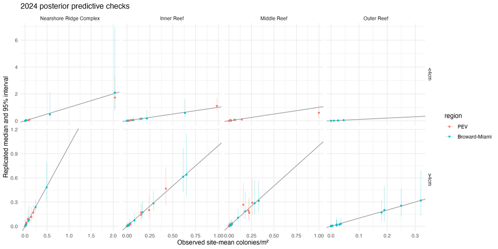

```r
knitr::include_graphics(output_file("posterior_predictive_density.png"))
```

```r
show_table(joint_evaluation$ppc %>%
  filter(dataset == "drm24", taxon == "ACER", class == ">4cm") %>%
  select(region, Type, metric, observed, predicted_median, lower, upper, outside_95), digits = 4)
```

| region | Type | metric | observed | predicted_median | lower | upper | outside_95 |
| --- | --- | --- | --- | --- | --- | --- | --- |
| PEV | Nearshore Ridge Complex | density | 0.0111 | 0.0139 | 0.0000 | 0.0775 | FALSE |
| PEV | Nearshore Ridge Complex | zero_fraction | 0.8889 | 0.8333 | 0.6236 | 1.0000 | FALSE |
| PEV | Nearshore Ridge Complex | maximum | 6.0000 | 6.0000 | 0.0000 | 36.0000 | FALSE |
| PEV | Nearshore Ridge Complex | positive_sites | 2.0000 | 3.0000 | 0.0000 | 6.7750 | FALSE |
| Broward-Miami | Nearshore Ridge Complex | density | 0.0893 | 0.0804 | 0.0250 | 0.2586 | FALSE |
| Broward-Miami | Nearshore Ridge Complex | zero_fraction | 0.7429 | 0.7857 | 0.6714 | 0.8857 | FALSE |
| Broward-Miami | Nearshore Ridge Complex | maximum | 31.0000 | 33.5000 | 9.2250 | 145.0500 | FALSE |
| Broward-Miami | Nearshore Ridge Complex | positive_sites | 18.0000 | 15.0000 | 8.0000 | 23.0000 | FALSE |
| PEV | Inner Reef | density | 0.0000 | 0.0000 | 0.0000 | 0.0083 | FALSE |
| PEV | Inner Reef | zero_fraction | 1.0000 | 1.0000 | 0.8333 | 1.0000 | FALSE |
| PEV | Inner Reef | maximum | 0.0000 | 0.0000 | 0.0000 | 3.0000 | FALSE |
| PEV | Inner Reef | positive_sites | 0.0000 | 0.0000 | 0.0000 | 2.0000 | FALSE |
| Broward-Miami | Inner Reef | density | 0.0000 | 0.0000 | 0.0000 | 0.0056 | FALSE |
| Broward-Miami | Inner Reef | zero_fraction | 1.0000 | 1.0000 | 0.9444 | 1.0000 | FALSE |
| Broward-Miami | Inner Reef | maximum | 0.0000 | 0.0000 | 0.0000 | 2.0000 | FALSE |
| Broward-Miami | Inner Reef | positive_sites | 0.0000 | 0.0000 | 0.0000 | 1.0000 | FALSE |
| PEV | Middle Reef | density | 0.0000 | 0.0000 | 0.0000 | 0.0042 | FALSE |
| PEV | Middle Reef | zero_fraction | 1.0000 | 1.0000 | 0.8333 | 1.0000 | FALSE |
| PEV | Middle Reef | maximum | 0.0000 | 0.0000 | 0.0000 | 1.0000 | FALSE |
| PEV | Middle Reef | positive_sites | 0.0000 | 0.0000 | 0.0000 | 1.0000 | FALSE |
| Broward-Miami | Middle Reef | density | 0.0000 | 0.0000 | 0.0000 | 0.0000 | FALSE |
| Broward-Miami | Middle Reef | zero_fraction | 1.0000 | 1.0000 | 1.0000 | 1.0000 | FALSE |
| Broward-Miami | Middle Reef | maximum | 0.0000 | 0.0000 | 0.0000 | 0.0000 | FALSE |
| Broward-Miami | Middle Reef | positive_sites | 0.0000 | 0.0000 | 0.0000 | 0.0000 | FALSE |
| Broward-Miami | Outer Reef | density | 0.0000 | 0.0000 | 0.0000 | 0.0078 | FALSE |
| Broward-Miami | Outer Reef | zero_fraction | 1.0000 | 1.0000 | 0.8450 | 1.0000 | FALSE |
| Broward-Miami | Outer Reef | maximum | 0.0000 | 0.0000 | 0.0000 | 0.7750 | FALSE |
| Broward-Miami | Outer Reef | positive_sites | 0.0000 | 0.0000 | 0.0000 | 0.7750 | FALSE |

```r
show_table(read_csv(output_file("density_tail_review.csv"), show_col_types = FALSE) %>%
  slice_head(n = 12) %>%
  mutate(largest_draw_percent = 100 * largest_draw_share) %>%
  select(taxon, class, Type, region, mean, median, upper, maximum, largest_draw_percent), digits = 4)
```

| taxon | class | Type | region | mean | median | upper | maximum | largest_draw_percent |
| --- | --- | --- | --- | --- | --- | --- | --- | --- |
| ACER | >4cm | Middle Reef | Broward-Miami | 0.0023 | 0.0001 | 0.0022 | 5.6364 | 61.3051 |
| ACER | <4cm | Inner Reef | PEV | 0.0001 | 0.0000 | 0.0005 | 0.1691 | 33.7440 |
| ACER | >4cm | Middle Reef | PEV | 0.0006 | 0.0001 | 0.0033 | 0.1492 | 6.2276 |
| ORBI | <4cm | Inner Reef | PEV | 0.0001 | 0.0000 | 0.0004 | 0.0178 | 5.8280 |
| ACER | <4cm | Outer Reef | PEV | 0.0000 | 0.0000 | 0.0002 | 0.0083 | 5.2960 |
| ORBI | <4cm | Middle Reef | PEV | 0.0002 | 0.0001 | 0.0011 | 0.0459 | 4.8493 |
| MADR | >4cm | Nearshore Ridge Complex | Broward-Miami | 0.0023 | 0.0012 | 0.0103 | 0.2954 | 3.1638 |
| ACER | >4cm | Inner Reef | Broward-Miami | 0.0006 | 0.0003 | 0.0024 | 0.0704 | 3.1171 |
| DLAB | >4cm | Middle Reef | Broward-Miami | 0.0016 | 0.0008 | 0.0076 | 0.1359 | 2.1289 |
| ACER | <4cm | Middle Reef | PEV | 0.0001 | 0.0000 | 0.0005 | 0.0067 | 1.9117 |
| MADR | <4cm | Middle Reef | PEV | 0.0018 | 0.0011 | 0.0073 | 0.1334 | 1.8356 |
| ACER | >4cm | Outer Reef | Broward-Miami | 0.0002 | 0.0001 | 0.0010 | 0.0176 | 1.8328 |

### 6.10.1 Bayesian R-squared and original posterior predictive checks

These checks retain the original analysis framework. Bayesian R-squared uses colony counts, as in the original `bayes_R2()` call. Posterior predictive statistics use densities (counts divided by each observation’s actual searched area). Replications retain every observation’s dataset, region and direction and include all fitted random effects; they are not the direction-zero, 1 m² predictions used for manuscript density estimates.

The global checks compare mean, variance, zero proportion, skewness and a chi-squared discrepancy. Grouped checks compare mean, standard deviation, zero proportion and skewness within taxon–size-class–habitat combinations. Both are reported for all observations and separately for PEV and Broward–Miami. The existing finer checks by dataset and region remain above.

```r
# Reuse the saved posterior: these calculations never fit a new model.
# R² uses all 4,000 draws. PPCs use 1,000 selected draws, as in the original.
stopifnot(requireNamespace("e1071", quietly = TRUE))
check_draw_count <- min(1000L, posterior::ndraws(joint_fit))
check_signature <- list(
  fit_hash = fit_hash, draws = check_draw_count, seed = 124L,
  version = "original_framework_v1", brms = as.character(packageVersion("brms"))
)
check_cache <- processed_file(paste0("original_framework_draws_",
                                     digest::digest(check_signature), ".rds"))
if (file.exists(check_cache)) {
  original_check_draws <- readRDS(check_cache)
  stopifnot(identical(original_check_draws$signature, check_signature))
} else {
  # Native brms R², using the fitted count response and all random effects.
  r2_draws <- as.numeric(bayes_R2(joint_fit, summary = FALSE, re_formula = NULL))
  set.seed(124)
  check_draw_ids <- sort(sample(seq_len(posterior::ndraws(joint_fit)), check_draw_count))
  replicated_counts <- posterior_predict(
    joint_fit, newdata = model_data, re_formula = NULL, draw_ids = check_draw_ids
  )
  expected_counts <- posterior_epred(
    joint_fit, newdata = model_data, re_formula = NULL, draw_ids = check_draw_ids
  )
  original_check_draws <- list(signature = check_signature, r2 = r2_draws,
    draw_ids = check_draw_ids, replicated_counts = replicated_counts,
    expected_counts = expected_counts)
  saveRDS(original_check_draws, check_cache)
}
stopifnot(identical(as.numeric(model_data$n), as.numeric(joint_fit$data$n)),
          identical(as.numeric(model_data$transect_area_m2),
                    as.numeric(joint_fit$data$transect_area_m2)),
          all(is.finite(original_check_draws$expected_counts)),
          all(original_check_draws$expected_counts > 0),
          all(is.finite(original_check_draws$replicated_counts)),
          ncol(original_check_draws$replicated_counts) == nrow(model_data))
observed_density <- model_data$n / model_data$transect_area_m2
replicated_density <- sweep(original_check_draws$replicated_counts, 2,
                             model_data$transect_area_m2, "/")
expected_density <- sweep(original_check_draws$expected_counts, 2,
                           model_data$transect_area_m2, "/")
check_scopes <- list(
  `All observations` = seq_len(nrow(model_data)),
  PEV = which(model_data$region == "PEV"),
  `Broward-Miami` = which(model_data$region == "Broward-Miami")
)
r2_summary <- data.frame(
  response_scale = "Colony counts", observations = nrow(model_data),
  posterior_draws = length(original_check_draws$r2),
  mean = mean(original_check_draws$r2), sd = sd(original_check_draws$r2),
  lower = unname(quantile(original_check_draws$r2, 0.025)),
  upper = unname(quantile(original_check_draws$r2, 0.975))
)
write_csv(r2_summary, output_file("bayesian_r2.csv"))
write_csv(data.frame(draw = seq_along(original_check_draws$r2),
                     r2 = original_check_draws$r2), output_file("bayesian_r2_draws.csv"))
show_table(r2_summary)
```

| response_scale | observations | posterior_draws | mean | sd | lower | upper |
| --- | --- | --- | --- | --- | --- | --- |
| Colony counts | 16340 | 4000 | 0.2412 | 0.0393 | 0.1884 | 0.3407 |

#### 6.10.1.1 Global posterior predictive checks

For the chi-squared discrepancy, observed and replicated densities are compared with the same expected densities **within each posterior draw**. This corrects the original code, which used posterior-average expected densities for the observed discrepancy but draw-specific expectations for replications. The quantity is a predictive discrepancy, not a classical chi-squared test.

```r
global_check_draws <- bind_rows(lapply(names(check_scopes), function(scope) {
  ix <- check_scopes[[scope]]
  y <- observed_density[ix]
  yrep <- replicated_density[, ix, drop = FALSE]
  mu <- expected_density[, ix, drop = FALSE]
  observed <- c(mean = mean(y), variance = var(y), zero_prop = mean(y == 0),
                skewness = moments::skewness(y))
  replicated <- data.frame(
    draw = original_check_draws$draw_ids,
    mean = rowMeans(yrep), variance = apply(yrep, 1, var),
    zero_prop = rowMeans(yrep == 0),
    skewness = apply(yrep, 1, moments::skewness)
  )
  # Pair both discrepancies with the same posterior draw of mu.
  observed_chi <- vapply(seq_len(nrow(mu)), function(i)
    sum((y - mu[i, ])^2 / mu[i, ]), numeric(1))
  replicated$chi_squared <- vapply(seq_len(nrow(mu)), function(i)
    sum((yrep[i, ] - mu[i, ])^2 / mu[i, ]), numeric(1))
  replicated %>% pivot_longer(-draw, names_to = "statistic", values_to = "replicated") %>%
    mutate(scope = scope, observations = length(ix),
           observed = if_else(statistic == "chi_squared",
                              observed_chi[match(draw, original_check_draws$draw_ids)],
                              unname(observed[statistic])))
}))
global_checks <- global_check_draws %>%
  group_by(scope, observations, statistic) %>%
  summarize(observed_mean = mean(observed),
            replicated_mean = mean(replicated),
            replicated_lower = quantile(replicated, 0.025),
            replicated_upper = quantile(replicated, 0.975),
            posterior_predictive_probability = mean(replicated >= observed),
            predictive_draws = n(), .groups = "drop")
write_csv(global_checks, output_file("posterior_predictive_global.csv"))
write_csv(global_check_draws, output_file("posterior_predictive_global_draws.csv"))
show_table(global_checks %>% select(scope, statistic, posterior_predictive_probability))
```

| scope | statistic | posterior_predictive_probability |
| --- | --- | --- |
| All observations | chi_squared | 0.149 |
| All observations | mean | 0.652 |
| All observations | skewness | 0.788 |
| All observations | variance | 0.828 |
| All observations | zero_prop | 0.545 |
| Broward-Miami | chi_squared | 0.738 |
| Broward-Miami | mean | 0.621 |
| Broward-Miami | skewness | 0.788 |
| Broward-Miami | variance | 0.774 |
| Broward-Miami | zero_prop | 0.929 |
| PEV | chi_squared | 0.075 |
| PEV | mean | 0.620 |
| PEV | skewness | 0.667 |
| PEV | variance | 0.733 |
| PEV | zero_prop | 0.293 |

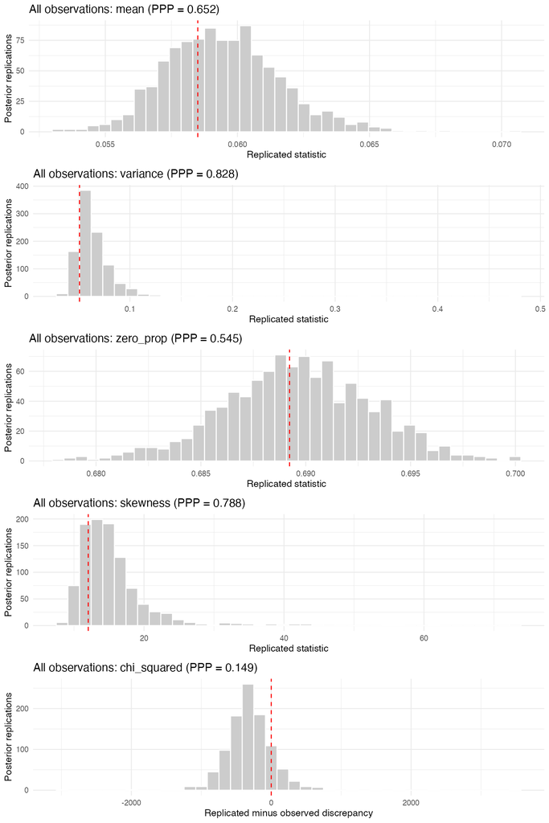

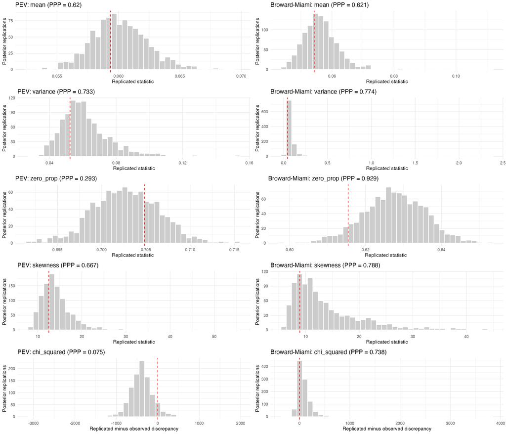

```r
plot_global_checks <- function(scope) {
  plots <- lapply(c("mean", "variance", "zero_prop", "skewness", "chi_squared"), function(stat) {
    d <- filter(global_check_draws, .data$scope == .env$scope, statistic == stat)
    stopifnot(nrow(d) == check_draw_count, all(d$scope == scope))
    ppp <- mean(d$replicated >= d$observed)
    # The chi discrepancy has a draw-specific observed value, so plot paired
    # differences with reference zero. Other panels retain the original style.
    chi <- stat == "chi_squared"
    d$plot_value <- if (chi) d$replicated - d$observed else d$replicated
    reference <- if (chi) 0 else d$observed[1]
    ggplot(d, aes(plot_value)) +
      geom_histogram(bins = 40, fill = "gray80", color = "white") +
      geom_vline(xintercept = reference, color = "red", linetype = "dashed") +
      labs(title = paste0(scope, ": ", stat, " (PPP = ", round(ppp, 3), ")"),
           x = if (chi) "Replicated minus observed discrepancy" else "Replicated statistic",
           y = "Posterior replications") + theme_minimal(base_size = 10)
  })
  cowplot::plot_grid(plotlist = plots, ncol = 1)
}
ggsave(output_file("ppc_global_density.png"), plot_global_checks("All observations"),
       width = 8, height = 12, dpi = 180, bg = "white")
ggsave(output_file("ppc_global_density_by_region.png"),
       cowplot::plot_grid(plot_global_checks("PEV"), plot_global_checks("Broward-Miami"), ncol = 2),
       width = 14, height = 12, dpi = 180, bg = "white")
knitr::include_graphics(c(output_file("ppc_global_density.png"),
                          output_file("ppc_global_density_by_region.png")))
```

#### 6.10.1.2 Grouped posterior predictive checks

These repeat the original four grouped statistics, including its separate skewness conventions (`moments` globally and `e1071`, type 3, within groups). All groups are saved, including all-zero groups. As in the original manuscript summary, the main tally includes groups with at least one observed colony. Undefined statistics are identified explicitly: skewness is undefined for a constant sample and standard deviation is undefined for a single observation. A PPP is left blank if its observed value or any replicated value is undefined, rather than assigning a value to those cases or silently dropping replications.

```r
group_results <- unlist(lapply(names(check_scopes), function(scope) {
  ix <- check_scopes[[scope]]
  groups <- split(ix, interaction(model_data$taxon[ix], model_data$class[ix],
                                  model_data$Type[ix], drop = TRUE))
  lapply(groups, function(j) {
    y <- observed_density[j]
    yrep <- replicated_density[, j, drop = FALSE]
    id <- data.frame(scope = scope, taxon = as.character(model_data$taxon[j[1]]),
                     class = as.character(model_data$class[j[1]]),
                     Type = as.character(model_data$Type[j[1]]))
    observed <- bind_cols(id, data.frame(observations = length(j),
      positive_sites = sum(y > 0), mean = mean(y), sd = sd(y),
      zero_prop = mean(y == 0), skewness = e1071::skewness(y, type = 3))) %>%
      pivot_longer(c(mean, sd, zero_prop, skewness), names_to = "statistic", values_to = "observed")
    replicated <- bind_cols(id[rep(1, nrow(yrep)), ], data.frame(
      draw = original_check_draws$draw_ids, mean = rowMeans(yrep),
      sd = apply(yrep, 1, sd), zero_prop = rowMeans(yrep == 0),
      skewness = apply(yrep, 1, e1071::skewness, type = 3))) %>%
      pivot_longer(c(mean, sd, zero_prop, skewness), names_to = "statistic", values_to = "replicated")
    list(observed = observed, replicated = replicated)
  })
}), recursive = FALSE)
group_observed <- bind_rows(lapply(group_results, `[[`, "observed"))
group_check_draws <- bind_rows(lapply(group_results, `[[`, "replicated")) %>%
  left_join(group_observed, by = c("scope", "taxon", "class", "Type", "statistic"))
grouped_checks <- group_check_draws %>%
  group_by(scope, taxon, class, Type, statistic, observations, positive_sites) %>%
  summarize(observed = first(observed), predictive_draws = n(),
            defined_replicates = sum(is.finite(replicated)),
            replicated_median = if (any(is.finite(replicated))) median(replicated[is.finite(replicated)]) else NA_real_,
            replicated_lower = if (any(is.finite(replicated))) quantile(replicated[is.finite(replicated)], 0.025) else NA_real_,
            replicated_upper = if (any(is.finite(replicated))) quantile(replicated[is.finite(replicated)], 0.975) else NA_real_,
            posterior_predictive_probability = if (is.finite(first(observed)) && all(is.finite(replicated)))
              mean(replicated >= first(observed)) else NA_real_, .groups = "drop") %>%
  mutate(in_original_style_tally = positive_sites > 0,
         defined = is.finite(posterior_predictive_probability),
         extreme = if_else(defined, posterior_predictive_probability < 0.05 |
                                      posterior_predictive_probability > 0.95, NA))
grouped_check_summary <- grouped_checks %>% filter(in_original_style_tally) %>%
  group_by(scope) %>%
  summarize(statistics = n(), defined_statistics = sum(defined),
            undefined_statistics = sum(!defined), extreme_statistics = sum(extreme, na.rm = TRUE),
            .groups = "drop")
write_csv(grouped_checks, output_file("posterior_predictive_grouped.csv"), na = "")
write_csv(grouped_check_summary, output_file("posterior_predictive_grouped_summary.csv"))
write_csv(filter(grouped_checks, in_original_style_tally, extreme),
          output_file("posterior_predictive_grouped_extreme.csv"))
show_table(grouped_check_summary, digits = 0)
```

| scope | statistics | defined_statistics | undefined_statistics | extreme_statistics |
| --- | --- | --- | --- | --- |
| All observations | 444 | 411 | 33 | 10 |
| Broward-Miami | 320 | 278 | 42 | 9 |
| PEV | 420 | 390 | 30 | 12 |

```r
show_table(filter(grouped_checks, in_original_style_tally, extreme) %>%
             select(scope, taxon, class, Type, statistic, posterior_predictive_probability))
```

| scope | taxon | class | Type | statistic | posterior_predictive_probability |
| --- | --- | --- | --- | --- | --- |
| All observations | AGAR | >4cm | Nearshore Ridge Complex | skewness | 0.039 |
| All observations | DSTO | >4cm | Middle Reef | sd | 0.030 |
| All observations | MCAV | >4cm | Middle Reef | skewness | 0.019 |
| All observations | MEAN | <4cm | Inner Reef | skewness | 0.033 |
| All observations | MMEA | >4cm | Outer Reef | sd | 0.000 |
| All observations | MMEA | >4cm | Outer Reef | skewness | 0.000 |
| All observations | ORBI | >4cm | Inner Reef | sd | 0.020 |
| All observations | SIDE | >4cm | Inner Reef | skewness | 0.045 |
| All observations | SIDE | >4cm | Middle Reef | skewness | 0.048 |
| All observations | SINT | <4cm | Nearshore Ridge Complex | skewness | 0.029 |
| Broward-Miami | DSTO | >4cm | Outer Reef | skewness | 0.957 |
| Broward-Miami | MCAV | >4cm | Outer Reef | zero_prop | 1.000 |
| Broward-Miami | ORBI | >4cm | Inner Reef | sd | 0.047 |
| Broward-Miami | PORI | >4cm | Middle Reef | skewness | 0.008 |
| Broward-Miami | SIDE | <4cm | Inner Reef | zero_prop | 1.000 |
| Broward-Miami | SIDE | <4cm | Nearshore Ridge Complex | zero_prop | 1.000 |
| Broward-Miami | SIDE | >4cm | Inner Reef | zero_prop | 1.000 |
| Broward-Miami | SIDE | >4cm | Outer Reef | zero_prop | 1.000 |
| Broward-Miami | SINT | >4cm | Middle Reef | zero_prop | 1.000 |
| PEV | AGAR | >4cm | Nearshore Ridge Complex | skewness | 0.028 |
| PEV | DSTO | >4cm | Middle Reef | sd | 0.029 |
| PEV | MCAV | >4cm | Middle Reef | skewness | 0.018 |
| PEV | MEAN | <4cm | Inner Reef | skewness | 0.014 |
| PEV | MMEA | >4cm | Outer Reef | sd | 0.000 |
| PEV | MMEA | >4cm | Outer Reef | skewness | 0.000 |
| PEV | ORBI | >4cm | Inner Reef | sd | 0.034 |
| PEV | SIDE | >4cm | Inner Reef | skewness | 0.010 |
| PEV | SIDE | >4cm | Middle Reef | skewness | 0.030 |
| PEV | SINT | <4cm | Nearshore Ridge Complex | skewness | 0.027 |
| PEV | SINT | >4cm | Inner Reef | skewness | 0.979 |
| PEV | SINT | >4cm | Middle Reef | skewness | 0.982 |

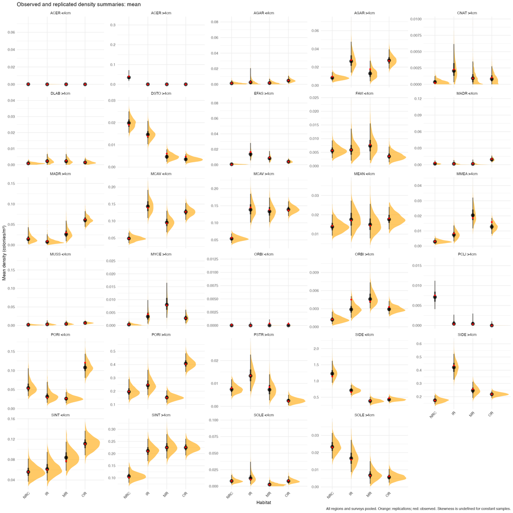

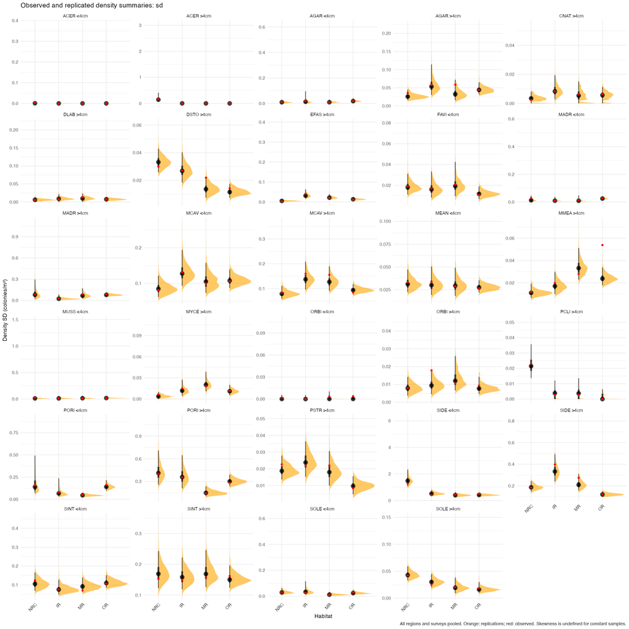

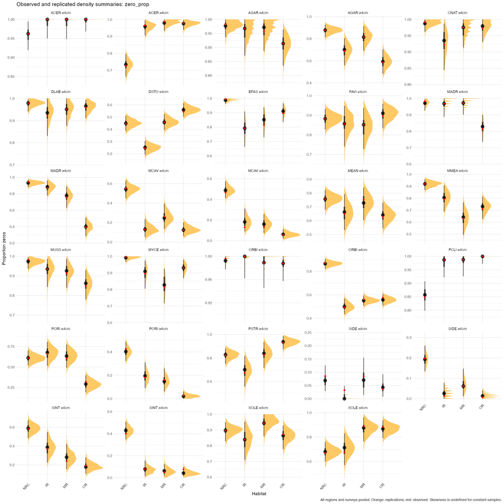

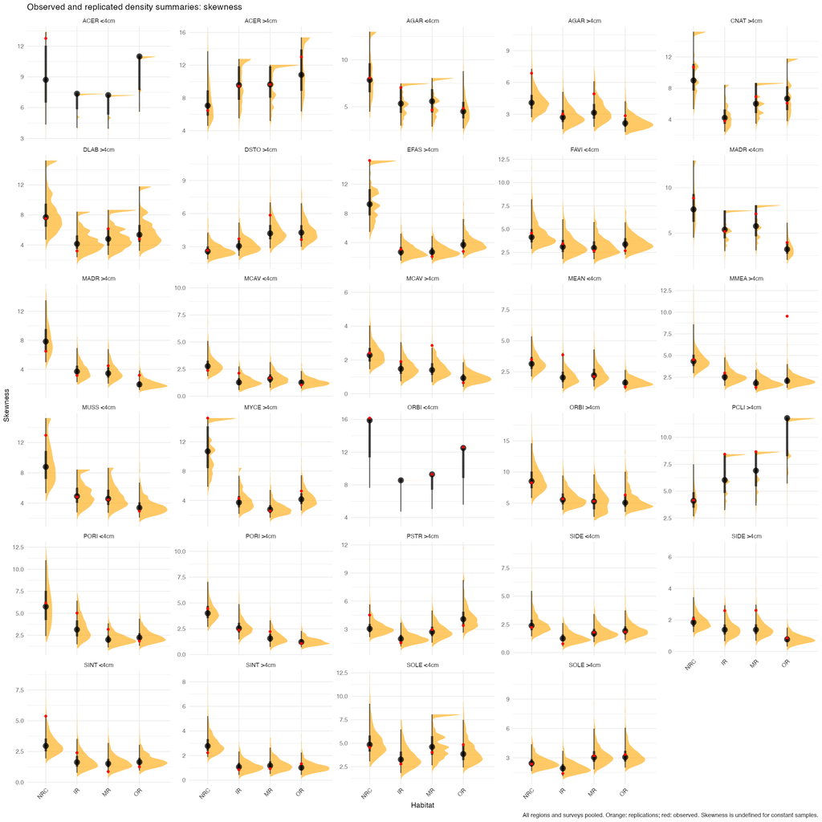

```r
# Reproduce the four original pooled, faceted diagnostic plots and save them.
check_habitat_labels <- c("Nearshore Ridge Complex" = "NRC", "Inner Reef" = "IR",
                          "Middle Reef" = "MR", "Outer Reef" = "OR")
check_statistic_labels <- c(mean = "Mean density (colonies/m²)",
                            sd = "Density SD (colonies/m²)",
                            zero_prop = "Proportion zeros", skewness = "Skewness")
for (stat in c("mean", "sd", "zero_prop", "skewness")) {
  d <- group_check_draws %>%
    filter(scope == "All observations", statistic == stat, is.finite(replicated)) %>%
    mutate(Type = factor(Type, levels = names(check_habitat_labels)),
           taxon_class = paste(taxon, class))
  observed <- group_observed %>%
    filter(scope == "All observations", statistic == stat, is.finite(observed)) %>%
    mutate(Type = factor(Type, levels = names(check_habitat_labels)),
           taxon_class = paste(taxon, class))
  p <- ggplot(d, aes(Type, replicated)) +
    tidybayes::stat_halfeye(fill = "orange", alpha = 0.6, .width = c(0.5, 0.95),
                           normalize = "panels") +
    geom_point(data = observed, aes(y = observed), color = "red", size = 1) +
    facet_wrap(~ taxon_class, scales = "free_y", ncol = 5) +
    scale_x_discrete(labels = check_habitat_labels, drop = FALSE) +
    labs(x = "Habitat", y = check_statistic_labels[[stat]],
         title = paste("Observed and replicated density summaries:", stat),
         caption = "All regions and surveys pooled. Orange: replications; red: observed. Skewness is undefined for constant samples.") +
    theme_minimal(base_size = 9) + theme(axis.text.x = element_text(angle = 45, hjust = 1))
  ggsave(output_file(paste0("ppc_grouped_", stat, ".png")), p,
         width = 14, height = 14, dpi = 180, bg = "white")
}
knitr::include_graphics(vapply(c("mean", "sd", "zero_prop", "skewness"),
  function(stat) output_file(paste0("ppc_grouped_", stat, ".png")), character(1)))
```

#### 6.10.1.3 Fit-check definitions and validation

PPP is the fraction of replications whose statistic is at least as large as its observed counterpart. The diagnostic flag repeats the original thresholds PPP <0.05 or >0.95; it is not a significance test or a multiplicity-adjusted p-value. The grouped tally reports the number of defined statistics explicitly. A discrete statistic can have a PPP of one because of ties (for example, when the observed zero proportion is zero); inspect the predictive distribution rather than treating the flag alone as evidence of poor fit. A successful predictive check does not establish sampler convergence.

```r
# Independently verify native count-scale R² on the selected posterior draws.
check_r2 <- vapply(seq_len(check_draw_count), function(i) {
  mu <- original_check_draws$expected_counts[i, ]
  var(mu) / (var(mu) + var(model_data$n - mu))
}, numeric(1))
r2_error <- max(abs(check_r2 - original_check_draws$r2[original_check_draws$draw_ids]))
# The chi-squared PPP must use paired differences, not the posterior mean mu.
chi_checks <- global_check_draws %>% filter(statistic == "chi_squared") %>%
  group_by(scope) %>% summarize(ppp = mean(replicated - observed >= 0), .groups = "drop") %>%
  left_join(filter(global_checks, statistic == "chi_squared"), by = "scope")
check_validation <- data.frame(
  check = c("Native count-scale R-squared matches independently calculated residual-variance R-squared",
            "Observed and replicated chi-squared discrepancies are paired by posterior draw",
            "Global probabilities lie in [0,1] and use all selected replications",
            "Regional observation subsets partition the fitted data",
            "Undefined grouped statistics are not assigned diagnostic probabilities",
            "All scientific posterior draws are retained"),
  pass = c(r2_error < 1e-10,
           max(abs(chi_checks$ppp - chi_checks$posterior_predictive_probability)) < 1e-12,
           all(is.finite(global_checks$posterior_predictive_probability) &
                 global_checks$posterior_predictive_probability >= 0 &
                 global_checks$posterior_predictive_probability <= 1 &
                 global_checks$predictive_draws == check_draw_count),
           identical(sort(c(check_scopes$PEV, check_scopes$`Broward-Miami`)),
                     check_scopes$`All observations`),
           all(is.na(grouped_checks$posterior_predictive_probability[!grouped_checks$defined])),
           length(original_check_draws$r2) == posterior::ndraws(joint_fit))
)
write_csv(check_validation, output_file("original_framework_check_validation.csv"))
stopifnot(all(check_validation$pass))
write_csv(data.frame(
  setting = c("fit_hash", "r2_response_scale", "r2_posterior_draws", "ppc_response_scale", "ppc_draws",
              "ppc_random_effects", "global_skewness", "grouped_skewness", "chi_squared",
              "grouped_tally", "undefined_statistics"),
  value = c(fit_hash, "Colony counts", length(original_check_draws$r2), "Colonies/m2", check_draw_count,
            "All fitted effects, at each observation's actual region, dataset, direction and searched area",
            "moments::skewness", "e1071::skewness(type=3)",
            "Sum((density-expected_density)^2/expected_density), paired by posterior draw",
            "Observed-positive groups; flag PPP <0.05 or >0.95",
            "PPP left blank if observed or any replicated statistic is undefined")
), output_file("original_framework_check_method.csv"))
show_table(check_validation)
```

| check | pass |
| --- | --- |
| Native count-scale R-squared matches independently calculated residual-variance R-squared | TRUE |
| Observed and replicated chi-squared discrepancies are paired by posterior draw | TRUE |
| Global probabilities lie in [0,1] and use all selected replications | TRUE |
| Regional observation subsets partition the fitted data | TRUE |
| Undefined grouped statistics are not assigned diagnostic probabilities | TRUE |
| All scientific posterior draws are retained | TRUE |

```r
# Keep the compact summaries; release large predictive matrices before figures.
rm(original_check_draws, replicated_density, expected_density, group_results,
   group_check_draws, group_observed, global_check_draws)
```

### 6.10.2 Chain energy and mixing checks

Energy exploration and trace plots supplement R-hat and effective sample size. An E-BFMI below 0.3 is a flag for review, rather than evidence that a larger iteration count alone will solve the problem. These diagnostics follow [Stan’s guidance](https://mc-stan.org/learn-stan/diagnostics-warnings.html).

```r
sampler_health_draws <- rstan::get_sampler_params(joint_fit$fit, inc_warmup = FALSE)
sampler_health <- bind_rows(lapply(seq_along(sampler_health_draws), function(chain) {
  x <- sampler_health_draws[[chain]]
  data.frame(chain = chain, sampling_iterations = nrow(x),
    ebfmi = mean(diff(x[, "energy__"])^2) / var(x[, "energy__"]),
    mean_acceptance = mean(x[, "accept_stat__"]),
    mean_leapfrog_steps = mean(x[, "n_leapfrog__"]),
    divergences = sum(x[, "divergent__"]),
    treedepth_hits = sum(x[, "treedepth__"] >= max_treedepth))
}))
write_csv(sampler_health, output_file("sampler_health_by_chain.csv"))
show_table(sampler_health, digits = 3)
```

| chain | sampling_iterations | ebfmi | mean_acceptance | mean_leapfrog_steps | divergences | treedepth_hits |
| --- | --- | --- | --- | --- | --- | --- |
| 1 | 1000 | 0.800 | 0.963 | 255 | 0 | 0 |
| 2 | 1000 | 0.962 | 0.943 | 255 | 0 | 0 |
| 3 | 1000 | 0.818 | 0.949 | 255 | 0 | 0 |
| 4 | 1000 | 1.050 | 0.960 | 255 | 0 | 0 |

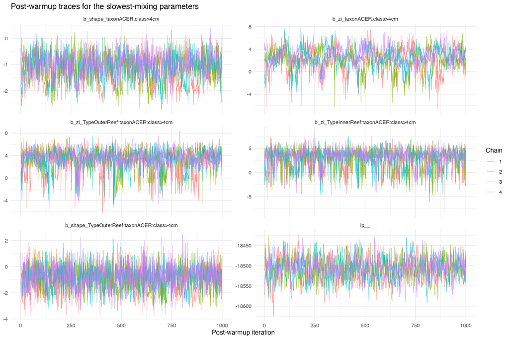

```r
# Show the five slowest-mixing parameters and the joint log posterior.
trace_parameters <- read_csv(output_file("parameter_diagnostics.csv"), show_col_types = FALSE) %>%
  filter(variable != "lp__") %>% slice_head(n = 5) %>% pull(variable)
trace_parameters <- c(trace_parameters, "lp__")
trace_array <- posterior::as_draws_array(joint_fit)[, , trace_parameters, drop = FALSE]
trace_data <- as_tibble(posterior::as_draws_df(trace_array)) %>%
  select(.chain, .iteration, all_of(trace_parameters)) %>%
  pivot_longer(all_of(trace_parameters), names_to = "parameter", values_to = "value") %>%
  mutate(parameter = factor(parameter, levels = trace_parameters), chain = factor(.chain))
trace_plot <- ggplot(trace_data, aes(.iteration, value, color = chain)) +
  geom_line(linewidth = .25, alpha = .75) +
  facet_wrap(~parameter, scales = "free_y", ncol = 2) + theme_minimal() +
  labs(x = "Post-warmup iteration", y = NULL, color = "Chain",
       title = "Post-warmup traces for the slowest-mixing parameters")
ggsave(output_file("sampler_trace_review.png"), trace_plot,
       width = 12, height = 8, dpi = 180, bg = "white")
knitr::include_graphics(output_file("sampler_trace_review.png"))
```

**This fit does not pass every sampling criterion; manuscript figures and tables below remain provisional.**

Posterior saved at: `/Users/rosscunning/Projects/PENIP/outputs/coral_analysis/models/db9da5156777a9344ac26acd2b9ce2ac/brms_fit.rds`. Rerunning matching inputs reuses it.

## 6.11 Final PEV density estimates

```r
# Equal weighting datasets

# Create newdata for prediction — dataset level only (site & dir not needed)
newdata <- dfftaxon %>%
  distinct(dataset, taxon, class, Type) %>%
  mutate(transect_area_m2 = 1)

# Get predictions from the model
# - Dataset RE included
# - Direction effects set to zero on the log scale
preds <- joint_epred_draws(newdata = newdata, region = "PEV")

# Equal-weight datasets so no dataset dominates
draws_equal_weighted <- preds %>%
  group_by(.draw, taxon, class, Type) %>%
  summarize(n_m2 = mean(.epred), .groups = "drop")

# Summarize posterior draws
summary_equal_weighted_new <- draws_equal_weighted %>%
  group_by(taxon, class, Type) %>%
  mean_qi(n_m2, .width = 0.95)


draws_equal_weighted_combined <- preds %>%
  group_by(.draw, taxon, dataset, Type, class) %>%
  summarize(n_m2 = mean(.epred), .groups = "drop") %>%

  # Average across datasets for each class
  group_by(.draw, taxon, class, Type) %>%
  summarize(n_m2 = mean(n_m2), .groups = "drop") %>%

  # Compute "All" after averaging across datasets
  group_by(.draw, taxon, Type) %>%
  mutate(total_n_m2 = sum(n_m2[class != "All"])) %>%
  ungroup() %>%
  pivot_longer(
    cols = c("n_m2", "total_n_m2"),
    names_to = "class_source",
    values_to = "n_m2"
  ) %>%
  mutate(class = ifelse(class_source == "total_n_m2", "All", class)) %>%
  select(-class_source) %>%

  # Remove redundant "All" for single-class taxa
  group_by(taxon) %>%
  mutate(n_classes = n_distinct(class[class != "All"])) %>%
  ungroup() %>%
  filter(class != "All" | n_classes > 1) %>%
  select(-n_classes)



summary_equal_weighted_combined <- draws_equal_weighted_combined %>%
  group_by(taxon, class, Type) %>%
  mean_qi(n_m2, .width = 0.95)


# Set taxon order for plotting
# Order taxa by overall abundance for plotting
taxorder <- summary_equal_weighted_combined %>%
  group_by(taxon) %>%
  mutate(
    n_classes = n_distinct(class[class != "All"])
  ) %>%
  ungroup() %>%
  filter((n_classes > 1 & class == "All") | (n_classes == 1 & class != "All")) %>%
  group_by(taxon) %>%
  summarize(maxdens = max(n_m2), .groups = "drop") %>%
  mutate(taxon = fct_reorder(taxon, -maxdens))

summary_equal_weighted_combined <- summary_equal_weighted_combined %>%
  mutate(taxon = factor(taxon, levels = levels(taxorder$taxon)),
         class = factor(class, levels = c("<4cm", "All", ">4cm")))
```

#### 6.11.0.1 2024-specific estimates

```r
newdata_drm24 <- dfftaxon %>%
  distinct(taxon, class, Type) %>%
  mutate(transect_area_m2 = 1)  %>%
  complete(Type = unique(dfftaxon$Type),  # add all habitat Types
           fill = list(transect_area_m2 = 1)) %>%
  mutate(dataset = "drm24")

preds_drm24 <- joint_epred_draws(newdata = newdata_drm24, region = "PEV")

summary_drm24 <- preds_drm24 %>%
  group_by(taxon, class, Type) %>%
  mean_qi(.epred, .width = 0.95) %>%
  rename(n_m2 = .epred)

draws_drm24_combined <- preds_drm24 %>%
  group_by(.draw, taxon, class, Type) %>%
  summarize(n_m2 = mean(.epred), .groups = "drop") %>%

  # Compute "All" class
  group_by(.draw, taxon, Type) %>%
  mutate(total_n_m2 = sum(n_m2[class != "All"])) %>%
  ungroup() %>%
  pivot_longer(
    cols = c("n_m2", "total_n_m2"),
    names_to = "class_source",
    values_to = "n_m2"
  ) %>%
  mutate(class = ifelse(class_source == "total_n_m2", "All", class)) %>%
  select(-class_source) %>%

  # Remove redundant "All" for single-class taxa
  group_by(taxon) %>%
  mutate(n_classes = n_distinct(class[class != "All"])) %>%
  ungroup() %>%
  filter(class != "All" | n_classes > 1) %>%
  select(-n_classes)

summary_drm24_combined <- draws_drm24_combined %>%
  group_by(taxon, class, Type) %>%
  mean_qi(n_m2, .width = 0.95)


summary_drm24_combined <- summary_drm24_combined %>%
  mutate(taxon = factor(taxon, levels = levels(taxorder$taxon)),
         class = factor(class, levels = c("<4cm", "All", ">4cm")))
```

# 7 Results

## 7.1 Densities

### 7.1.1 Taxon densities

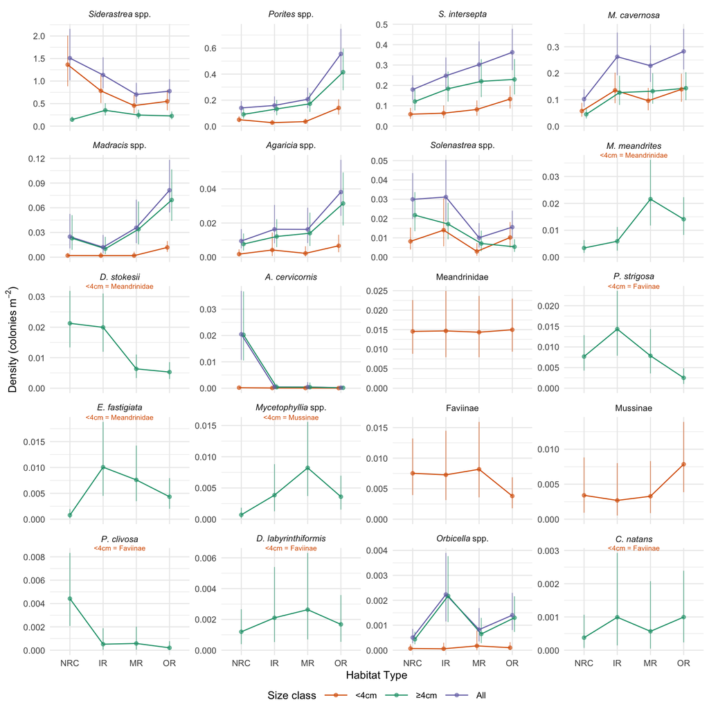

```r
##### Function to plot densities of all taxon:class:habitat combinations with provided data frame

make_taxon_density_plot <- function(densities, output_path, width, height) {

  # Create base plot
  taxdens <- ggplot(densities, aes(x = Type, y = n_m2, color = class)) +
    geom_errorbar(aes(ymin = .lower, ymax = .upper), width = 0, linewidth = 0.4,
                  position = position_dodge(width = 0.2), alpha = 0.6) +
    geom_line(aes(group = class), position = position_dodge(width = 0.2)) +
    geom_point(size = 1.5, alpha = 0.6, position = position_dodge(width = 0.2)) +
    facet_wrap(~taxon, labeller = labeller(taxon = as_labeller(taxon_labels, label_parsed)),
               scales = "free_y", ncol = 4) +
    scale_x_discrete(labels = type_labels) +
    scale_color_manual(
      values = c("<4cm" = "#d95f02", ">4cm" = "#1b9e77", "All" = "#7570b3"),
      labels = c("<4cm", "≥4cm", "All"),
      breaks = c("<4cm", ">4cm", "All")
    ) +
    labs(
      x = "Habitat Type",
      y = bquote("Density (colonies m"^-2*")"),
      color = "Size class"
    ) +
    theme_minimal()

  # Generate taxon group annotations
  taxon_group_df <- bind_rows(lapply(names(taxon_groups_juv), function(group) {
    tibble(taxon = taxon_groups_juv[[group]], group = group)
  })) %>%
    filter(taxon != group)

  annotation_df <- densities %>%
    distinct(taxon) %>%
    left_join(taxon_group_df, by = "taxon") %>%
    filter(!is.na(group)) %>%
    mutate(
      group2 = case_when(
        group == "FAVI" ~ "Faviinae",
        group == "MUSS" ~ "Mussinae",
        group == "MEAN" ~ "Meandrinidae",
        TRUE ~ group
      ),
      taxon = factor(taxon, levels = taxorder$taxon),
      label = paste0("<4cm = ", group2),
      x = 2.5,
      y = Inf
    )

  # Final figure with annotations
  fig <- taxdens +
    geom_text(data = annotation_df, aes(x = x, y = y, label = label),
              inherit.aes = FALSE, hjust = 0.5, size = 2.5, color = "#d95f02") +
    theme(
      panel.background = element_rect(fill = "white", color = NA),
      plot.background = element_rect(fill = "white", color = NA),
      legend.position = "bottom",
      legend.key.width = unit(2, "lines"),
      legend.margin = margin(t = -5, b = 0)
    ) +
    coord_cartesian(clip = "off") +
    scale_y_continuous(limits = c(0, NA))

  # Save and return the plot
  save_figure(filename = output_path, plot = fig,
         width = width, height = height,
         units = "mm", dpi = 300)
  return(fig)
}


# Create plot for dataset-averaged densities
make_taxon_density_plot(densities = summary_equal_weighted_combined,
                        output_path = output_file("Fig2.png"),
                        width = 170, height = 170)
```

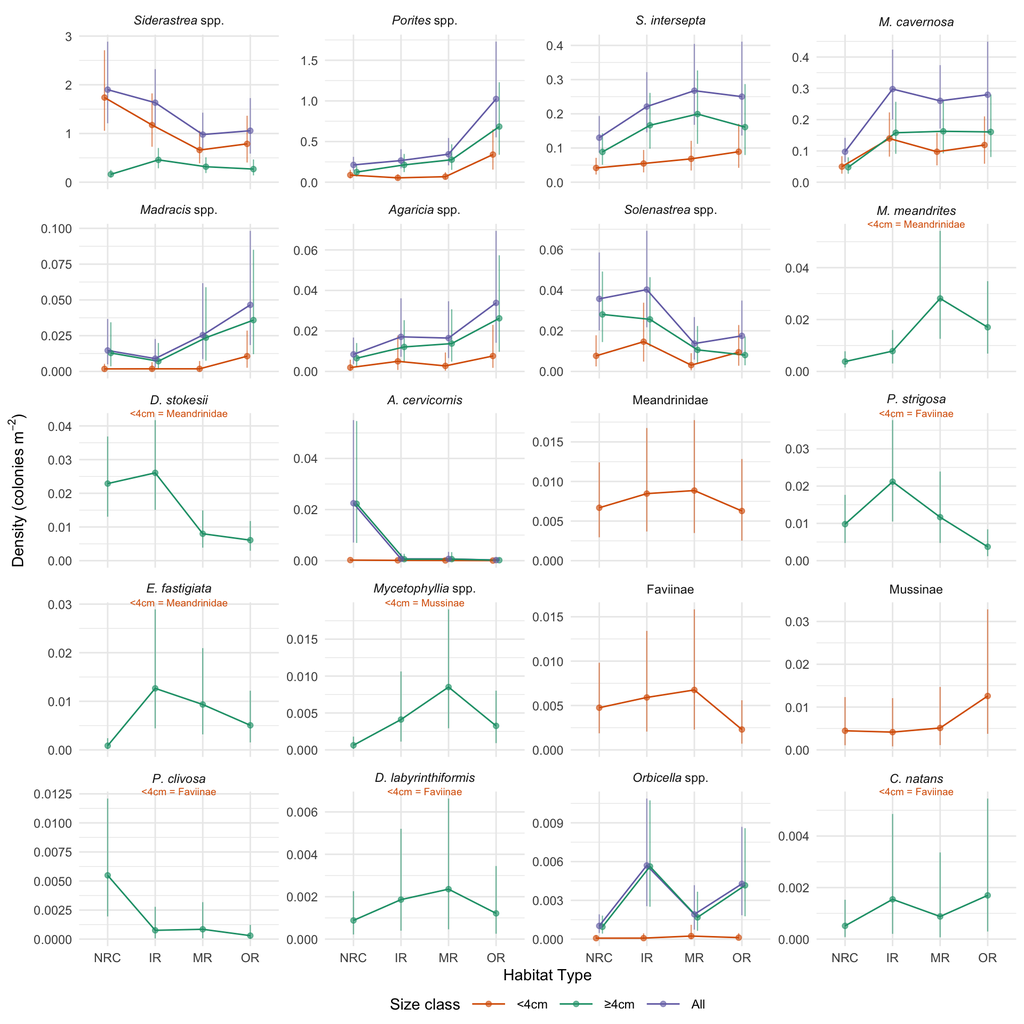

```r
# Create plot for current/2024 densities
make_taxon_density_plot(densities = summary_drm24_combined,
                        output_path = output_file("FigA2.png"),
                        width = 170, height = 170)
```

```r
#### TABLE version

make_taxon_density_table <- function(densities, output_path) {

  # Set display order
  type_order <- unique(densities$Type)  # preserves appearance order
  class_order <- c("<4cm", ">4cm", "All")
  taxon_levels <- taxorder$taxon  # assumed available

  # Format and reshape
  table_out <- densities %>%
    mutate(
      taxon = factor(taxon, levels = taxon_levels),
      class = factor(class, levels = class_order),
      Type = factor(Type, levels = type_order),
      mean_ci = sprintf(
        "%s [%s–%s]",  # en-dash
        formatC(n_m2, format = "fg", digits = 2, flag = "#"),
        formatC(.lower, format = "fg", digits = 2, flag = "#"),
        formatC(.upper, format = "fg", digits = 2, flag = "#")
      )
    ) %>%
    select(taxon, class, Type, mean_ci) %>%
    pivot_wider(names_from = Type, values_from = mean_ci) %>%
    arrange(taxon, class)

  # Save to CSV
  write_csv(table_out, file = output_path)

  return(table_out)
}

# Create table for dataset-averaged densities
make_taxon_density_table(densities = summary_equal_weighted_combined,
                         output_path = output_file("TableA2.csv"))
```

```
## # A tibble: 38 × 6
##    taxon class `Nearshore Ridge Complex` `Inner Reef` `Middle Reef` `Outer Reef`
##    <fct> <fct> <chr>                     <chr>        <chr>         <chr>
##  1 ACER  <4cm  0.00020 [0.000054–0.0005… 0.000078 [0… 0.000057 [0.… 0.000030 [0…
##  2 ACER  >4cm  0.020 [0.011–0.037]       0.00038 [0.… 0.00038 [0.0… 0.00014 [0.…
##  3 ACER  All   0.020 [0.011–0.037]       0.00046 [0.… 0.00044 [0.0… 0.00017 [0.…
##  4 AGAR  <4cm  0.0018 [0.00046–0.0046]   0.0042 [0.0… 0.0022 [0.00… 0.0067 [0.0…
##  5 AGAR  >4cm  0.0077 [0.0039–0.014]     0.012 [0.00… 0.014 [0.006… 0.031 [0.01…
##  6 AGAR  All   0.0095 [0.0052–0.016]     0.016 [0.00… 0.016 [0.008… 0.038 [0.02…
##  7 CNAT  >4cm  0.00038 [0.000071–0.0011] 0.00099 [0.… 0.00057 [0.0… 0.0010 [0.0…
##  8 DLAB  >4cm  0.0012 [0.00039–0.0027]   0.0021 [0.0… 0.0026 [0.00… 0.0017 [0.0…
##  9 DSTO  >4cm  0.021 [0.013–0.032]       0.020 [0.01… 0.0063 [0.00… 0.0053 [0.0…
## 10 EFAS  >4cm  0.00078 [0.00017–0.0020]  0.010 [0.00… 0.0076 [0.00… 0.0043 [0.0…
## # ℹ 28 more rows
```

```r
# Create table for current/2024 densities
make_taxon_density_table(densities = summary_drm24_combined,
                         output_path = output_file("TableA3.csv"))
```

```
## # A tibble: 38 × 6
##    taxon class `Nearshore Ridge Complex` `Inner Reef` `Middle Reef` `Outer Reef`
##    <fct> <fct> <chr>                     <chr>        <chr>         <chr>
##  1 ACER  <4cm  0.00022 [0.000035–0.0007… 0.00013 [0.… 0.000087 [0.… 0.000039 [0…
##  2 ACER  >4cm  0.022 [0.0069–0.055]      0.00058 [0.… 0.00060 [0.0… 0.00018 [0.…
##  3 ACER  All   0.022 [0.0071–0.055]      0.00070 [0.… 0.00069 [0.0… 0.00022 [0.…
##  4 AGAR  <4cm  0.0019 [0.00033–0.0058]   0.0050 [0.0… 0.0027 [0.00… 0.0076 [0.0…
##  5 AGAR  >4cm  0.0065 [0.0025–0.014]     0.012 [0.00… 0.014 [0.004… 0.026 [0.00…
##  6 AGAR  All   0.0084 [0.0037–0.017]     0.017 [0.00… 0.016 [0.006… 0.034 [0.01…
##  7 CNAT  >4cm  0.00051 [0.000082–0.0015] 0.0015 [0.0… 0.00088 [0.0… 0.0017 [0.0…
##  8 DLAB  >4cm  0.00088 [0.00022–0.0023]  0.0019 [0.0… 0.0024 [0.00… 0.0012 [0.0…
##  9 DSTO  >4cm  0.023 [0.013–0.037]       0.026 [0.01… 0.0080 [0.00… 0.0061 [0.0…
## 10 EFAS  >4cm  0.00086 [0.00016–0.0024]  0.013 [0.00… 0.0093 [0.00… 0.0051 [0.0…
## # ℹ 28 more rows
```

### 7.1.2 Raw vs. modeled taxon densities

```r
# Average density per dataset-taxon-class-Type group
raw_density_summary <- pev_raw_counts %>%
  mutate(density = n / transect_area_m2) %>%
  group_by(dataset, taxon, class, Type) %>%
  summarize(
    raw_density_mean = mean(density, na.rm = TRUE),
    raw_density_sd   = sd(density, na.rm = TRUE),
    raw_density_n    = n(),
    .groups = "drop"
  ) %>%
  mutate(
    raw_density_se = raw_density_sd / sqrt(raw_density_n),
    t_crit = qt(0.975, df = raw_density_n - 1),
    raw_density_lower = pmax(0, raw_density_mean - t_crit * raw_density_se),
    raw_density_upper = raw_density_mean + t_crit * raw_density_se
  )

all <- raw_density_summary %>%
  left_join(summary_equal_weighted_combined, by = c("taxon", "class", "Type")) %>%
  # Joining raw character labels to modeled factors can lose the habitat order.
  mutate(Type = factor(Type, levels = type_levels),
         taxon_class = paste(taxon, class))

all_long <- all %>%
  select(dataset, taxon, class, Type, raw_density_mean, raw_density_lower, raw_density_upper,
         n_m2, .lower, .upper, taxon_class) %>%
  pivot_longer(
    cols = c(raw_density_mean, n_m2),
    names_to = "source",
    values_to = "density"
  ) %>%
  mutate(
    lower = ifelse(source == "raw_density_mean", raw_density_lower, .lower),
    upper = ifelse(source == "raw_density_mean", raw_density_upper, .upper),
    source = ifelse(source == "raw_density_mean", dataset, "modeled")
  )

raw_vs_mod <- ggplot(all_long, aes(x = Type, y = density)) +
  geom_point(
    aes(shape = source, color = source),
    size = 2,
    position = position_dodge(width = 0.75),
    alpha = 0.5
  ) +
  geom_errorbar(
    aes(ymin = lower, ymax = upper, color = source),
    position = position_dodge(width = 0.75),
    width = 0,
    alpha = 0.5
  ) +
  facet_wrap(~ taxon_class, scales = "free", ncol = 5) +
  scale_y_continuous(limits = c(0, NA), expand = expansion(mult = c(0, 0))) +
  coord_cartesian(clip = "off") +
  scale_x_discrete(limits = type_levels, labels = type_labels, drop = FALSE) +
  scale_color_manual(
    name = "",
    values = c(
      "nsu11_esa" = "#1b9e77",
      "dca17_esa" = "#d95f02",
      "dca17"     = "#7570b3",
      "tt21"      = "#e7298a",
      "tt23"      = "#66a61e",
      "drm24"     = "#e6ab02",
      "modeled"   = "black"
    ),
    breaks = c("nsu11_esa", "dca17_esa", "dca17", "tt21", "tt23", "drm24", "modeled"),
    labels = c(
      "nsu11_esa" = "2011 – NSU ESA Survey",
      "dca17_esa" = "2017 – DCA ESA Survey",
      "dca17"     = "2017 – DCA Recon Survey",
      "tt21"      = "2021 – Tetra Tech Survey",
      "tt23"      = "2023 – Tetra Tech Survey",
      "drm24"     = "2024 – Shedd Survey",
      "modeled"   = "Modeled density"
    )
  ) +
  scale_shape_manual(
    name = "",
    values = c(
      "nsu11_esa" = 15,
      "dca17_esa" = 16,
      "dca17"     = 17,
      "tt21"      = 18,
      "tt23"      = 3,
      "drm24"     = 4,
      "modeled"   = 5
    ),
    breaks = c("nsu11_esa", "dca17_esa", "dca17", "tt21", "tt23", "drm24", "modeled"),
    labels = c(
      "nsu11_esa" = "2011 – NSU ESA Survey",
      "dca17_esa" = "2017 – DCA ESA Survey",
      "dca17"     = "2017 – DCA Recon Survey",
      "tt21"      = "2021 – Tetra Tech Survey",
      "tt23"      = "2023 – Tetra Tech Survey",
      "drm24"     = "2024 – Shedd Survey",
      "modeled"   = "Modeled density"
    )
  ) +
  guides(
    color = guide_legend(order = 1),
    shape = guide_legend(order = 1)
  )


figA1 <- raw_vs_mod + theme_minimal() +
  theme_minimal() +
  theme(
    legend.position = "bottom",
    panel.background = element_rect(fill = "white", color = NA),
    plot.background = element_rect(fill = "white", color = NA),
    panel.grid = element_blank(),
    panel.border = element_rect(color = "black", fill = NA, linewidth = 0.2),
    axis.ticks = element_line(color = "black", linewidth = 0.2),
    axis.ticks.length = unit(2, "pt"),
    axis.line = element_blank() # keep ticks but don't draw duplicate axis lines
  )

save_figure(filename = output_file("FigA1.png"), plot = figA1,
            width = 190, height = 250, units = "mm")
```

### 7.1.3 Total densities by size and SCTLD-susceptibility

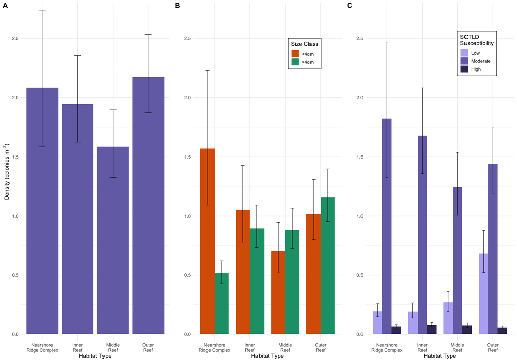

```r
make_combined_density_figure <- function(draws, table = FALSE,
                                         output_path,
                                         y_limits = c(0, 2.8)) {
  draws <- draws %>% filter(class != "All")
  type_order <- unique(draws$Type)
  y_breaks <- seq(y_limits[1], y_limits[2] - 0.3, 0.5)
  y_minor_breaks <- seq(y_limits[1], y_limits[2] - 0.05, 0.25)

  # -- Total density summary --
  summary_total <- draws %>%
    group_by(.draw, Type) %>%
    summarize(total_density = sum(n_m2), .groups = "drop") %>%
    group_by(Type) %>%
    summarize(
      mean = mean(total_density),
      lower = quantile(total_density, 0.025),
      upper = quantile(total_density, 0.975),
      .groups = "drop"
    )

  plot_total <- ggplot(summary_total, aes(x = Type, y = mean)) +
    geom_col(fill = "#7570b3") +
    geom_errorbar(aes(ymin = lower, ymax = upper), width = 0.2, linewidth = 0.25) +
    scale_x_discrete(labels = type_labels2) +
    scale_y_continuous(
      limits = y_limits,
      breaks = y_breaks,
      minor_breaks = y_minor_breaks,
      expand = expansion(mult = c(0.02, 0))
    ) +
    labs(
      x = "Habitat Type",
      y = bquote("Density (colonies m"^-2*")")
    ) +
    theme_minimal(base_size = 8) +
    theme(
      axis.text.x = element_text(angle = 0, hjust = 0.5),
      panel.background = element_rect(fill = "white", color = NA),
      plot.background = element_rect(fill = "white", color = NA)
    )

  # -- Size class summary --
  summary_class <- draws %>%
    group_by(.draw, Type, class) %>%
    summarize(total_epred = sum(n_m2), .groups = "drop") %>%
    group_by(Type, class) %>%
    mean_qi(total_epred, .width = 0.95) %>%
    mutate(
      class = factor(class, levels = c("<4cm", ">4cm")),
      label = sprintf("%.2f", total_epred)
    )

  plot_class <- ggplot(summary_class, aes(x = Type, y = total_epred, fill = class)) +
    geom_col(position = position_dodge(width = 0.8), width = 0.8) +
    geom_errorbar(aes(ymin = .lower, ymax = .upper),
                  position = position_dodge(width = 0.8), width = 0.2, linewidth = 0.25) +
    scale_fill_manual(values = c(">4cm" = "#1b9e77", "<4cm" = "#d95f02")) +
    scale_x_discrete(labels = type_labels2) +
    scale_y_continuous(
      limits = y_limits,
      breaks = y_breaks,
      minor_breaks = y_minor_breaks,
      expand = expansion(mult = c(0.02, 0))
    ) +
    labs(
      x = "Habitat Type",
      y = "",
      fill = "Size Class"
    ) +
    theme_minimal(base_size = 8) +
    theme(
      axis.text.x = element_text(angle = 0, hjust = 0.5),
      legend.key.size = unit(4, "mm"),
      legend.background = element_rect(fill = "white", color = "black", linewidth = 0.25),
      legend.position = c(0.75, 0.85),
      panel.background = element_rect(fill = "white", color = NA),
      plot.background = element_rect(fill = "white", color = NA)
    )

  # -- SCTLD susceptibility summary --
  summary_sus <- draws %>%
    left_join(group_definitions, by = "taxon") %>%
    group_by(.draw, Type, sus_group) %>%
    summarize(total_epred = sum(n_m2), .groups = "drop") %>%
    group_by(Type, sus_group) %>%
    mean_qi(total_epred, .width = 0.95) %>%
    mutate(
      taxon_group = factor(sus_group, levels = c("high_sus", "mod_sus", "low_sus")),
      label = sprintf("%.2f", total_epred)
    )

  plot_sus <- ggplot(summary_sus, aes(x = Type, y = total_epred, fill = sus_group)) +
    geom_col(position = position_dodge(width = 0.8), width = 0.8) +
    geom_errorbar(aes(ymin = .lower, ymax = .upper),
                  position = position_dodge(width = 0.8), width = 0.2, linewidth = 0.25) +
    scale_fill_manual(
      values = c(
        "high_sus" = darken("#7570b3", 0.5),
        "mod_sus"  = "#7570b3",
        "low_sus"  = lighten("#7570b3", 0.5)
      ),
      labels = c(
        "high_sus" = "High",
        "mod_sus"  = "Moderate",
        "low_sus"  = "Low"
      )
    ) +
    scale_x_discrete(labels = type_labels2) +
    scale_y_continuous(
      limits = y_limits,
      breaks = y_breaks,
      minor_breaks = y_minor_breaks,
      expand = expansion(mult = c(0.02, 0))
    ) +
    labs(
      x = "Habitat Type",
      y = "",
      fill = "SCTLD\nSusceptibility"
    ) +
    theme_minimal(base_size = 8) +
    theme(
      axis.text.x = element_text(angle = 0, hjust = 0.5),
      legend.key.size = unit(4, "mm"),
      legend.background = element_rect(fill = "white", color = "black", linewidth = 0.25),
      legend.position = c(0.75, 0.85),
      panel.background = element_rect(fill = "white", color = NA),
      plot.background = element_rect(fill = "white", color = NA)
    )

  # -- Combine all panels --
  combined_plot <- cowplot::plot_grid(
    plot_total, plot_class, plot_sus,
    ncol = 3,
    labels = c("A", "B", "C"),
    label_size = 10,
    align = "hv"
  )

  if (table == FALSE) {
    save_figure(filename = output_path, plot = combined_plot, width = 180, height = 80, units = "mm", dpi = 300)
    return(combined_plot)
  } else {
    return(list(summary_sus, summary_class, summary_total))
  }
}

make_combined_density_figure(draws = draws_equal_weighted,
                             output_path = output_file("Fig3.png"))
```

```r
make_combined_density_figure(draws = draws_equal_weighted, table = TRUE)
```

```
## [[1]]
## # A tibble: 12 × 10
##    Type  sus_group total_epred .lower .upper .width .point .interval taxon_group
##    <fct> <fct>           <dbl>  <dbl>  <dbl>  <dbl> <chr>  <chr>     <fct>
##  1 Near… low_sus        0.196  0.149  0.256    0.95 mean   qi        low_sus
##  2 Near… mod_sus        1.82   1.32   2.47     0.95 mean   qi        mod_sus
##  3 Near… high_sus       0.0646 0.0514 0.0803   0.95 mean   qi        high_sus
##  4 Inne… low_sus        0.192  0.138  0.262    0.95 mean   qi        low_sus
##  5 Inne… mod_sus        1.68   1.36   2.08     0.95 mean   qi        mod_sus
##  6 Inne… high_sus       0.0785 0.0614 0.0994   0.95 mean   qi        high_sus
##  7 Midd… low_sus        0.268  0.194  0.361    0.95 mean   qi        low_sus
##  8 Midd… mod_sus        1.24   1.01   1.54     0.95 mean   qi        mod_sus
##  9 Midd… high_sus       0.0730 0.0555 0.0948   0.95 mean   qi        high_sus
## 10 Oute… low_sus        0.678  0.522  0.876    0.95 mean   qi        low_sus
## 11 Oute… mod_sus        1.44   1.19   1.74     0.95 mean   qi        mod_sus
## 12 Oute… high_sus       0.0558 0.0444 0.0692   0.95 mean   qi        high_sus
## # ℹ 1 more variable: label <chr>
##
## [[2]]
## # A tibble: 8 × 9
##   Type             class total_epred .lower .upper .width .point .interval label
##   <fct>            <fct>       <dbl>  <dbl>  <dbl>  <dbl> <chr>  <chr>     <chr>
## 1 Nearshore Ridge… <4cm        1.57   1.09   2.23    0.95 mean   qi        1.57
## 2 Nearshore Ridge… >4cm        0.515  0.425  0.621   0.95 mean   qi        0.51
## 3 Inner Reef       <4cm        1.05   0.778  1.43    0.95 mean   qi        1.05
## 4 Inner Reef       >4cm        0.894  0.731  1.09    0.95 mean   qi        0.89
## 5 Middle Reef      <4cm        0.702  0.518  0.945   0.95 mean   qi        0.70
## 6 Middle Reef      >4cm        0.882  0.724  1.07    0.95 mean   qi        0.88
## 7 Outer Reef       <4cm        1.02   0.799  1.31    0.95 mean   qi        1.02
## 8 Outer Reef       >4cm        1.15   0.952  1.40    0.95 mean   qi        1.15
##
## [[3]]
## # A tibble: 4 × 4
##   Type                     mean lower upper
##   <fct>                   <dbl> <dbl> <dbl>
## 1 Nearshore Ridge Complex  2.08  1.58  2.74
## 2 Inner Reef               1.95  1.62  2.36
## 3 Middle Reef              1.58  1.32  1.90
## 4 Outer Reef               2.17  1.87  2.53
```

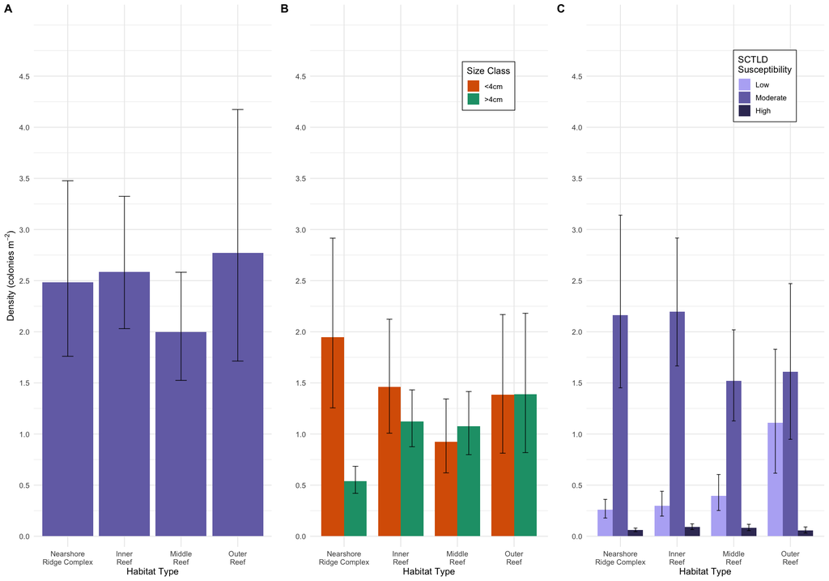

```r
make_combined_density_figure(draws = draws_drm24_combined,
                             y_limits = c(0, 5.2),
                             output_path = output_file("FigA3.png"))
```

```r
# Overall PEV densities: sum taxa within habitat, then give habitats equal weight.
# Available sources are still equally averaged within each habitat cell.
summarize_pev_overall_density <- function(draws, prediction_target, own_area = FALSE) {
  habitat_totals <- draws %>% filter(class != "All") %>%
    group_by(.draw, Type, class) %>%
    summarise(total_epred = sum(n_m2), .groups = "drop") %>%
    mutate(habitat_weight = if (own_area) habitat_area_weights(Type, "PEV") else 1/4)
  coverage <- habitat_totals %>% group_by(.draw, class) %>%
    summarise(total_weight = sum(habitat_weight), habitats = n(), .groups = "drop")
  stopifnot(all(coverage$habitats == 4L), all(abs(coverage$total_weight - 1) < 1e-12))
  by_class <- habitat_totals %>% group_by(.draw, class) %>%
    summarise(avg_total_epred = sum(total_epred * habitat_weight), .groups = "drop")
  combined <- by_class %>% group_by(.draw) %>%
    summarise(avg_total_epred = sum(avg_total_epred), .groups = "drop") %>% mutate(class = "All")
  bind_rows(by_class, combined) %>% group_by(class) %>%
    summarise(mean = mean(avg_total_epred), sd_post = sd(avg_total_epred),
      lower = quantile(avg_total_epred, 0.025), upper = quantile(avg_total_epred, 0.975),
      n_draws = n(), .groups = "drop") %>%
    mutate(prediction_target, region = "PEV", habitat_weighting = if (own_area)
      "PEV mapped reef-habitat area proportions (sensitivity)" else "Equal weights: NRC, IR, MR, OR (primary)")
}
post_summ <- summarize_pev_overall_density(draws_equal_weighted, "Survey-averaged")
pev_overall_density <- bind_rows(post_summ,
  summarize_pev_overall_density(draws_drm24_combined, "2024"))
write_csv(pev_overall_density, output_file("PEV_overall_equal_habitat_densities.csv"))
write_csv(bind_rows(
  summarize_pev_overall_density(draws_equal_weighted, "Survey-averaged", own_area = TRUE),
  summarize_pev_overall_density(draws_drm24_combined, "2024", own_area = TRUE)),
  output_file("PEV_overall_area_weighted_densities.csv"))
post_summ
```

```
## # A tibble: 3 × 9
##   class  mean sd_post lower upper n_draws prediction_target region
##   <chr> <dbl>   <dbl> <dbl> <dbl>   <int> <chr>             <chr>
## 1 <4cm  1.09   0.0994 0.912 1.31     4000 Survey-averaged   PEV
## 2 >4cm  0.861  0.0445 0.780 0.953    4000 Survey-averaged   PEV
## 3 All   1.95   0.110  1.75  2.18     4000 Survey-averaged   PEV
## # ℹ 1 more variable: habitat_weighting <chr>
```